# 息子の身長、まだ伸ばせます！

小学生高学年男子の母親のための身長最大化ガイド

2025年

# はじめに：「もっと早く知りたかった」と後悔しないために

## クラスで前から3番目のわが子を見て感じる不安

学校の身体測定の結果を見て、胸がぎゅっと締め付けられたこと、ありませんか？

「クラスで前から3番目」

運動会の整列で、わが子だけがひときわ小さく見える。体育の授業で、周りの子に押されて転びそうになる姿。「ちび」と呼ばれて悔しそうに俯く顔。

「うちの子、大丈夫だろうか」 「もっと背が伸びてくれたら」 「このまま大人になったら、きっと苦労するのでは」

母親として、そんな不安を抱えるのは、決してあなただけではありません。

でも、同時にこんな疑問も湧いてきませんか？

「遺伝だから仕方がない？」 「今さら何かできるの？」 「成長ホルモン治療って聞いたことはあるけど、うちの子に関係あるの？」

**この本は、そんなあなたのための本です。**

## なぜ「小学生高学年」が最後のチャンスなのか

実は、お子さんの身長を伸ばすために親ができることには、**明確なタイムリミット**があります。

それは「骨端線が閉じるまで」です。

骨端線（こったんせん）――聞きなれない言葉かもしれません。これは、骨の端にある「成長する部分」のことです。この骨端線が開いている間だけ、身長は伸びます。そして、骨端線が閉じてしまったら、**1ミリも伸びることはありません**。

男の子の場合、骨端線が閉じるのは平均で17～19歳ごろ。「じゃあまだ時間がある」と思われるかもしれませんね。

でも、ここに大きな落とし穴があります。

**思春期が始まると、身長が急激に伸びる一方で、骨端線が閉じるスピードも加速するのです。**

思春期のスパートで年間10～12センチ伸びる時期は確かにあります。でも、そのスパートが終わると同時に、成長は止まります。

そして、**思春期の開始時期が早ければ早いほど、最終身長は低くなる**という研究結果があります。

なぜか？

思春期が早く始まると、成長のスパートも早く終わるからです。つまり、「伸びる期間」が短くなってしまうのです。

だからこそ、小学生高学年――10歳、11歳、12歳――の**今この瞬間**が、とても重要なのです。

思春期が本格化する前の、この時期にこそ、できることがあります。

逆に言えば、**この時期を逃すと、取り返しがつかないこともある**のです。

## あなたが抱えている3つの疑問

私はこれまで、あなたと同じように悩む多くのお母様方とお話ししてきました。そして、皆さんが抱えている疑問は、大きく分けて3つに集約されることが分かりました。

### 疑問1：「遺伝だから諦めるしかない？」

**答え：いいえ、諦める必要はありません。**

確かに、身長の60～80%は遺伝で決まります。でも、逆に言えば、**20～40%は環境要因で変わる**ということです。

両親の身長から計算される「予測身長」には、±9センチ（男子の場合）もの幅があります。この9センチの差が、どこから生まれるのか。

それは、**睡眠、栄養、運動、ストレス管理、そして必要に応じた医学的介入**です。

「たかが5センチ」と思われるでしょうか？

いいえ、この5センチが、お子さんの自信を変え、人生の選択肢を広げることもあるのです。

### 疑問2：「今から何をすればいいの？」

**答え：科学的根拠に基づいた、今日からできることがあります。**

この本では、小児内分泌学会や国際的な研究で実証されている方法だけを紹介します。

根拠のない「身長を伸ばすサプリ」や「ぶら下がり健康器」のような怪しい方法は一切ありません。

**本当に効果があると科学的に証明されている方法**だけを、具体的に、分かりやすく、今日から実践できる形でお伝えします。

### 疑問3：「成長ホルモン治療って、うちの子に関係ある？」

**答え：関係があるかもしれませんし、ないかもしれません。でも、知っておくべきです。**

成長ホルモン治療には、大きく分けて2つのルートがあります。

1つは**保険診療**。成長ホルモンが著しく不足している場合など、厳しい条件をクリアすれば、月数千円程度の負担で治療を受けられます。

もう1つは**自由診療（自費）**。保険の条件は満たさないけれど、低身長で悩んでいる場合に受けられる治療です。ただし、年間100万～200万円以上という高額な費用がかかります。

「うちの子はどちらに当てはまるの？」 「そもそも治療が必要なの？」 「費用に見合う効果はあるの？」 「リスクは？」

こうした疑問に、この本では徹底的に答えます。

**ただし、誤解しないでください。**

この本は「成長ホルモン治療を受けましょう」という本ではありません。

むしろ、**生活習慣の改善が最も重要で、最もコストがかからず、最も効果的**だということを、まずお伝えします。

成長ホルモン治療は、あくまで選択肢の1つ。そして、その選択をするにしても、しないにしても、**エビデンス（科学的根拠）に基づいた正しい判断**をしていただくことが、この本の目的です。

## この本で分かる3つのこと

この本を読むことで、あなたは以下の3つを明確に理解できます。

### 1. わが子の身長が「あとどれだけ伸びるか」の科学的予測

- 遺伝からの予測式を使った具体的な計算方法
- 成長曲線の正しい見方
- 骨年齢検査で分かること
- 「まだ間に合う」のか、「急ぐべき」なのかの判断基準

**これを知ることで**：漠然とした不安が、具体的な見通しに変わります。

### 2. 今日からできる、科学的に正しい身長最大化の方法

この本の第2部では、**睡眠・栄養・運動**という3つの柱を徹底的に解説します。

**睡眠**：

- なぜ睡眠が最重要なのか
- 小学生高学年男子に必要な睡眠時間（具体的な数値）
- 就寝時刻から逆算する生活設計
- 質の高い睡眠のための5つの絶対ルール
- 「うちの子、寝てくれない」パターン別解決法

**運動**：

- 効果的な運動ランキング（第1位は縄跳び！）
- 縄跳び完全マスタープログラム
- 部活動との付き合い方
- 「やりすぎ」の危険サイン

**これを知ることで**：明日から、具体的に何をすればいいかが明確になります。

### 3. 成長ホルモン治療の現実（費用・効果・リスク）

第4部では、成長ホルモン治療について、**メリットだけでなくデメリットも含めて、客観的に**お伝えします。

- 保険診療と自由診療の違い
- 期待できる効果（平均+3.5～7.5センチ、治療期間4～7年）
- 費用の現実（年間100万～200万円以上、総額400万～1400万円以上）
- リスクと副作用（稀だが重篤なものもある）
- 週1回製剤vs毎日製剤の選択
- クリニックの選び方
- 「やる」「やらない」を決めるための意思決定フレームワーク

**これを知ることで**：もし治療を検討することになっても、「こんなはずじゃなかった」という後悔を避けられます。

## 本書の使い方：第2部から読んでも大丈夫です

この本は、以下のように構成されています。

**第1部：基礎知識編**（第1章）

- 身長が伸びる仕組みと限界

**第2部：今日からできる身長を伸ばす3つの柱**（第2章～第4章）

- 睡眠
- 栄養
- 運動

**第3部：身長を奪う3つの敵を排除する**（第5章～第7章）

- 肥満
- 思春期早発
- ストレス

**第4部：医学的介入という選択肢**（第8章～第11章）

- 成長ホルモン治療の基礎知識
- 自由診療の現実
- クリニックの選び方
- 決断のためのフレームワーク

**第5部：実践編**（第12章～第14章）

- 最初の1週間から3ヶ月までの具体的プログラム

**第6部：Q&Aとケーススタディ**（第15章～第16章）

- 母親の20の疑問に答えます
- 5人の母親の実践レポート

### おすすめの読み方

**パターン1：「まず行動したい」あなたへ** → **第2部（第2章～第4章）から読んでください。**

睡眠・栄養・運動の具体的な方法がすぐに分かります。基礎知識は後からでも大丈夫です。

**パターン2：「全体像を理解してから行動したい」あなたへ** → 最初から順番に読んでください。

**パターン3：「成長ホルモン治療に関心がある」あなたへ** → 第1部を読んだ後、**第4部（第8章～第11章）**へ進んでください。

ただし、治療を検討する前に、必ず**第2部の生活習慣の改善を実践**することをお勧めします。

## 母親の皆さんへ：あなたは一人じゃない

お子さんの身長のことで悩み、夜も眠れない日があるかもしれません。

周りの子がどんどん大きくなっていくのを見て、焦りを感じているかもしれません。

「もっと早く気づいてあげれば」と自分を責めているかもしれません。

でも、知ってください。

**今、この本を手に取ったあなたは、すでに一歩を踏み出しています。**

「もっと早く知りたかった」と後悔しないために、今日から始められることがあります。

お子さんの身長は、確かに人生の一要素です。でも、それがすべてではありません。

**何より大切なのは、お子さんが心身ともに健康で、自分に自信を持って成長すること。**

そして、母親であるあなたが、「できることはやった」と胸を張って言えること。

この本が、あなたとお子さんの、そんな未来への道しるべとなることを心から願っています。

さあ、一緒に始めましょう。

**この本の特徴**

✓ 科学的根拠（エビデンス）に基づいた情報のみ ✓ 専門用語を避けた分かりやすい説明 ✓ 今日からできる具体的なアクションプラン ✓ 実際の母親たちの実践レポート ✓ チェックリスト、献立表、記録シートなど実用ツール満載

**この本を読んでほしい人**

- 小学生高学年（10～12歳）の男の子の母親
- わが子の身長が気になっている方
- 成長ホルモン治療について知りたい方
- 科学的に正しい方法で子どもの成長をサポートしたい方
- 「もっと早く知りたかった」と後悔したくない方

それでは、次のページから、お子さんの身長を最大限に伸ばすための旅を始めましょう。

# 第1章：身長が伸びる仕組みと限界

「うちの子、本当にまだ伸びるの？」

この章では、その疑問に科学的に答えます。身長が伸びる仕組みを理解することで、「何をすれば効果があるのか」「いつまでに何をすべきか」が明確になります。

難しい医学用語は使いません。お母さんが、お子さんに説明できるくらい分かりやすくお伝えします。

## 1-1. 骨端線が開いている間だけ伸びる

### 身長が伸びる「本当の理由」

「身長が伸びる」とは、具体的に何が起こっているのでしょうか？

筋肉が伸びる？ いいえ、違います。 背骨が伸びる？ 半分正解ですが、それだけではありません。

**答えは「骨が伸びる」です。**

より正確に言えば、**手足の長い骨（大腿骨、脛骨、上腕骨など）が縦方向に伸びる**ことが、身長の伸びの大部分を占めます。

### 骨端線とは何か

では、骨はどうやって伸びるのでしょうか？

ここで登場するのが「骨端線（こったんせん）」です。

骨端線は、骨の両端近くにある「成長軟骨帯」と呼ばれる部分のことです。この部分には、まだ硬い骨になっていない「軟骨」があります。

この軟骨の細胞が、**成長ホルモン**や**IGF-1**という物質の働きで増殖し、次第に硬い骨に置き換わっていきます。

この繰り返しで、骨が少しずつ長くなり、身長が伸びるのです。

### イラストで理解する骨端線

言葉だけでは分かりにくいので、イラストで説明しましょう。

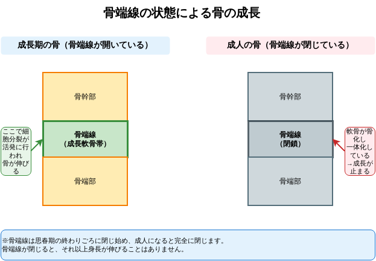

図1-1：骨端線の構造

骨端線がある限り、骨は伸び続けます。 **でも、骨端線が閉じたら、そこで成長は完全にストップします。**

### 男子の骨端線はいつ閉じるのか

では、骨端線はいつまで開いているのでしょうか？

**男子の場合：平均17～19歳で閉鎖**

ただし、これには個人差があります。

- 早い子：15～16歳で閉じることも
- 遅い子：20歳過ぎても少し開いていることも

**重要なのは、「思春期の進行」と密接に関係している**ということです。

思春期が始まると、性ホルモン（男子ならテストステロン）が増えます。このホルモンが骨端線を徐々に閉じさせていくのです。

つまり、**思春期が早く始まれば、骨端線も早く閉じる** → **最終身長は低くなりやすい**

これが、「小学生高学年が最後のチャンス」である理由の1つです。

### 閉じたら1mmも伸びない現実

「骨端線が閉じた後も、少しくらい伸びるんじゃないの？」

残念ながら、**ノーです。**

骨端線が完全に閉じると、軟骨がなくなり、骨の端が硬い骨で完全に結合します。この状態になると、**1ミリも伸びることはありません。**

これは科学的に証明されている事実です。

だからこそ、「まだ伸びる時期」に何をするかが、決定的に重要なのです。

## 1-2. 成長ホルモンとIGF-1の役割

### 成長ホルモンがどこで作られ、何をするのか

身長を伸ばす主役、それが**成長ホルモン（GH：Growth Hormone）**です。

成長ホルモンは、脳の下にある小さな器官「下垂体（かすいたい）」から分泌されます。

特に**睡眠中、それも深い眠りの時**に大量に分泌されることが分かっています。

「寝る子は育つ」という言葉は、科学的に正しかったのです。

### 成長ホルモンの働き

成長ホルモンは、血液に乗って全身を巡り、様々な働きをします。

主な働きは以下の3つ：

1. **骨の成長を促進**（身長を伸ばす）
2. **筋肉を作る**（タンパク質合成）
3. **脂肪を分解する**（エネルギー源として利用）

この中で、私たちが最も注目するのは、もちろん「骨の成長」です。

### IGF-1が骨を伸ばす実行部隊

でも、実は成長ホルモン自体が直接骨を伸ばすわけではありません。

成長ホルモンは、主に肝臓で**IGF-1（インスリン様成長因子-1）**という物質を作らせます。

そして、このIGF-1こそが、**骨端線の軟骨細胞に働きかけ、細胞を増やし、骨を伸ばす実行部隊**なのです。

つまり、流れはこうです：

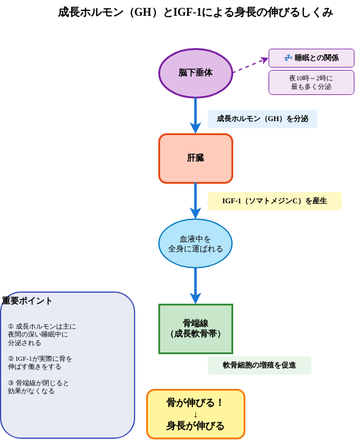

図1-2：成長ホルモンとIGF-1のメカニズム

### この2つを最大化することが身長を伸ばす鍵

ここで重要なポイント：

**成長ホルモンとIGF-1の分泌を最大化できれば、遺伝的に決まっている身長の上限まで伸ばせる**

では、どうすれば最大化できるのか？

**答え：**

- **睡眠**（成長ホルモンの分泌）
- **栄養**（IGF-1の産生に必要な材料、特にタンパク質と亜鉛）
- **運動**（成長ホルモンの分泌促進、骨への刺激）

これが、この本の第2部で詳しく解説する「3つの柱」です。

逆に、睡眠不足、栄養不足、運動不足があると、せっかく遺伝的に高くなれる可能性があっても、それを実現できないまま骨端線が閉じてしまいます。

**これが、「環境要因で2～5センチ変わる」の正体です。**

## 1-3. 男の子の成長パターン

### 3つの成長期

男の子の身長の伸びは、一定ではありません。大きく分けて3つの時期があります。

- **年間の伸び**：1歳まで約25cm、1～2歳で約10cm、2～3歳で約8cm
- 人生で最も身長が伸びる時期
- この時期の成長は主に「栄養」に依存

#### 第3期：思春期スパート（10～15歳ごろ）

- **年間の伸び**：ピーク時で10～12cm
- 急激に身長が伸びる「第二次性徴期」
- 声変わり、体毛の発生、筋肉の発達なども同時に起こる

そして、スパートが終わると、急速に成長が鈍化し、骨端線が閉じます。

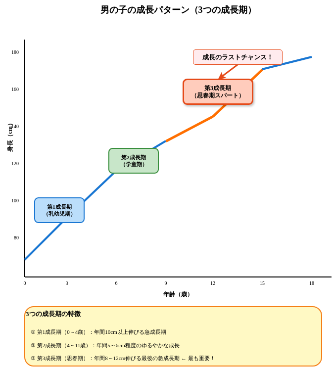

図1-3：男子の成長パターン（0～18歳）

### 10～12歳：年間5～6cm（成長スパート前）

お子さんが今10～12歳なら、まだ「安定成長期」から「思春期スパート前」の段階にいる可能性が高いです。

この時期の**標準的な伸び**は、年間5～6センチです。

もしお子さんが年間4センチ未満しか伸びていない場合、それは「何かが足りていない」サインかもしれません。

逆に、年間8～10センチ以上伸びている場合、それは「思春期が早く始まっている」サインかもしれません（これについては第6章で詳しく解説します）。

### 13～15歳：年間10～12cm（成長スパート）

思春期が本格化すると、年間10～12センチという驚異的なペースで伸びます。

「やった！ぐんぐん伸びてる！」と喜びたくなりますが、ここに落とし穴があります。

**スパートが早く来ると、早く終わる。**

例えば：

- Aくん：11歳でスパート開始 → 13歳で終了 → 最終身長165cm
- Bくん：13歳でスパート開始 → 15歳で終了 → 最終身長172cm

同じように伸びても、開始時期が2年違うだけで、最終身長に7センチもの差が出ることがあります。

### 思春期開始のタイミングで最終身長が変わる

ここが最も重要なポイントです：

**思春期の開始が1年遅れるごとに、最終身長が約5センチ高くなる**

これは複数の研究で確認されている事実です。

なぜか？

思春期が遅く始まれば、その分「安定成長期」が長くなるからです。年間5～6センチずつ、1年多く伸びられるのです。

逆に、思春期が早く始まると：

- 短期間で急激に伸びる
- でも、骨端線が早く閉じる
- 結果、最終身長は低くなる

**だからこそ、思春期が本格化する前の「今」が、最も重要な時期なのです。**

## 1-4. わが子の最終身長を予測する

「うちの子、最終的にどれくらいの身長になるんだろう？」

この疑問に、ある程度答えることができます。完璧な予測は不可能ですが、科学的な方法で「おおよその範囲」を知ることができます。

### 遺伝からの予測式：(父の身長+母の身長+13)÷2 ±9cm

最もシンプルな方法が、両親の身長から計算する予測式です。

**男子の予測身長 = (父の身長 + 母の身長 + 13) ÷ 2**

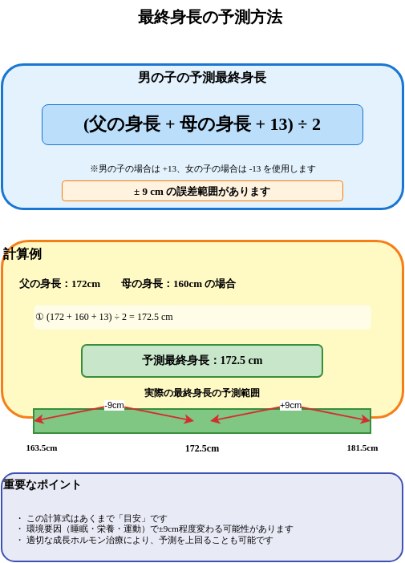

図1-4：身長予測の計算方法

例えば：

- 父の身長：170cm
- 母の身長：158cm
- 予測身長 = (170 + 158 + 13) ÷ 2 = **170.5cm**

ただし、これはあくまで「平均値」です。実際には、**±9cm**の幅があります。

つまり、上の例だと：

- **最低：161.5cm**
- **平均：170.5cm**
- **最高：179.5cm**

**18センチもの幅**があるのです。

では、この幅のどこに落ち着くかを決めるのは何でしょうか？

それが、**環境要因（睡眠、栄養、運動、ストレス、肥満の有無など）**なのです。

### 成長曲線で現在の位置を確認

予測式だけでは不十分です。「今、どの位置にいるか」を知ることも重要です。

そのために使うのが**成長曲線**です。

成長曲線は、年齢ごとの標準的な身長の範囲を示したグラフです。母子手帳にも載っていますね。

#### 成長曲線の見方

成長曲線には、いくつかの線（パーセンタイル曲線）が引かれています。

- **+2SD（標準偏差）**：上位2.5%（非常に高い）
- **+1SD**：上位16%
- **0SD（中央値）**：真ん中
- **-1SD**：下位16%
- **-2SD**：下位2.5%（低身長の目安）

お子さんの身長をプロットして、どの線の近くにいるかを見ます。

**重要なのは、「線と平行に伸びているか」です。**

例えば：

- ずっと-1SDのラインに沿って伸びている → 問題なし（その子のペース）
- -1SDから-2SDへ下がってきている → **要注意**（成長が鈍化している）

後者の場合、何か原因（睡眠不足、栄養不足、病気など）があるかもしれません。

### 骨年齢検査でより正確に予測

さらに正確に予測したい場合、**骨年齢検査**という方法があります。

これは、手のレントゲン写真を撮って、骨の成熟度を調べる検査です。

骨端線がどれくらい閉じかかっているかを見ることで、「あとどれくらい伸びる余地があるか」を推定できます。

例えば：

- 実年齢：12歳
- 骨年齢：10歳 → まだ伸びる余地が大きい（良い兆候）
- 骨年齢：14歳 → 伸びる余地が少ない（思春期が早い）

**骨年齢検査は、小児内分泌専門医のいる病院で受けられます。**

費用は保険適用で数千円程度です。

### 「まだ間に合う」かを判断する方法

以下のチェックリストで、「まだ間に合うか」を判断してください。

#### 「まだ十分に間に合う」サイン

- 年齢が12歳以下
- 声変わりがまだ
- 陰毛がまだ、またはわずか
- 骨年齢が実年齢より1歳以上若い
- 年間5～6cm以上伸びている

#### 「急いだほうがいい」サイン

- 年齢が13歳以上
- 声変わりが始まっている
- 陰毛がしっかり生えている
- 骨年齢が実年齢より1歳以上進んでいる
- 年間の伸びが4cm未満

後者のサインが多い場合、**今すぐ行動を開始すべき**です。

特に、第2章の「睡眠」は、今夜から変えられます。

## 1-5. 遺伝60～80% vs 環境20～40%の意味

### 両親が低身長でも諦める必要はない

「うちは両親とも背が低いから、子どもも無理だよね」

そう諦めていませんか？

確かに、身長の60～80%は遺伝で決まります。でも、それは「諦める理由」ではなく、「希望の余地がある証拠」です。

なぜなら、**20～40%は環境で変えられる**からです。

[figure not shown]

図1-5：身長に影響する遺伝と環境の割合

### 環境を最適化すれば+2～5cmは可能

「環境要因で2～5センチ」と聞いて、「たった2～5センチ？」と思われるかもしれません。

でも、考えてみてください。

- 予測身長165cmの子が、168cmになる
- 予測身長170cmの子が、173cmになる

この3～5センチの差が、お子さんの人生にどれだけの影響を与えるか。

**自信が変わります。** **選択肢が広がります。** **コンプレックスが軽減されます。**

例えば、ある職業には身長制限があります：

- 警察官：男子160cm以上（多くの都道府県）
- 消防士：男子160cm以上
- 自衛隊（航空学生）：男子158cm以上

「5センチの差」が、夢を叶えられるかどうかを左右することもあるのです。

### その+5cmが人生を変えることもある

実際の例をご紹介しましょう。

**ケース：太郎くん（仮名）**

母親は、「遺伝だから仕方ない」と半ば諦めていました。

でも、この本で紹介する方法を実践しました：

- 就寝時刻を21時に固定（以前は22時30分）
- 朝食に卵と納豆を追加（タンパク質強化）
- 毎日縄跳び10分

1年後：

- 身長：143cm（+8cm伸びた！）
- クラスで真ん中の位置に

2年後（中学1年生）：

- 身長：152cm
- サッカー部でレギュラーに

太郎くんは、今ではサッカーを通じて自信を持ち、明るく積極的な性格になりました。

母親は言います： 「あのとき諦めなくて、本当に良かった。5センチの差が、息子の人生を変えたと思います」

### 遺伝は「天井」ではなく「可能性の範囲」

ここで理解していただきたいのは、遺伝は「絶対的な天井」ではないということです。

遺伝が決めるのは、**「この範囲に収まる可能性が高い」という幅**です。

例えば、予測身長170cm ±9cmなら：

- 最低161cm
- 最高179cm

この18センチの幅の中で、どこに落ち着くかは、**環境次第**なのです。

### 諦めずに、今日からできることを始めよう

「遺伝だから」と諦めるのは、**161cmになる可能性を自ら選んでいる**ことと同じです。

逆に、**科学的に正しい方法で環境を整えれば、179cmに近づけるかもしれない**のです。

もちろん、179cmを保証することはできません。でも、**何もしないよりは確実に良い結果**が得られます。

「もっと早く知りたかった」と後悔しないために、今日から始めましょう。

次の章では、最も重要な「睡眠」について、具体的に解説します。

## 第1章のまとめ

1. **身長は骨端線が開いている間だけ伸びる**
   - 男子は平均17～19歳で閉鎖
   - 思春期が早いと閉鎖も早い
2. **成長ホルモンとIGF-1が身長を伸ばす主役**
   - 成長ホルモンは睡眠中に分泌
   - この2つを最大化することが鍵
3. **思春期のタイミングが最終身長を左右する**
   - 思春期が1年遅れると最終身長+約5cm
   - 小学生高学年が最後のチャンス
4. **予測身長には±9cmの幅がある**
   - この幅を決めるのが環境要因
   - 睡眠、栄養、運動
5. **遺伝60～80%、環境20～40%**
   - 環境の最適化で+2～5cm可能

# 第2章：睡眠 - 最も重要で、最もコストがかからない方法

「寝る子は育つ」

この古いことわざを、あなたは信じていますか？

実は、これは単なる言い伝えではありません。**科学的に完全に証明されている事実**なのです。

この章では、なぜ睡眠が身長を伸ばすために最も重要なのか、そして具体的に何をすればいいのかを、徹底的にお伝えします。

**今夜から変えられることがあります。** **費用は一切かかりません。** **でも、効果は絶大です。**

## 2-1. なぜ睡眠が最重要なのか

### 成長ホルモンの70～80%は深睡眠時に分泌

第1章で学んだように、身長を伸ばす主役は「成長ホルモン（GH）」と「IGF-1」です。

では、成長ホルモンはいつ、最も多く分泌されるのでしょうか？

**答え：深い睡眠の時、特に入眠後最初の1～3時間**

研究によれば、1日に分泌される成長ホルモンの**70～80%**が、この深い睡眠中に集中的に分泌されることが分かっています。

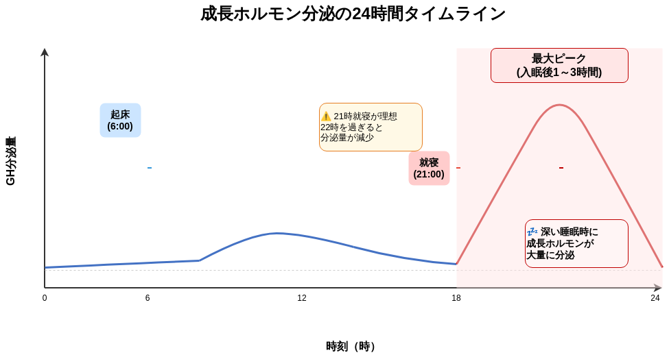

図2-1：24時間の成長ホルモン分泌パターン

つまり、**睡眠の質が悪い、または睡眠時間が短いと、成長ホルモンの分泌量が大幅に減る**のです。

これが、睡眠が最重要である第一の理由です。

### 睡眠不足の子供は年間1～2cm損をする

「睡眠不足だと、どれくらい身長に影響するの？」

複数の研究から、**慢性的な睡眠不足の子供は、十分な睡眠をとっている子供と比べて、年間1～2センチ身長の伸びが少ない**ことが分かっています。

これを小学生高学年の3年間で考えると：

- 十分な睡眠：年間6cm × 3年 = **18cm**
- 睡眠不足：年間5cm × 3年 = **15cm**
- **差：3cm**

さらに、睡眠不足は肥満のリスクも高めます（第5章で詳述）。肥満は思春期を早め、最終身長を低くします。

つまり、**睡眠不足の影響は「年間1～2cm」では済まない可能性がある**のです。

### 「夜10時～深夜2時」の嘘と真実

「成長ホルモンは夜10時から深夜2時の間に出るから、その時間に寝ていないとダメ」

こんな話を聞いたことがありませんか？

実は、これは**半分本当で、半分間違い**です。

**本当の部分**：

- 多くの子供が夜10時ごろに寝れば、深夜0時ごろに深睡眠に入る
- その時間帯に成長ホルモンが大量に分泌される

**間違いの部分**：

- 成長ホルモンの分泌は「時刻」で決まるわけではない
- **入眠後の「深い睡眠（ノンレム睡眠）」で決まる**

つまり、夜11時に寝ても、深夜1時に深睡眠に入れば、そこで成長ホルモンは分泌されます。

**でも、だからと言って遅く寝ていいわけではありません。**

なぜなら：

1. 遅く寝ると、朝の起床時刻に間に合わず、睡眠時間が短くなる
2. 生活リズムが乱れると、深い睡眠の質も低下する

結論：**「夜10時～深夜2時」という時刻にこだわるのではなく、「毎日同じ時刻に寝て、十分な睡眠時間を確保し、深い睡眠を得る」ことが重要**

## 2-2. 10～12歳男子に必要な睡眠時間

### 理想：9～11時間

米国国立睡眠財団や日本小児科学会の推奨によれば、10～13歳の子供に必要な睡眠時間は：

**理想：9～11時間**

「そんなに寝る時間ないよ！」と思われるかもしれません。

でも、これは「理想」であると同時に、**身体が本当に必要としている時間**なのです。

例えば：

- 朝6時起床なら → **夜9時就寝（睡眠時間9時間）**
- 朝6時30分起床なら → **夜9時30分就寝（睡眠時間9時間）**

### 最低ライン：8時間

「9時間は無理でも、最低限これだけは確保してほしい」という時間が：

**最低ライン：8時間**

これを下回ると、成長ホルモンの分泌が明らかに低下し、成長に悪影響が出る可能性が高くなります。

例えば：

- 朝6時起床なら → **夜10時就寝（睡眠時間8時間）**

### 日本の子供の現実：平均7.5時間（不足している）

では、実際の日本の子供たちは、どれくらい寝ているのでしょうか？

文部科学省の調査によれば、小学5～6年生の平均睡眠時間は：

**約7.5時間**

つまり、**ほとんどの子供が慢性的な睡眠不足**なのです。

これは非常に深刻な問題です。

でも、逆に言えば、**睡眠時間を増やすだけで、周りの子より有利になれる**ということでもあります。

### わが家の睡眠時間を今すぐチェック

以下のワークシートで、お子さんの実際の睡眠時間を確認してください。

**【睡眠時間チェックシート】**

| 曜日 | 就寝時刻 | 起床時刻 | 睡眠時間 | 評価 |
| --- | --- | --- | --- | --- |
| 月曜 | **:** | **:** | __時間__分 | ○/△/× |
| 火曜 | **:** | **:** | __時間__分 | ○/△/× |
| 水曜 | **:** | **:** | __時間__分 | ○/△/× |
| 木曜 | **:** | **:** | __時間__分 | ○/△/× |
| 金曜 | **:** | **:** | __時間__分 | ○/△/× |
| 土曜 | **:** | **:** | __時間__分 | ○/△/× |
| 日曜 | **:** | **:** | __時間__分 | ○/△/× |
| **平均** | - | - | **__時間__分** | - |

**評価基準：**

- ○：9時間以上（理想）
- △：8～9時間（最低ライン）
- ×：8時間未満（要改善）

もし平均が8時間未満なら、**今すぐ改善が必要**です。

## 2-3. 就寝時刻から逆算する生活設計

### 6時起床なら21時就寝が理想

睡眠時間を確保するには、**起床時刻から逆算**して就寝時刻を決めます。

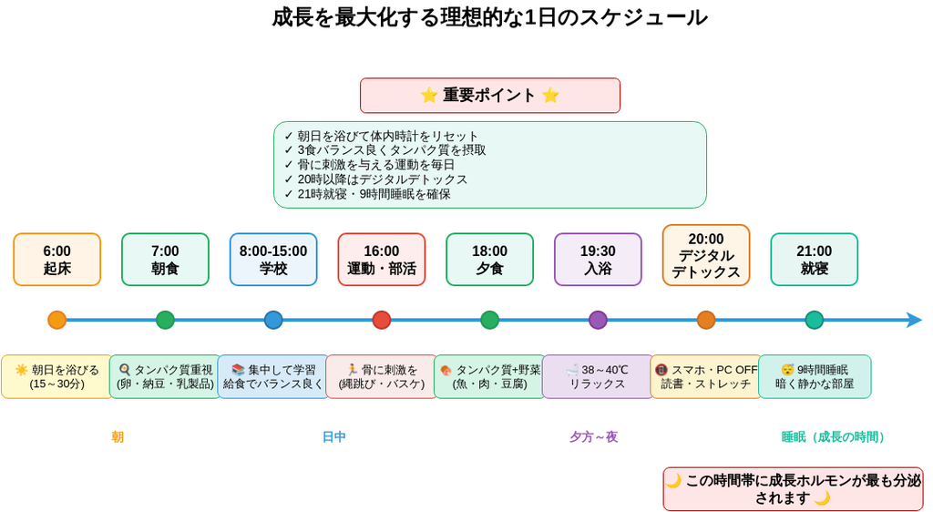

図2-2：理想的な1日のスケジュール

**起床時刻：朝6時の場合**

- 理想の睡眠時間：9時間
- **理想の就寝時刻：夜9時**
- 最低の睡眠時間：8時間
- **最低の就寝時刻：夜10時**

**起床時刻：朝6時30分の場合**

- 理想の睡眠時間：9時間
- **理想の就寝時刻：夜9時30分**
- 最低の睡眠時間：8時間
- **最低の就寝時刻：夜10時30分**

### 塾や習い事との調整

「でも、うちは塾が週3回あって、帰宅が21時30分なんです」

この悩みを抱えている方、多いのではないでしょうか。

ここで、厳しいことを言います。

**睡眠時間と塾、どちらが大切ですか？**

もちろん、学業も大切です。でも、**睡眠不足で身長が伸びず、脳の発達も妨げられ、学業成績も下がる**としたら？

実は、睡眠不足は学業成績にも悪影響を及ぼすことが科学的に証明されています。記憶の定着は睡眠中に起こるからです。

**つまり、睡眠を削って塾に行くのは、本末転倒**なのです。

#### 調整の選択肢

1. **塾の日数を減らす**
   - 週3回 → 週2回
2. **塾の時間帯を変える**
   - 夜の塾 → 土日の昼間
3. **オンライン授業に切り替える**
   - 移動時間が不要、自宅で効率的に
4. **塾をやめる**
   - 家庭学習や通信教育に切り替え

「そんなこと言われても…」と思われるかもしれません。

でも、**お子さんの一生に関わる選択**です。

塾で偏差値が5上がっても、身長が5センチ伸びなかったら、お子さんは将来どう思うでしょうか？

### 「無理」と思う前に試してほしいこと

「うちは共働きで、夜9時就寝なんて絶対無理」

そう思われる方もいるでしょう。

でも、本当に無理でしょうか？

以下のステップを試してみてください。

#### ステップ1：1週間の生活を記録する

- 帰宅時刻、夕食時刻、入浴時刻、就寝時刻をすべて記録

#### ステップ2：時間の無駄を見つける

- テレビを見ている時間
- ゲームをしている時間
- だらだらしている時間

#### ステップ3：優先順位を明確にする

- 睡眠を最優先に
- それ以外を調整

#### ステップ4：家族全員で協力する

- 夫にも協力してもらう
- 祖父母の助けを借りる

#### ステップ5：まず1週間だけ試す

- いきなり完璧を目指さない
- 就寝時刻を15分早めることから始める

**多くの家庭で、「無理」と思っていたことが、実は「やろうとしていなかっただけ」だったと気づきます。**

## 2-4. 質の高い睡眠のための5つの絶対ルール

睡眠時間を確保できても、**質の悪い睡眠では意味がありません。**

深い睡眠（ノンレム睡眠）に入らなければ、成長ホルモンは十分に分泌されないからです。

ここでは、質の高い睡眠のための「5つの絶対ルール」をお伝えします。

[figure not shown]

図2-3：睡眠の質を高める5つの絶対ルール

### ルール1：毎朝同じ時間に起こす

#### 週末も±1時間以内

「平日は6時起床、週末は9時起床」

これ、やっていませんか？

実は、これが睡眠の質を大きく低下させる原因です。

**体内時計は、毎日同じリズムを刻むことで最適化されます。**

週末に遅く起きると、体内時計がリセットされ、月曜日の朝がつらくなります（いわゆる「ブルーマンデー」）。

**推奨：**

- 平日：朝6時起床
- 週末：朝7時起床（±1時間以内）

#### 体内時計のリセット

体内時計をリセットするのは、**朝の光**です。

起床後すぐにカーテンを開け、朝日を浴びることで、体内時計が「朝だ」と認識します。

すると、約14～16時間後に自然な眠気が訪れるようになります。

例えば：

- 朝6時に起きて光を浴びる
- → 夜8時～10時に自然な眠気

**朝の光を浴びることが、夜の良い睡眠につながる**のです。

### ルール2：就寝1時間前のデジタルデトックス

これは、**5つのルールの中で最も重要**です。

#### スマホ・ゲーム・タブレットを物理的に回収

「寝る前にスマホを見るのをやめなさい」

何度言っても、お子さんは聞いてくれませんよね。

それは、**お子さんの意志の問題ではなく、脳の仕組みの問題**です。

スマホやゲームは、脳に強い刺激を与え、ドーパミン（快楽物質）を分泌させます。これは依存性があり、「やめられない」のは当然なのです。

**だから、「自主性に任せる」は失敗します。**

**唯一の解決策：物理的に回収する**

就寝1時間前（例：夜8時）になったら、親がスマホ・タブレット・ゲーム機をすべて回収します。

充電は、子供の寝室以外の場所で。

「そんなことしたら、子どもが怒る」

はい、最初は怒るでしょう。でも、これは**お子さんの未来のため**です。

1週間続ければ、習慣になります。

#### ブルーライトがメラトニンを25～30%減少させる

なぜ、就寝前のスマホがそれほど悪いのか？

**答え：ブルーライトがメラトニン（睡眠ホルモン）の分泌を強力に抑制するから**

研究によれば、就寝前1時間のスマホ使用で、メラトニン分泌が**25～30%減少**します。

メラトニンが減ると：

- 寝付きが悪くなる
- 深い睡眠に入りにくくなる
- 成長ホルモンの分泌が減る

つまり、**就寝前のスマホは、身長を伸ばす機会を奪っている**のです。

#### 「自主性に任せる」は失敗する

「うちの子は自分で管理できるはず」

残念ながら、小学生に自主性を期待するのは無理があります。

大人ですら、スマホ依存で悩む人がいるのに、子どもに任せるのは酷です。

**親の役割は、「環境を整えること」**です。

物理的に回収することで、お子さんを誘惑から守ってあげてください。

### ルール3：朝日を浴びる + 朝食を食べる

#### カーテンを開けて光を入れる

前述のとおり、朝の光が体内時計をリセットします。

起床後すぐに、カーテンを開けましょう。

曇りの日でも、室内の照明より明るい自然光が重要です。

#### タンパク質を含む朝食で体内時計ON

朝食を食べることも、体内時計のリセットに役立ちます。

特に、**タンパク質を含む朝食**が重要です。

タンパク質に含まれる「トリプトファン」という物質が、夜のメラトニン産生の材料になります。

**推奨朝食メニュー：**

- ご飯
- 卵料理（目玉焼き、スクランブルエッグなど）
- 納豆またはヨーグルト
- 野菜（味噌汁の具でも可）
- 牛乳

これで、タンパク質約20gが摂れます。

### ルール4：就寝2時間前までに夕食

#### 消化活動が深睡眠を妨げる

就寝直前に食事をすると、胃が活動中で、深い睡眠に入りにくくなります。

**推奨：就寝2時間前までに夕食を終える**

例えば：

- 就寝時刻：夜9時
- 夕食時刻：夜7時まで

#### 遅くなる場合の対処法

「塾や習い事で、どうしても夕食が遅くなる」

そんな場合は、以下の工夫を：

1. **分食する**
   - 夕方（塾の前）：おにぎり1個
   - 帰宅後：軽めの夕食
2. **消化の良いものを選ぶ**
   - 揚げ物は避ける
   - うどん、雑炊など
3. **量を減らす**
   - 腹八分目以下に

### ルール5：寝室環境の最適化

#### 真っ暗・静か・涼しめ（18～22℃）

睡眠の質を最大化する寝室環境は：

**光：真っ暗**

- 豆電球も消す
- 電子機器のLEDライトも隠す

**音：静か**

- 騒音レベル40デシベル以下
- 家族のテレビの音も配慮

**温度：18～22℃（やや涼しめ）**

- 夏：エアコンで調整
- 冬：暖房を切るか、弱めに

**湿度：40～60%**

- 乾燥しすぎないよう加湿器を使用

#### 遮光カーテン必須

朝日を浴びることは重要ですが、それは「起床後」の話。

**睡眠中は、外の光（街灯など）を完全に遮断**することが重要です。

遮光カーテンを使い、寝室を真っ暗にしましょう。

朝は、親が起こしてカーテンを開けるか、タイマー式の照明を使います。

## 2-5. 「うちの子、寝てくれない」パターン別解決法

「ルールは分かったけど、うちの子は寝てくれないんです」

そんなお悩み、よく分かります。

ここでは、よくあるパターン別に、具体的な解決法をお伝えします。

### パターン1：塾で帰宅が22時 → 優先順位を問い直す

**状況：** 週3回塾があり、帰宅が22時。そこから夕食、入浴で23時30分就寝。

**問題：** 睡眠時間が6.5時間しかない。

**解決法：**

#### ステップ1：塾の必要性を問い直す

- 本当にその塾が必要か？
- 費用対効果は？
- 睡眠を犠牲にする価値があるか？

#### ステップ2：代替案を検討

- 週3回 → 週1回に減らす
- 土日の昼間に変更
- オンライン授業に切り替え

#### ステップ3：夫と話し合う

- 一人で決めない
- データを見せる（睡眠不足が成長と学業に与える影響）
- 子どもの将来のために何が最善か、一緒に考える

**実例：** Aさん（母、40歳）は、息子（11歳）を週3回の進学塾に通わせていました。しかし、本書を読んで睡眠の重要性を知り、夫と話し合い、塾を週1回に減らしました。

結果：

- 睡眠時間：6.5時間 → 9時間
- 1年後の身長の伸び：5cm → 7cm
- 学業成績：変わらず（むしろ集中力が上がった）

息子は「塾が減って嬉しい。前より元気になった」と笑顔で話しています。

### パターン2：ゲームをやめない → 物理的に取り上げる具体策

**状況：** 「ゲームをやめて寝なさい」と言っても、やめない。

**問題：** 子どもの意志に期待している。

**解決法：**

#### ステップ1：ルールを明確にする

- 「夜8時になったら、ゲーム機を回収する」と事前に伝える
- 理由も説明する（身長を伸ばすため、睡眠が重要）

#### ステップ2：物理的に回収

- 夜8時になったら、問答無用で回収
- 充電はリビングで

#### ステップ3：最初の反発を覚悟する

- 怒る、泣く、反発する → 当然です
- でも、ここで折れない
- 「あなたのためを思っている」と伝える

#### ステップ4：1週間続ける

- 3日目くらいで諦めます
- 1週間で習慣になります

**実例：** Bさん（母、38歳）は、息子（10歳）のゲーム依存に悩んでいました。何度言ってもやめず、就寝は深夜12時。

本書を読んで、物理的回収を決行。最初は大泣きされましたが、夫も協力し、1週間続けました。

結果：

- 就寝時刻：深夜12時 → 夜9時30分
- 睡眠時間：6時間 → 8.5時間
- 1週間後：息子から「前より疲れない」という言葉
- 1ヶ月後：ゲームへの執着が減った

Bさんは「あの時心を鬼にして良かった」と語ります。

### パターン3：夫が協力しない → 巻き込む話し方

**状況：** 母親は睡眠の重要性を理解しているが、夫が「そんなに神経質にならなくても」と協力してくれない。

**問題：** 夫の理解不足。

**解決法：**

#### ステップ1：データを見せる

- 感情ではなく、科学的根拠を示す
- 本書を一緒に読む
- 「睡眠不足で年間1～2cm損をする」というデータ

#### ステップ2：「お願い」ではなく「一緒に考える」

- ×「協力して」
- ○「一緒に子どもの未来を考えたい」

#### ステップ3：具体的な役割を依頼

- 「夜8時にゲームを回収する役、お願いできる？」
- 役割を与えることで、当事者意識が生まれる

#### ステップ4：成果を共有する

- 1ヶ月後、身長の伸びを一緒に確認
- 「あなたのおかげ」と感謝を伝える

**実例：** Cさん（母、42歳）の夫は、「子どもは自由にさせるべき」という考えでした。

Cさんは、本書の第1章と第2章を夫に読んでもらい、一緒に息子（12歳）の成長曲線を確認しました。

夫は「こんなに重要だったのか」と驚き、協力を約束。夜8時のデバイス回収は、夫の役割になりました。

結果：

- 家族全員の意識が変わった
- 夫婦の会話も増えた
- 息子の睡眠時間が2時間増えた

### パターン4：反抗期で言うことを聞かない → 本人を納得させる方法

**状況：** 中学生になり、反抗期。親の言うことを聞かない。

**問題：** 頭ごなしに命令しても逆効果。

**解決法：**

#### ステップ1：本人に選ばせる

- 「睡眠を増やすか、それとも身長を諦めるか、自分で決めて」
- 選択肢を与えることで、主体性を尊重

#### ステップ2：データを見せる

- 「君の予測身長は165cm。でも、睡眠を改善すれば170cmになれるかもしれない」
- 具体的な数値で示す

#### ステップ3：目標を一緒に決める

- 「じゃあ、1週間だけ試してみる？」
- 期限を区切ることで、ハードルを下げる

#### ステップ4：成果を一緒に確認

- 1週間後：「疲れが減った？」
- 1ヶ月後：「身長測ってみようか」

**実例：** Dさん（母、45歳）の息子（13歳）は、反抗期真っ只中。親の言うことは一切聞きませんでした。

Dさんは、本書を息子に直接渡し、「読んでみて。自分で決めていいから」と伝えました。

息子は最初は無視していましたが、ある日読み始め、「1週間だけ試す」と言ってきました。

結果：

- 自分で決めたことなので、続けられた
- 1ヶ月後、身長が1.5cm伸び、本人が驚いた
- 今では自分から「早く寝る」と言うように

## 2-6. 1週間実践シート

さあ、理屈は分かりました。

次は、**実践**です。

以下の「1週間実践シート」を使って、今週から始めましょう。

### 記録項目

| 日付 | 就寝時刻 | 起床時刻 | 睡眠時間 | デバイス回収 | 朝の目覚め | メモ |
| --- | --- | --- | --- | --- | --- | --- |
| __月__日 | **:** | **:** | __時間 | ○/× | ☆☆☆☆☆ |  |
| __月__日 | **:** | **:** | __時間 | ○/× | ☆☆☆☆☆ |  |
| __月__日 | **:** | **:** | __時間 | ○/× | ☆☆☆☆☆ |  |
| __月__日 | **:** | **:** | __時間 | ○/× | ☆☆☆☆☆ |  |
| __月__日 | **:** | **:** | __時間 | ○/× | ☆☆☆☆☆ |  |
| __月__日 | **:** | **:** | __時間 | ○/× | ☆☆☆☆☆ |  |
| __月__日 | **:** | **:** | __時間 | ○/× | ☆☆☆☆☆ |  |

**デバイス回収：**

- ○：就寝1時間前に回収できた
- ×：できなかった

**朝の目覚め（5段階評価）：**

- ☆☆☆☆☆：最高に目覚めが良い
- ☆☆☆☆：良い
- ☆☆☆：普通
- ☆☆：悪い
- ☆：最悪

**メモ：** 気づいたこと、困ったことなどを自由に記入

### 1週間後の振り返り

1週間続けたら、以下の質問に答えてください。

**Q1. 平均睡眠時間は？**

- 1週間の合計睡眠時間 ÷ 7 = __時間__分

**Q2. 目標（8時間以上）を達成できた日は？**

- 7日中__日

**Q3. デバイス回収を実行できた日は？**

- 7日中__日

**Q4. 朝の目覚めの変化は？**

- 良くなった / 変わらない / 悪くなった

**Q5. 子どもの様子の変化は？** （自由記述）

**Q6. 次の1週間で改善したいことは？** （自由記述）

# 第3章：栄養 - 骨を作る「材料」を届ける

「うちの子、少食で…」 「好き嫌いが多くて栄養が心配」 「サプリメント飲ませたほうがいいですよね？」

小学校高学年男子のお母さんからよく聞く悩みです。

栄養は、成長ホルモンが指示を出しても、それを実現する「材料」がなければ意味がありません。どれだけ深く眠っても、どれだけ運動しても、材料不足では骨は伸びません。

この章では、科学的根拠に基づいた栄養の知識と、忙しいお母さんでも実践できる具体的な方法をお伝えします。

## 3-1. 10～12歳男子に必要な栄養素はこれだけ

「栄養バランスが大事」とは分かっていても、具体的に何をどれだけ食べさせればいいのか分かりにくいですよね。

成長期の男子に必要な栄養素は多数ありますが、**身長を伸ばす**という観点から特に重要なのは以下の5つです。

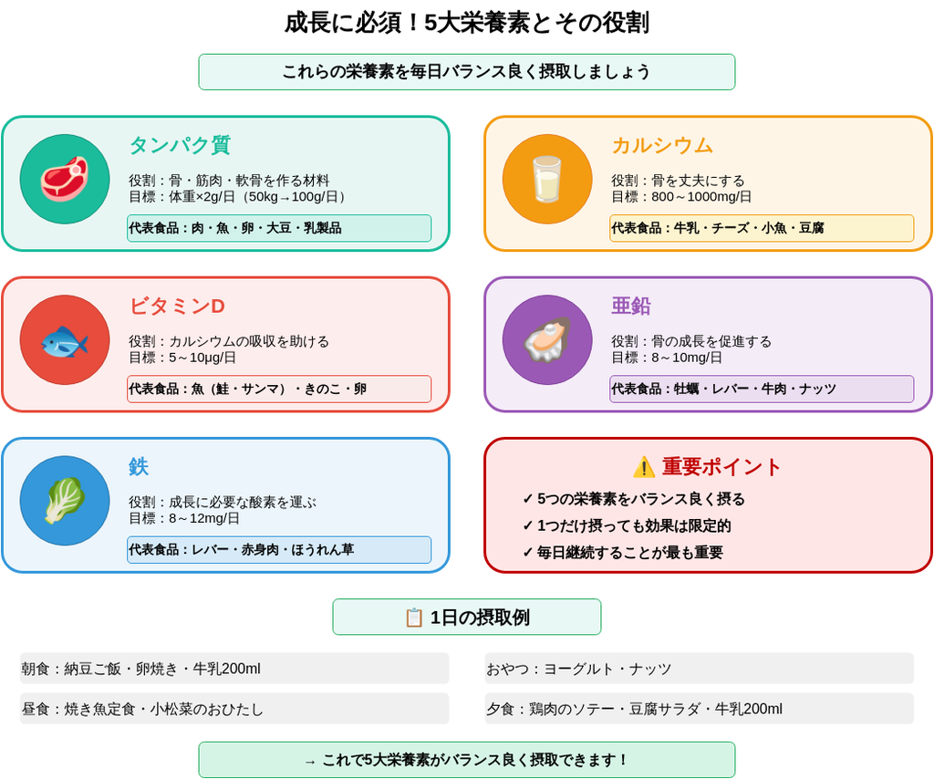

図3-1：身長を伸ばす5つの必須栄養素

タンパク質は、骨・筋肉・臓器・ホルモンなど、体のあらゆる組織の主成分です。成長ホルモンの働きを仲介するIGF-1もタンパク質でできています。不足すると骨の成長が妨げられます。

- 朝食：卵1個（6g）+ 納豆1パック（7g）+ 牛乳200ml（7g）= 20g
- 昼食（給食）：肉or魚（10～15g）
- 夕食：鶏肉100g（23g）= 23g
- **合計：約58g** ✓

**良質なタンパク質源**：動物性（肉、魚、卵、牛乳、ヨーグルト）、植物性（納豆、豆腐）

カルシウムは骨の主材料です。成長期は骨形成が活発で、大量のカルシウムが必要です。

**1日の食事例で700mg達成**：

- 朝食：牛乳200ml（220mg）
- 昼食：ヨーグルト（120mg）
- 夕食：豆腐の味噌汁（120mg）+ 小松菜の和え物（119mg）
- おやつ：チーズ1切れ（126mg）
- **合計：約705mg** ✓

**主な供給源**：牛乳、ヨーグルト、チーズ、小魚、豆腐、小松菜

### 重要：ビタミンD 5～10μg/日

ビタミンDは、カルシウムの腸管吸収を促進する必須栄養素です。不足すると吸収率が大幅に低下します。

**摂取方法**： 1. 食品から：魚（鮭、サンマ、サバ）を週2～3回 2. 日光から：1日10～20分程度の日光浴（手のひら・腕程度の露出で十分）

亜鉛は「成長のミネラル」と呼ばれ、IGF-1の産生に深く関わっています。不足するとタンパク質合成が滞り、成長が妨げられます。

**1日の食事例で7mg達成**：

- 朝食：納豆1パック（1mg）+ 卵1個（0.6mg）
- 昼食：給食（約1～2mg）
- 夕食：牛肉100g（4.5mg）
- **合計：約7.1mg** ✓

**主な供給源**：牛肉、豚レバー、牡蠣、納豆、卵

### 鉄 8～10mg/日

鉄は血液中のヘモグロビンの成分で、全身に酸素を運びます。不足すると貧血になり、疲労や睡眠の質の低下を引き起こし、間接的に成長を阻害します。

**主な供給源**：豚レバー、あさり、牛肉、ほうれん草、ひじき **吸収を高めるコツ**：ビタミンC（果物、野菜）と一緒に摂取

## 3-2. 1日の食事プラン（完全版）

栄養の知識があっても、実際の食事に落とし込むのが大変ですよね。ここでは、忙しいお母さんでも実践できる「黄金パターン」をご紹介します。

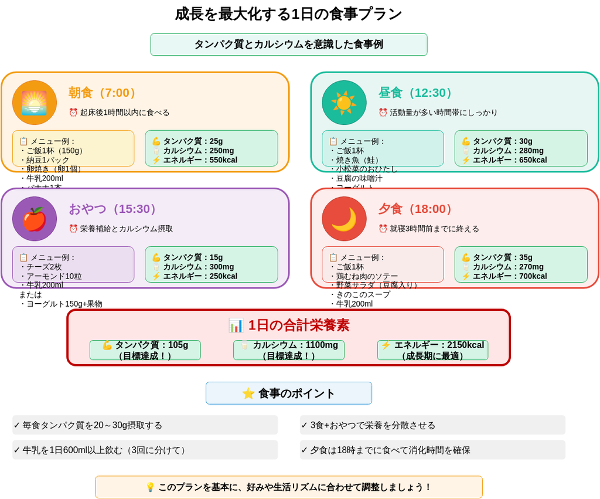

図3-2：1日の食事プラン（朝・昼・夕の黄金パターン）

### 朝食の黄金パターン

**基本構成**： ご飯/パン + 卵料理 + 納豆/ヨーグルト + 野菜 + 牛乳

**パターン1：和食**（タンパク質22g、カルシウム240mg）

- ご飯 1杯（150g）
- 目玉焼き 1個
- 納豆 1パック
- ほうれん草のおひたし
- 味噌汁（豆腐入り）
- 牛乳 200ml

**パターン2：洋食**（タンパク質20g、カルシウム260mg）

- 食パン 2枚
- スクランブルエッグ（卵1個）
- ヨーグルト 1カップ
- トマト、レタスのサラダ
- 牛乳 200ml

**パターン3：時短版**（5分で完成、タンパク質18g）

- ご飯 1杯
- 卵かけご飯（卵1個 + 醤油）
- 納豆 1パック
- 牛乳 200ml
- ※前日の味噌汁があれば温めて追加

**重要ポイント**：

- **タンパク質20g確保**が最優先
- 牛乳は手軽なカルシウム源として優秀
- 朝食を抜くことは絶対に避ける

### 昼食（給食/弁当）

**給食の場合**： 栄養士が献立を考えているため、基本的に安心です。おかわりできる場合は、主菜（肉・魚）をおかわりさせましょう。

**弁当の場合の黄金パターン**：

**基本構成**： ご飯 + 主菜（肉or魚たっぷり）+ 副菜2品 + 卵料理

**具体例**（タンパク質25g、カルシウム150mg）

- ご飯 1.5杯分
- 鶏肉の照り焼き（鶏肉80g = タンパク質18g）
- 卵焼き（卵1個 = タンパク質6g）
- ブロッコリーのおかか和え
- プチトマト
- ヨーグルト（デザート）

**時短弁当のコツ**：

- 週末に鶏肉やハンバーグを焼いて冷凍
- 卵焼きは前日夜に作り置き
- 冷凍食品も活用OK（栄養表示を確認）

### 夕食の黄金パターン

**基本構成**： 主食 + 主菜（肉or魚たっぷり）+ 副菜2品 + 汁物

**パターン1：魚メイン**（タンパク質30g、カルシウム320mg）

- ご飯 1.5杯
- 鮭の塩焼き 1切れ（タンパク質18g）
- ひじきの煮物（カルシウム・鉄豊富）
- 小松菜の和え物（カルシウム豊富）
- 豆腐の味噌汁（タンパク質・カルシウム）

**パターン2：肉メイン**（タンパク質35g、カルシウム200mg）

- ご飯 1.5杯
- ハンバーグ 1個（牛豚合挽き100g = タンパク質20g）
- サラダ（レタス、トマト、ブロッコリー）
- きんぴらごぼう
- わかめの味噌汁

**パターン3：丼もの**（タンパク質28g）

- 親子丼（鶏肉100g + 卵2個 + ご飯）
- 小鉢（ほうれん草のおひたし）
- 豆腐の味噌汁

**重要ポイント**：

- **タンパク質30g以上確保**が目標
- 魚と肉を交互に（週3～4回ずつ）
- 野菜は2品以上（色の濃い野菜を意識）
- 汁物に豆腐を入れてタンパク質とカルシウムを追加

### おやつの選び方

**NG：これは避けたい**

- スナック菓子（ポテトチップス、チョコレート菓子など）
- 清涼飲料水（コーラ、スポーツドリンクなど）
  - 理由：糖分過多 → 肥満 → 思春期早発 → 最終身長低下のリスク

**OK：これを選ぼう**

- ヨーグルト（カルシウム、タンパク質）
- チーズ（カルシウム、タンパク質）
- ナッツ類（亜鉛、良質な脂質）
- 果物（ビタミンC、食物繊維）
- おにぎり（エネルギー補給）
- 牛乳、豆乳

**おやつのタイミング**：

- 部活後、運動後がベスト（エネルギー補給）
- 夕食の2～3時間前までに済ませる

## 3-3. 1週間献立例（参考）

「毎日献立を考えるのが大変…」というお母さんのために、3日分の献立例をご用意しました。

### 月曜日の例

**朝食**：ご飯、目玉焼き、納豆、味噌汁（豆腐・わかめ）、牛乳 **夕食**：ご飯、鮭の塩焼き、ひじきの煮物、小松菜のおひたし、豆腐の味噌汁 **栄養素合計**：タンパク質75g、カルシウム780mg

### 水曜日の例

**朝食**：ご飯、卵焼き、納豆、ほうれん草のおひたし、味噌汁、牛乳 **夕食**：ご飯、鶏の照り焼き（鶏肉150g）、ブロッコリーのおかか和え、豆腐の味噌汁 **栄養素合計**：タンパク質80g、カルシウム750mg

### 金曜日の例

**朝食**：ご飯、目玉焼き、納豆、小松菜のおひたし、味噌汁、牛乳 **夕食**：親子丼（鶏肉100g、卵2個）、小鉢（ひじきの煮物）、豆腐の味噌汁 **栄養素合計**：タンパク質82g、カルシウム730mg

### 買い物リストの例

**タンパク質源**：鮭・サバ各2切れ、鶏肉300g、卵15個、納豆7パック、豆腐3丁、ヨーグルト7個、牛乳2L×2本 **野菜・その他**：ほうれん草・小松菜各2束、ブロッコリー1株、トマト、レタス、人参、ごぼう、ひじき、わかめ

## 3-4. 「うちの子あるある」トラブル解決

### トラブル1：少食・食が細い

**お母さんの悩み**： 「うちの子、本当に食が細くて…。ご飯を半分しか食べないし、おかずもちょっとしか食べません。栄養が足りているか心配です」

**原因**：

- 胃が小さい
- 運動不足でお腹が空かない
- 間食が多い
- ストレスや緊張

**解決策：高栄養密度メニュー**

少量でも栄養価の高い食品を選びましょう。

**おすすめ食品**：

- **卵**：1個でタンパク質6g、手軽で栄養豊富
- **納豆**：1パックでタンパク質7g、亜鉛・鉄も
- **チーズ**：1切れでカルシウム126mg、タンパク質5g
- **ヨーグルト**：食べやすく、カルシウム・タンパク質豊富
- **肉の脂身の少ない部位**（鶏むね、ささみ）：タンパク質が濃縮

**具体的な工夫**：

- ご飯に雑穀を混ぜる（栄養価アップ）
- おかずを小さく切って食べやすくする
- スムージー（果物 + ヨーグルト + 牛乳）で飲みやすく
- 間食をスナック菓子からヨーグルト・チーズに変更
- 運動量を増やしてお腹を空かせる

**重要**：無理強いは逆効果。ストレスになり、余計に食べなくなります。

### トラブル2：牛乳嫌い

**解決策：牛乳以外でカルシウム確保**

**代替食品**：ヨーグルト、チーズ、小魚、豆腐、小松菜

### トラブル3：野菜を食べない

**解決策：「見えなくする」工夫**

1. 細かく刻んでハンバーグやカレーに混ぜる
2. スムージーにする（ほうれん草 + バナナ + ヨーグルト）
3. 味付けを工夫（ケチャップ、マヨネーズ、チーズ）
4. ポタージュスープにする

**重要**：身長を伸ばす観点からは「タンパク質・カルシウム・ビタミンD・亜鉛」が最優先。野菜が食べられなくても、肉・魚・卵・乳製品がしっかり摂れていればOKです。

### トラブル4：魚嫌い

**解決策：肉・卵で代替 + 日光浴**

- **ビタミンD**：日光浴（1日10～20分）、卵黄、きのこ類
- **タンパク質**：肉、卵、大豆製品
- **料理の工夫**：骨なしの切り身、味付けを濃く、揚げ物にする

### トラブル5：朝食を食べない

**解決策：前日夕食を早める**

1. 夕食を18時～19時に済ませる（就寝2～3時間前まで）
2. 夜食を止める
3. 最初は少量から徐々に慣らす（バナナ、ヨーグルトなど）
4. 早寝早起きで朝に余裕を持つ

**重要**：朝食は体内時計のリセット、1日のエネルギー源として極めて重要です。

## 3-5. サプリメントの真実（2024年最新）

「身長を伸ばすサプリメント」「アルギニンサプリ」…。インターネットや薬局で様々なサプリメントが売られていますが、本当に効果があるのでしょうか？

### 「身長を伸ばすサプリ」は全て効果なし

**結論から言います**： 市販されている「身長を伸ばすサプリ」に科学的根拠はありません。

**日本小児内分泌学会の公式見解**： 「身長を伸ばす効果を謳うサプリメントに医学的根拠はない」

**理由**：

1. 成長ホルモンは経口摂取では効果がない（消化管で分解される）
2. アルギニン、オルニチンなどのアミノ酸も経口摂取では血中濃度が不十分
3. カルシウム、ビタミンDなどは食事で十分に摂取可能

### アルギニンサプリの嘘（日本小児内分泌学会の公式見解）

「アルギニンを飲めば成長ホルモンが増えて身長が伸びる」という宣伝を見たことがありませんか？

**日本小児内分泌学会の公式見解（2024年8月14日改訂版）**：

**医療検査での使用**：

- アルギニンは「GH分泌刺激試験」（低身長児の診断）で使われる
- 投与量：0.5g/kg（例：体重30kgの子供に15g）を**静脈注射**

**サプリメントの問題**：

- 市販サプリのアルギニン含有量：医療用の**1/50～1/5程度**
- 経口摂取では血中濃度が十分に上がらない

**結論**： **「経口摂取のアルギニンが成長ホルモン分泌を促進するという信頼できる学術報告はない」**

**「仮に成長ホルモン分泌が一時的に増えても、身長が伸びることは科学的に証明されていない」**

### その3000円を食材に使う方が100倍効果的

サプリメント1ヶ月分の費用：3,000～10,000円

この金額を食材に使えば：

- 鶏むね肉 3kg（約1,500円）= タンパク質約690g
- 卵 30個（約450円）= タンパク質約180g
- 牛乳 6L（約1,200円）= カルシウム約6,600mg、タンパク質約210g
- サケ 10切れ（約2,000円）= タンパク質約180g、ビタミンD約260μg
- 納豆 30パック（約900円）= タンパク質約210g、亜鉛約30mg

**どちらが効果的か、一目瞭然ですよね。**

### 例外：医師が診断した欠乏症のみ

サプリメントが有効な唯一のケースは、**医師が診断した栄養欠乏症がある場合のみ**です。

**例**：

- ビタミンD欠乏症 → ビタミンDサプリ（医師の処方）
- 鉄欠乏性貧血 → 鉄剤（医師の処方）
- 亜鉛欠乏症 → 亜鉛サプリ（医師の処方）

これらは医師が血液検査などで診断し、処方するものです。自己判断でサプリを飲むことは推奨されません。

### お母さんへのメッセージ

**サプリメントに頼らず、食事に投資しましょう**

- 「楽に」「簡単に」身長を伸ばす魔法の薬はありません
- 成長期の子供に必要なのは、バランスの取れた食事です
- サプリメントの広告に惑わされず、科学的根拠に基づいた方法を実践しましょう
- その3,000円を、良質な肉・魚・卵・乳製品の購入に充てることが、最も確実で効果的です

## 3-6. 簡単！栄養チェックシート

「うちの子、ちゃんと栄養が足りているのかな？」

そんな不安を解消するために、簡単にチェックできるシートをご用意しました。

### 1日の食事記録シート

| 食事 | 時刻 | 食べたもの | タンパク質（g） | カルシウム（mg） |
| --- | --- | --- | --- | --- |
| 朝食 |  |  |  |  |
| 昼食 |  |  |  |  |
| おやつ |  |  |  |  |
| 夕食 |  |  |  |  |
| **合計** |  |  |  |  |

**目標値**：

**朝食**

- 卵 1個（6g）
- 納豆 1パック（7g）
- 牛乳 200ml（7g）
- ヨーグルト 1カップ（4g）
- 朝食合計：___g

**昼食（給食または弁当）**

- 肉or魚（10～15g）
- 卵料理（6g）
- 牛乳 or ヨーグルト（4～7g）
- 昼食合計：___g

**夕食**

- 肉 100g（20～23g）
- 魚 1切れ（18g）
- 豆腐 1/3丁（7g）
- 卵料理（6g）
- 夕食合計：___g

**1日合計：___g**

**朝食**

- 牛乳 200ml（220mg）
- ヨーグルト 1カップ（120mg）
- 豆腐の味噌汁（120mg）
- 朝食合計：___mg

**昼食**

- 給食（約200mg）
- ヨーグルト（120mg）
- 昼食合計：___mg

**おやつ**

- チーズ 1切れ（126mg）
- おやつ合計：___mg

**夕食**

- 豆腐の味噌汁（120mg）
- 小松菜のおひたし（119mg）
- 小魚（しらす、煮干し）（50～220mg）
- 夕食合計：___mg

**1日合計：___mg**

### 改善ポイントの見つけ方

**ステップ1：1週間記録する**

- まず1週間、毎日の食事を記録しましょう
- タンパク質とカルシウムの量を計算

**ステップ2：目標値と比較**

- タンパク質：40～50g達成しているか？
- カルシウム：700～1000mg達成しているか？

**ステップ3：不足している栄養素を特定**

- タンパク質が不足 → 肉・魚・卵・大豆製品を増やす
- カルシウムが不足 → 牛乳・ヨーグルト・チーズ・小魚・豆腐を増やす

**ステップ4：具体的な改善策を実行**

- 朝食に卵と納豆を追加
- おやつをスナック菓子からヨーグルトに変更
- 味噌汁に必ず豆腐を入れる
- ご飯にしらすを混ぜる

**ステップ5：2週間後に再チェック**

- 改善策が実行できているか確認
- 目標値に近づいているか確認

### お母さんへのエール

栄養管理は完璧を目指す必要はありません。

**重要なのは**：

- 毎日バランスの取れた食事を心がけること
- タンパク質とカルシウムを意識すること
- サプリメントに頼らず、食事から摂ること
- 楽しく食事をすること

1週間の平均で目標値に近づいていればOKです。1日くらい目標に届かなくても大丈夫。長期的な視点で、お子さんの成長をサポートしていきましょう。

# 第4章：運動 - 骨端線への「刺激」を与える

「うちの子、運動が苦手で…」 「部活で毎日疲れて帰ってくるけど、これって身長に良いの？」 「縄跳びが身長に良いって聞いたけど、本当？」

運動と身長の関係について、お母さんから多くの質問をいただきます。

この章では、なぜ運動が身長を伸ばすのか、どんな運動が効果的なのか、そして部活動や運動嫌いな子供への対応まで、科学的根拠に基づいて詳しく解説します。

## 4-1. 運動が身長を伸ばす3つのメカニズム

「運動すると身長が伸びる」とよく言われますが、なぜでしょうか？

実は、運動が身長に影響を与えるメカニズムは3つあります。

### メカニズム1：骨端線への物理的刺激

**身長が伸びる仕組みのおさらい**

身長が伸びるのは、骨の端にある「骨端線（成長軟骨帯）」が成長するからです。この骨端線は、思春期が終わる頃（男子で17～19歳頃）に閉じてしまい、一度閉じると二度と開きません。

**運動がどう影響するのか？**

運動、特にジャンプや走る動作は、骨端線に適度な物理的刺激を与えます。

**科学的メカニズム**：

1. ジャンプ・着地の衝撃 → 骨端線に縦方向の負荷
2. この負荷が骨端軟骨の血流を促進
3. 成長ホルモンや栄養素が軟骨細胞に効率よく運ばれる
4. 軟骨細胞の増殖が活発化 → 骨の成長が促される

**小児スポーツ医学の研究**では、「走る・跳ぶ・スプリント・縄跳び」が骨密度向上と成長促進に寄与することが確認されています。

**重要な注意点**： 過度な負荷は逆効果です。骨端線を損傷すると、成長障害を引き起こす可能性があります（オスグッド病、シーバー病など）。適度な刺激が重要です。

### メカニズム2：成長ホルモン分泌の一時的増加

運動中および運動後に、成長ホルモン（GH）の分泌が増加することが科学的に確認されています。

**どんな運動が効果的？**

特に**高強度の短時間運動**（スプリント、ジャンプ）で成長ホルモンの分泌が顕著に増加します。

**具体例**：

- 全力ダッシュ（30秒 × 3～5セット）
- 縄跳び（二重跳び、高速跳び）
- バスケットボール（ジャンプ動作が多い）
- バレーボール（同上）

**重要なポイント**： 運動による成長ホルモン分泌は**一時的**です。運動「だけ」で身長が劇的に伸びるわけではありません。しかし、睡眠や栄養と組み合わせることで、相乗効果が期待できます。

### メカニズム3：深睡眠の促進

適度な運動は、夜の深い睡眠（ノンレム睡眠）を促進します。

**メカニズム**：

1. 運動により適度な疲労感が生じる
2. 体温が上昇し、その後下降する過程で眠気が生じる
3. 深い睡眠に入りやすくなる
4. 深睡眠時に成長ホルモンが大量に分泌される

第2章でお伝えした通り、**成長ホルモンの70～80%は深睡眠時に分泌**されます。運動は、この深睡眠を促進する重要な要素なのです。

**注意点**：

- 就寝直前の激しい運動は逆効果（交感神経が興奮して眠れなくなる）
- 運動は夕方までに済ませるのが理想

**3つのメカニズムのまとめ**

| メカニズム | 効果 | 推奨される運動 |
| --- | --- | --- |
| 骨端線への物理的刺激 | 骨の成長促進 | ジャンプ、走る、縄跳び |
| 成長ホルモン分泌増加 | 一時的なGH増加 | 高強度短時間運動（スプリント、ジャンプ） |
| 深睡眠の促進 | 夜間のGH分泌増加 | 適度な運動（60分程度） |

## 4-2. 効果的な運動ランキング

「どんな運動が身長を伸ばすのに効果的？」

科学的根拠、実践のしやすさ、コストパフォーマンスを総合的に評価したランキングをご紹介します。

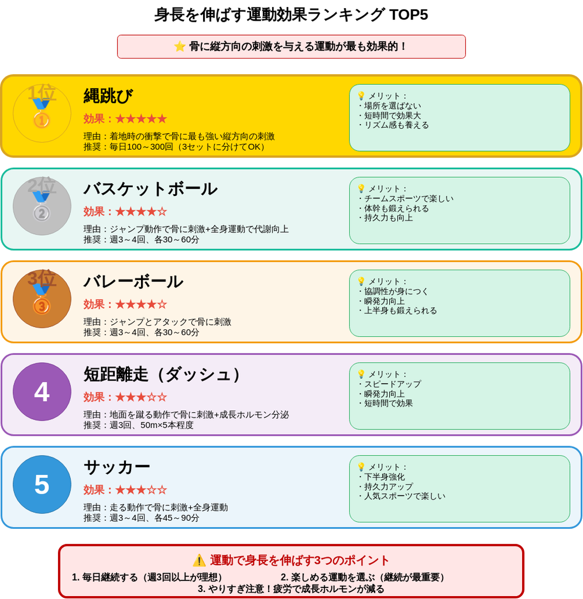

図4-1：身長を伸ばす運動の効果ランキング

### 第1位：縄跳び（コスパ最強・1日10～15分）

**なぜ縄跳びが1位なのか？**

縄跳びは、身長を伸ばす観点から**最もコストパフォーマンスが高い運動**です。

**縄跳びの5つのメリット**：

1. **費用が安い**
   - 縄1本（500～1,500円）で十分
   - 特別な施設不要
2. **場所を選ばない**
   - 自宅の庭、公園、駐車場、体育館
   - 天候が悪い日は室内（マット敷き）でも可能
3. **短時間で効果的**
   - 1回10～15分で十分
   - 忙しいお子さんでも継続可能
4. **骨への縦方向の刺激が豊富**
   - ジャンプと着地の繰り返し → 骨端線への適度な負荷
   - 科学的にも骨密度向上と成長促進が確認されている
5. **全身運動**
   - 心肺機能向上
   - 体力・持久力アップ
   - カロリー消費も高い（肥満予防）

**1日の推奨時間**：

- 10～15分/日、週3～5回

**注意点**：

- 固いコンクリートの上で長時間跳ぶと膝や足首に負担
- 靴底が厚いスニーカーを履く
- 姿勢を正しく（背筋を伸ばして）

### 第2位：バスケットボール

**おすすめポイント**：

- ジャンプ動作が豊富（シュート、リバウンド、ブロック）
- 骨端線への縦方向の刺激が豊富
- チームスポーツで楽しい
- 走る動作も含まれ、全身運動

**注意点**：

- バスケ部に入る場合、練習量に注意（やりすぎは逆効果）
- 休息日を週に1～2日確保

### 第3位：バレーボール

**おすすめポイント**：

- ジャンプ動作が豊富（スパイク、ブロック、サーブ）
- バスケと同様、骨端線への刺激が豊富
- 上半身の筋力も鍛えられる

### 第4位：短距離走（スプリント）

**おすすめポイント**：

- 高強度の短時間運動 → 成長ホルモン分泌促進
- 骨への縦方向の負荷
- 短時間で効果的

**具体的な方法**：

- ウォームアップ必須（怪我防止）
- クールダウンも忘れずに

### 第5位：サッカー

**おすすめポイント**：

- 走る動作が主体
- チームスポーツで楽しい
- 全身運動

**注意点**：

- ジャンプ動作は少なめ（バスケ・バレーに比べて）
- サッカー部の場合、練習量に注意

### 水泳・自転車は？

**水泳**：

- 全身運動として優秀
- 心肺機能、筋力向上
- しかし、**骨への縦方向の刺激が少ない**
- 身長を伸ばす観点からは中程度の効果

**自転車**：

- 有酸素運動として優秀
- しかし、**骨への縦方向の刺激がほとんどない**
- 身長を伸ばす観点からは効果は限定的

**結論**： 水泳・自転車も健康には良いですが、**身長を伸ばす**という観点からは、縄跳び・バスケ・バレーのようなジャンプ動作を含む運動の方が効果的です。

## 4-3. 縄跳び完全マスタープログラム

「縄跳びが良いのは分かったけど、具体的にどうやって始めればいいの？」

ここでは、初級から上級まで、段階的にレベルアップできるプログラムをご紹介します。

[figure not shown]

図4-2：縄跳びマスタープログラム（初級→上級）

### 初級（連続20回を目指す）

**対象**：

- 縄跳びが苦手な子供
- 連続で跳べない子供

**目標**：

- 前跳び連続20回

**プログラム**（1日10分、週3～5回）

**ステップ1：1週目（連続5回）**

- 前跳び：5回 × 5セット（休憩30秒）
- できたら褒める、ご褒美シール

**ステップ2：2週目（連続10回）**

- 前跳び：10回 × 3セット

**ステップ3：3～4週目（連続20回）**

- 前跳び：20回 × 2セット
- 達成したら記録シートに記入

**コツ**：

- 縄の長さを調整（両端を持って足で踏んだとき、胸の高さ）
- 手首を使って回す（腕全体を振らない）
- リズムよく跳ぶ（1、2、3、4…と数える）
- 親が一緒に跳ぶ（楽しい雰囲気づくり）

**初級クリアの目安**：1ヶ月

### 中級（連続100回を目指す）

**対象**：

- 初級クリア（連続20回達成）
- さらにレベルアップしたい子供

**目標**：

- 前跳び連続100回
- 後ろ跳び連続20回
- かけ足跳び連続50回

**プログラム**（1日15分、週3～5回）

**1ヶ月目**：

- 前跳び：50回 × 2セット
- 後ろ跳び：10回 × 2セット
- かけ足跳び：20回 × 2セット

**2ヶ月目**：

- 前跳び：100回 × 1セット
- 後ろ跳び：20回 × 1セット
- かけ足跳び：50回 × 1セット

**3ヶ月目（維持期）**：

- 前跳び：100回以上
- 後ろ跳び、かけ足跳び、あや跳びなど、バリエーションを増やす

**記録シートの活用**：

- 毎日の回数を記録
- 目標達成でシール、ご褒美
- グラフ化して成長を可視化

**中級クリアの目安**：3ヶ月

### 上級（二重跳びをマスター）

**対象**：

- 中級クリア（連続100回達成）
- 二重跳びに挑戦したい子供

**目標**：

- 二重跳び連続10回
- 前跳び連続300回以上

**プログラム**（1日15分、週3～5回）

**二重跳び練習法**：

**ステップ1：1回ずつ成功させる**

- 前跳び3回 → 二重跳び1回 → 前跳び3回
- これを5セット繰り返す
- 二重跳びの感覚をつかむ

**ステップ2：連続2～3回**

- 二重跳び2回 → 前跳び5回
- 徐々に二重跳びの回数を増やす

**ステップ3：連続10回**

- 二重跳び連続10回を目指す
- 達成まで1～3ヶ月

**コツ**：

- 縄を速く回す（手首のスナップを使う）
- 高く跳ぶ（膝を曲げて）
- 最初は1回ずつ確実に

**上級プログラム全体**：

- ウォームアップ：前跳び100回（2分）
- 二重跳び練習：10分
- クールダウン：かけ足跳び、後ろ跳びなど（3分）

**上級クリアの目安**：3～6ヶ月

### 雨の日の代替運動

**室内でできる運動**：

- その場ジャンプ（マットやカーペットの上で）
- 階段の上り下り（ゆっくり、安全に）
- トランポリン（家庭用小型タイプ）
- 踏み台昇降運動

### 縄跳び記録シート（例）

| 日付 | 前跳び | 後ろ跳び | 二重跳び | メモ |
| --- | --- | --- | --- | --- |
| 4/1 | 50回 | 10回 | 0回 | 前跳び新記録！ |
| 4/2 | 60回 | 15回 | 0回 |  |
| 4/3 | 休み | - | - |  |
| 4/4 | 80回 | 20回 | 1回 | 二重跳び初成功！ |

**記録シートのメリット**：

- 成長を可視化できる
- モチベーション維持
- 達成感を感じられる
- 親子で一緒に見て褒める機会

## 4-4. 部活動との付き合い方

「うちの子、毎日部活で疲れて帰ってきます。これって身長に良いの？」

部活動は、適度であれば身長にプラスですが、**「やりすぎ」は逆効果**です。

### 部活動は身長にプラス？

**適度な部活動のメリット**：

- 運動習慣が確立される
- 骨端線への適度な刺激
- 成長ホルモン分泌促進
- 深睡眠の促進
- 肥満予防
- ストレス発散

**科学的データ**： 適度な運動習慣のある子供は、運動不足の子供に比べて身長の伸びが良い傾向があります。

**結論**： 部活動は身長にプラスです。**ただし、「適度」であれば**。

### 「やりすぎ」の危険サイン

**科学的事実**： 過度な運動は**エネルギー不足 → 身長が伸びない**という研究例が多数あります。

**問題が起こるメカニズム**：

1. **エネルギー収支のマイナス**
   - 運動による消費カロリー > 摂取カロリー
   - 成長に必要なエネルギーが不足
   - 身長が伸びない、体重が増えない
2. **骨端線の損傷**
   - 過度な負荷 → 骨端線を痛める
   - オスグッド病、シーバー病、疲労骨折
   - 成長軟骨の損傷 → 成長障害
3. **女子アスリートの三主徴（Female Athlete Triad）**
   - エネルギー不足
   - 月経異常
   - 骨密度低下
   - → 成長遅延、疲労骨折のリスク

### チェックリスト：うちの子、やりすぎてない？

以下の項目に当てはまる場合、要注意です。

**運動量に関して**：

- 週7日、休みなしで部活動
- 1日3時間以上の激しいトレーニング
- 朝練 + 放課後練習 + 土日練習
- 疲労が蓄積している様子

**身体的サイン**：

- 体重が順調に増えていない（成長曲線が停滞）
- 身長の伸びが停滞している
- 慢性的な痛み（膝、かかと、腰など）
- 慢性的な疲労感、朝起きられない
- 食欲不振
- 女子の場合、月経異常（初経が来ない、止まった）

**精神的サイン**：

- 部活に行きたがらない
- イライラ、無気力
- 学業成績の低下

### 対処法

**1. 栄養摂取の強化**

- 運動量に見合った食事量を確保
- タンパク質、炭水化物を十分に（第3章参照）
- 間食（おにぎり、バナナ、ヨーグルトなど）を活用
- 「食べているのに体重が増えない」場合は、さらに食事量を増やす

**2. 休息日の確保**

- 週に1～2日は完全休養日を確保
- 顧問の先生に相談（医師の診断書を提出することも可能）
- 「休むことも練習」という認識を持つ

**3. 専門医への相談**

- 以下の場合は小児科医、整形外科医、小児内分泌専門医に相談
  - 成長曲線の停滞
  - 月経異常
  - 慢性的な痛み
  - 身長の伸びが年間4cm未満

**4. 部活動の見直し**

- 身長が伸びる時期（骨端線が開いている間）は限られている
- 部活動と成長、どちらを優先するか家族で話し合う
- 場合によっては部活動を休部・退部することも選択肢

### オスグッド病などの予防

**オスグッド病とは**： 成長期の子供（10～15歳）に多い、膝の痛みを伴う疾患。過度な運動により、膝のお皿の下の骨が引っ張られて痛みが生じる。

**予防策**：

- 運動前後のストレッチ
- 過度な運動を避ける
- 痛みがあれば無理をしない（早期受診）
- 大腿四頭筋の柔軟性を保つ

**早期発見・早期治療**：

- 痛みを我慢させない
- 早めに整形外科を受診
- 休養、アイシング、ストレッチで多くは改善
- 無理すると成長軟骨の損傷 → 成長障害のリスク

## 4-5. 運動嫌いな子への処方箋

「うちの子、運動が大嫌いで全くやりたがりません…」

運動嫌いな子供も多いですよね。無理強いは逆効果ですが、工夫次第で運動習慣をつけることは可能です。

### 無理強いは逆効果

**やってはいけないこと**：

- 「運動しなさい！」と怒る
- 無理やり走らせる、跳ばせる
- 他の子と比較する（「○○君はできるのに」）
- 罰として運動させる

**なぜ逆効果？**

- 運動がますます嫌いになる
- ストレスになる → 成長ホルモン分泌低下
- 親子関係の悪化

### 戦略1：家族で一緒に体を動かす

**基本原則**： 子供に「やらせる」のではなく、親も一緒に「楽しむ」

**具体例**：

**平日（夕方）**：

- 親子で縄跳び（5分でもOK）
- 親子でかけっこ（公園で鬼ごっこ）
- 一緒に散歩（30分）
- キャッチボール、バドミントン

**週末**：

- 家族でハイキング
- サイクリング
- 公園で遊ぶ（アスレチック、ボール遊び）
- プール、海水浴

**ポイント**：

- 「運動」ではなく「遊び」として楽しむ
- 親が楽しそうにする
- できたら褒める、認める
- 結果ではなく、一緒に過ごす時間を大切に

### 戦略2：ゲーム感覚で楽しむ

**具体例**：

**縄跳びチャレンジ**：

- 「昨日より1回多く跳べるかな？」
- 記録シートにシールを貼る
- 目標達成でご褒美

**宝探しウォーキング**：

- 散歩しながら「宝物」（石、葉っぱなど）を探す
- ゴールで小さなご褒美

**家族対抗戦**：

- 「パパとどっちが早く走れるかな？」
- 「ママと縄跳び勝負！」
- ただし、子供が負けてもフォローする

**ポイント**：

- 勝ち負けにこだわらない
- 楽しさ最優先
- 小さな成功体験を積み重ねる

### 戦略3：好きなスポーツを見つける

**アプローチ**： 複数のスポーツを経験させて、本人が「楽しい」と思えるものを見つける

**試してみる価値のあるスポーツ**：

- 水泳（水が好きな子供に）
- ダンス（音楽が好きな子供に）
- 卓球（屋内、技術重視）
- テニス（ラケットスポーツ）
- ボルダリング（クライミング）
- トランポリン
- サイクリング

**ポイント**：

- 「これをやりなさい」ではなく、本人に選ばせる
- 1つダメでも諦めず、他を試す
- 「得意」「楽しい」と思えることが見つかればOK

### 戦略4：友達と一緒に

子供は友達と一緒だと積極的になることが多いです。

**具体例**：

- 友達と公園で遊ぶ
- 友達とスポーツクラブに通う
- 地域のスポーツイベントに参加

**ポイント**：

- 親が友達の親と連絡を取り合う
- 送迎をサポート
- 友達と楽しく過ごせる環境を作る

### 最低ライン：1日30分の外遊び

**「運動」にこだわらない**

運動が嫌いな子供に、無理に「運動」させる必要はありません。

**最低限確保したいこと**：

- **1日30分の外遊び**
- 公園で遊ぶ
- 散歩
- 自転車に乗る
- 外で友達と遊ぶ

**これだけでも**：

- 日光を浴びる → ビタミンD合成
- 適度な活動 → 睡眠の質向上
- 肥満予防

**科学的データ**： WHO（世界保健機関）の推奨は「5～17歳の子供：1日60分以上の中～高強度の運動」ですが、運動嫌いな子供にはまず**30分の外遊び**から始めましょう。

### お母さんへのメッセージ

運動嫌いな子供を無理に変えようとしないでください。

**重要なのは**：

- 楽しく体を動かす経験
- 小さな成功体験の積み重ね
- 親子で一緒に過ごす時間
- 無理強いしない

運動が嫌いでも、栄養と睡眠をしっかり確保すれば、身長は伸びます。運動は「プラスアルファ」と考えて、できる範囲で取り組みましょう。

**第4章のまとめ**

1. **運動が身長を伸ばす3つのメカニズム**
   - 骨端線への物理的刺激
   - 成長ホルモン分泌増加
   - 深睡眠の促進
2. **効果的な運動ランキング**
   - 第1位：縄跳び（コスパ最強）
   - 第2位：バスケットボール
   - 第3位：バレーボール
3. **縄跳びプログラム**
   - 初級→中級→上級
   - 1日10～15分、週3～5回
4. **部活動は「適度」が重要**
   - やりすぎは逆効果
   - 週に1～2日は休息日を確保
5. **運動嫌いな子への対応**
   - 無理強いは逆効果
   - 家族で一緒に楽しむ
   - 最低ライン：1日30分の外遊び

# 第5章：肥満 - 思春期を早め、最終身長を奪う最大の敵

「うちの子、少しぽっちゃりしてるけど、成長期だから仕方ないわよね」

クラスのお母さんたちとそんな会話をしていませんか？

確かに、成長期の子どもは多少の体重増加があって当然です。でも、もしその「少しぽっちゃり」が医学的な「肥満」だったとしたら――それは、お子さんの最終身長を5～10cm奪う可能性のある、深刻な問題かもしれません。

この章では、肥満が身長に与える影響と、その対策について、科学的根拠に基づいて詳しくお伝えします。

## 5-1. なぜ肥満が身長を低くするのか

### 肥満が最終身長を奪うメカニズム

肥満が身長を低くする。これは感覚的には理解しにくいかもしれません。「体が大きくなっているのに、なぜ身長が伸びないの？」と思われるでしょう。

しかし、医学的には明確なメカニズムが解明されています。

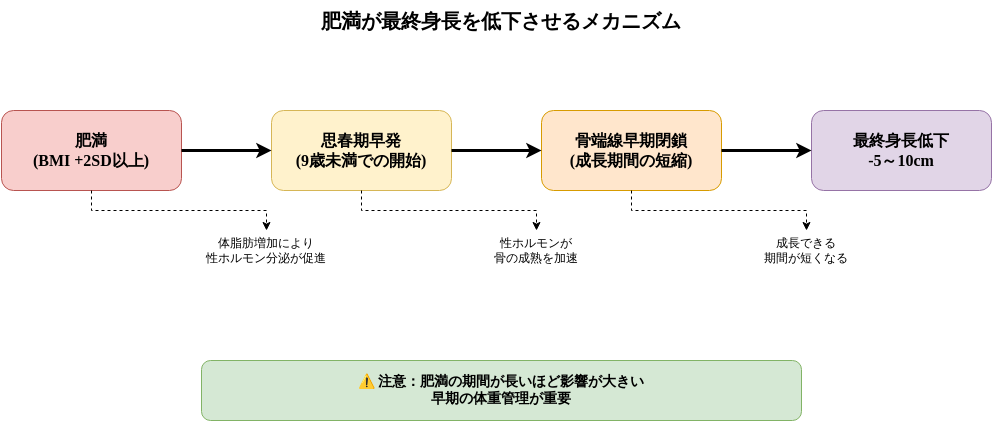

図5-1：肥満が身長を低くするメカニズム

#### メカニズム1：思春期が早まる

これが最も重要なメカニズムです。

**科学的事実**：

- 肥満児は体脂肪からのレプチン（ホルモン）分泌が増加します
- レプチンが視床下部を刺激し、思春期開始を促します
- 思春期が早く始まる → 急激な成長スパート → 骨端線の早期閉鎖 → 最終身長が低くなる

**具体例**：

- 標準体重の男子：11歳で思春期開始 → 17歳まで成長 → 最終身長172cm
- 肥満の男子：9歳で思春期開始 → 15歳で成長停止 → 最終身長167cm
- → **5cmの差**が生まれる

#### メカニズム2：成長ホルモン分泌が低下する

**医学的データ**：

- 肥満児は血中成長ホルモン（GH）濃度が低い
- インスリン抵抗性がGH分泌を抑制
- GHは骨の成長に不可欠なため、分泌低下は直接的に成長を阻害

#### メカニズム3：IGF-1軸の異常

**詳細**：

- 肥満 → インスリン抵抗性
- インスリン抵抗性 → IGF-1（成長に直接関わる因子）のシグナル異常
- → 成長障害

### 医学的エビデンス

多数の疫学研究により確立された事実：

**研究データ**：

- 肥満児の最終身長は、平均より有意に低い傾向
- 肥満による思春期早発は、最終身長を平均**5～10cm低下**させる
- 早期介入（肥満改善）により、この影響を軽減可能

## 5-2. わが子は大丈夫？肥満チェック

### BMIパーセンタイルの見方

小児の肥満判定は、大人のBMIとは異なる基準を使います。年齢と性別ごとの「BMIパーセンタイル」で評価します。

**基本の判定基準**：

- **正常範囲**：5～85パーセンタイル
- **過体重**：85～95パーセンタイル
- **肥満**：95パーセンタイル以上

[figure not shown]

図5-2：年齢別BMIチェック表（10～12歳男子）

### 年齢別の具体的なBMI基準（男子）

母親が一番気になるのは「うちの子は大丈夫？」という点でしょう。以下に、具体的な数値をお示しします。

#### 10歳男子の基準

**身長140cm、体重のパターン**：

| 体重 | BMI | 判定 | アクション |
| --- | --- | --- | --- |
| 35kg | 17.9 | 正常 | ✓ 現状維持 |
| 38kg | 19.4 | 正常 | ✓ 現状維持 |
| 40kg | 20.4 | 要注意 | ⚠ 生活習慣の見直し |
| 42kg | 21.4 | 肥満傾向 | ⚠⚠ 改善が必要 |
| 45kg以上 | 23.0以上 | 肥満 | 🚨 医師に相談 |

**目安**：10歳男子は**BMI 20以上で要注意**、22以上は肥満傾向と考えてください。

#### 11歳男子の基準

**身長145cm、体重のパターン**：

| 体重 | BMI | 判定 | アクション |
| --- | --- | --- | --- |
| 38kg | 18.1 | 正常 | ✓ 現状維持 |
| 42kg | 20.0 | 要注意 | ⚠ 生活習慣の見直し |
| 45kg | 21.4 | 肥満傾向 | ⚠⚠ 改善が必要 |
| 48kg | 22.8 | 肥満 | 🚨 医師に相談 |
| 50kg以上 | 23.8以上 | 肥満 | 🚨 医師に相談 |

#### 12歳男子の基準

**身長150cm、体重のパターン**：

| 体重 | BMI | 判定 | アクション |
| --- | --- | --- | --- |
| 42kg | 18.7 | 正常 | ✓ 現状維持 |
| 45kg | 20.0 | 正常上限 | ⚠ 注意 |
| 48kg | 21.3 | 要注意 | ⚠ 生活習慣の見直し |
| 50kg | 22.2 | 肥満傾向 | ⚠⚠ 改善が必要 |
| 53kg以上 | 23.6以上 | 肥満 | 🚨 医師に相談 |

### 簡単BMI計算法

**計算式**：

```
BMI = 体重（kg）÷ 身長（m）÷ 身長（m）
```

**例**（11歳男子、身長145cm、体重45kg）：

```
BMI = 45 ÷ 1.45 ÷ 1.45 = 21.4
→ 肥満傾向
```

### 見た目のチェックポイント

数値だけでなく、以下の点もチェックしてください：

- お腹がぽっこり出ている
- 首の後ろに肉がついている
- 二重あご
- 太ももの内側がこすれる
- Tシャツの上から脇腹の肉がはみ出る
- 同年代の子と比べて明らかに体格が大きい

これらの項目が3つ以上当てはまる場合、たとえBMIが「要注意」範囲に入っていなくても、肥満傾向の可能性があります。

## 5-3. 肥満改善の4つの柱

お子さんが肥満傾向だとわかった場合、どうすればいいのでしょうか。

大切なのは、**極端なダイエットは絶対にNG**ということです。成長期の子どもの食事を極端に制限すると、かえって成長障害を招きます。

では、何をすればいいのか。以下の「4つの柱」を実践してください。

### 柱1：清涼飲料水を完全に止める（最重要）

これが**最も重要**で、**最も効果的**な対策です。

#### なぜ清涼飲料水が問題なのか

**具体的な数値**：

- コーラ500ml：砂糖約50g（角砂糖約12個分）
- スポーツドリンク500ml：砂糖約30g（角砂糖約7個分）
- 果汁ジュース500ml：砂糖約50g（角砂糖約12個分）

**問題点**：

- 液体の糖分は吸収が速く、血糖値が急上昇
- 血糖値の急上昇 → インスリン過剰分泌 → 脂肪蓄積
- 満腹感が得られず、飲みすぎる

#### 具体的な対処法

**ステップ1：家から完全に排除**

- 冷蔵庫に清涼飲料水を置かない
- 「1日1本だけ」は失敗します
- 物理的にアクセスできない環境を作る

**ステップ2：代替飲料を用意**

- 水（常温または冷水）
- 麦茶（無糖）
- ほうじ茶（無糖）
- 炭酸水（無糖）←炭酸好きな子への代替
- レモン水（砂糖なし）

**ステップ3：学校・外出時の対策**

- 水筒を持たせる（中身は麦茶or水）
- 小遣いで買わせない
- コンビニでの買い食いを禁止

**母親の実体験**： 「最初の1週間は『喉が渇いた』『ジュース飲みたい』と言われました。でも、家に置かない、買わないを徹底したら、2週間で慣れました。3ヶ月後、体重が3kg減り、BMIが正常範囲に入りました。」（11歳男子の母）

### 柱2：間食をスナック菓子から果物・ナッツへ

#### スナック菓子の問題点

- 高カロリー、高脂肪、高塩分
- 栄養素がほとんどない
- 満腹感が得られず、食べ過ぎる

#### 推奨する間食（おやつ）

**OK の間食**：

- ヨーグルト（無糖または低糖）
- チーズ
- ナッツ類（アーモンド、くるみ）※食べ過ぎ注意
- 果物（りんご、バナナ、みかん）
- おにぎり（小さめ1個）
- 煮干し、小魚
- ゆで卵

**NG の間食**：

- ポテトチップス
- チョコレート菓子
- クッキー、ビスケット
- アイスクリーム
- カップ麺

#### 実践のコツ

**コツ1：家に置かない**

- スナック菓子を買わない
- あると食べてしまうので、物理的に排除

**コツ2：カットフルーツを常備**

- 週末にりんごやバナナを買っておく
- 「すぐ食べられる」状態にしておく

**コツ3：少量ずつ提供**

- ナッツは1日10～15粒程度
- チーズは1日1～2切れ
- 食べ過ぎ防止

### 柱3：ファストフードは月2回以下

#### ファストフードの問題点

**具体的なカロリー**：

- ハンバーガーセット（バーガー+ポテトM+ドリンクM）：約1,000kcal
- 10歳男子の1日必要カロリー：約1,800～2,000kcal
- → 1食で1日の半分以上のカロリーを摂取

**問題点**：

- 高カロリー、高脂肪、高塩分
- 野菜がほとんど摂れない
- 栄養バランスが悪い

#### 実践ルール

**ルール1：頻度を制限**

- 月2回以下に制限
- 「特別な日」のみ許可（誕生日、お祝いなど）

**ルール2：メニューを工夫**

- ポテトをサラダに変更
- ドリンクは水または無糖のお茶
- セットメニューではなく、単品で注文

**ルール3：家族全員で守る**

- 親だけファストフードを食べて、子どもに我慢させるのは困難
- 家族全員で健康的な食生活を実践

### 柱4：運動時間を増やす

#### 目標運動時間

**10～12歳男子の推奨運動時間**：

- 1日最低**60分以上**
- 中～高強度の活動を含む

#### 具体的な運動プラン

**平日（放課後）**：

- 外遊び：30分
- 縄跳び：10分
- または、スポーツクラブ：60分

**週末**：

- 家族でサイクリング、ハイキング、公園遊び：90分以上

#### 運動嫌いな子への対処法

**対処法1：無理強いしない**

- 楽しくないと続かない
- 好きなスポーツを見つける

**対処法2：家族で一緒に**

- 親も一緒に体を動かす
- 「運動」ではなく「遊び」として

**対処法3：ゲーム感覚で**

- 縄跳びの回数を記録
- 歩数計アプリで競争
- 達成したらシールを貼る

**対処法4：通学・生活の中で**

- エレベーターではなく階段
- 近所の買い物は歩いて
- 学校まで歩く（可能なら）

## 5-4. 極端なダイエットは絶対NG

### なぜ極端なダイエットがダメなのか

お子さんが肥満だとわかると、「すぐに痩せさせなきゃ！」と焦る気持ちはよくわかります。しかし、**成長期の極端な食事制限は、かえって成長障害を招きます**。

#### 問題点1：成長に必要な栄養素が不足

**科学的事実**：

- タンパク質、カルシウム、ビタミンD、亜鉛などは骨の成長に必須
- 食事を極端に減らすと、これらの栄養素が不足
- → 身長の伸びが止まる、最終身長が低くなる

#### 問題点2：リバウンドのリスク

**よくあるパターン**：

1. 極端に食事を制限 → 一時的に体重減少
2. 我慢の限界 → ドカ食い
3. 体重が元に戻る、またはそれ以上に増える
4. → 悪循環

#### 問題点3：心理的ストレス

- 食事制限 → ストレス
- ストレス → 成長ホルモン分泌低下
- → 身長の伸びに悪影響

### 正しいアプローチ：「体重を減らす」より「身長が伸びる間に体重維持」

成長期の子どもの肥満対策で重要なのは、「**体重を減らすこと**」ではなく、「**身長が伸びる間に体重を維持すること**」です。

**具体例**：

- 11歳男子、身長145cm、体重48kg、BMI 22.8（肥満）
- 目標：体重を減らすのではなく、体重48kgを維持
- 1年後、身長が150cmに伸びる → 体重48kg、BMI 21.3（要注意レベルに改善）
- 2年後、身長が155cmに伸びる → 体重48kg、BMI 20.0（正常範囲）

### 栄養バランスは守る

体重をコントロールしながらも、以下の栄養素は必ず確保してください：

#### 必須栄養素のチェックリスト

**タンパク質（1日40～50g）**：

- 朝食：卵1個（6g）、納豆1パック（8g）
- 昼食：肉or魚（20g）
- 夕食：肉or魚（25g）
- 合計：約60g ✓

**カルシウム（1日700～1000mg）**：

- 牛乳200ml（220mg）
- ヨーグルト100g（120mg）
- 小魚、豆腐、小松菜など（300～400mg）
- 合計：約640～740mg ✓

**ビタミンD、亜鉛、鉄**：

- 魚（サケ、サバなど）：週3回
- レバー、赤身肉：週2回
- 納豆、卵：ほぼ毎日

### やってはいけないダイエット

**NG例**：

- ❌ 朝食を抜く
- ❌ 炭水化物を完全にカット
- ❌ 夕食を抜く
- ❌ 極端な低カロリー食（1日1,000kcal以下など）
- ❌ 単品ダイエット（りんごだけ、バナナだけなど）

**理由**：

- 成長に必要なエネルギーと栄養素が不足
- 身長の伸びが止まる
- リバウンドのリスク

## 5-5. 実践！1週間の肥満改善プラン

### 月曜日から始める改善プラン

#### Day 1（月曜日）：現状把握と宣言

**やること**：

- 朝、身長・体重を測定
- BMIを計算
- 冷蔵庫の清涼飲料水を処分
- スナック菓子を処分
- 家族会議：「これから健康的な生活を始める」と宣言

#### Day 2～7：4つの柱を実践

**毎日のチェックリスト**：

**食事**：

- 清涼飲料水を飲まない（水、麦茶のみ）
- 間食はヨーグルト、果物、チーズのみ
- ファストフードなし
- 3食バランスの取れた食事

**運動**：

- 60分以上の運動（外遊び、縄跳び、スポーツクラブなど）

#### 1週間後の評価

**測定**：

- 体重測定（同じ時間、同じ条件で）
- BMI計算

**振り返り**：

- できたこと：
- できなかったこと：
- 障害となったもの：
- 次週への改善策：

### よくある失敗と対処法

#### 失敗例1：「子どもが清涼飲料水を欲しがって泣く」

**対処法**：

- 最初の1週間が山場
- 「健康のため」と説明
- 代わりに炭酸水（無糖）を提供
- 2週間で慣れる

#### 失敗例2：「学校の友達がお菓子を食べているのを見て欲しがる」

**対処法**：

- 家では徹底的に制限
- 友達との付き合いで少量食べる分には許容
- 完璧主義にならない

#### 失敗例3：「運動が嫌いで続かない」

**対処法**：

- 無理強いしない
- 楽しい運動を一緒に探す
- 家族で一緒に体を動かす
- 最低ライン：1日30分の外遊び

## 5-6. 医師に相談すべきサイン

以下の場合は、小児科医または小児内分泌専門医に相談してください：

### 緊急度：高

- BMIが25以上（著しい肥満）
- 急激な体重増加（1ヶ月で3kg以上など）
- 9歳未満で思春期の兆候（精巣増大、陰毛発生など）
- 糖尿病の症状（異常な喉の渇き、頻尿、疲労感）

### 緊急度：中

- BMIが22～25（肥満傾向が続く）
- 生活習慣の改善を3ヶ月続けても体重が減らない
- いびきがひどい、睡眠時に呼吸が止まる（睡眠時無呼吸症候群の可能性）

### 受診先

**まずは**：

- かかりつけ小児科医

**必要に応じて**：

- 小児内分泌専門医
- 小児肥満外来（一部の病院）

### Aさん（11歳男子の母）の実践レポート

**子どもの状況（開始時）**：

**悩み**：

- 「クラスで体格が一番大きい」
- 「体育の時間に走るのが遅い」
- 「このままだと思春期が早まって、身長が伸びないのでは？」

### 実践した4つの柱

**1. 清涼飲料水を完全ストップ**

- 冷蔵庫から全て処分
- 水筒に麦茶を入れて持たせる
- 最初の1週間は「喉が渇いた」と言われたが、2週間で慣れた

**2. 間食を変更**

- スナック菓子 → ヨーグルト、果物、チーズ
- 最初は「物足りない」と言われたが、徐々に慣れた

**3. ファストフードは月1回**

- 以前は週1回 → 月1回に削減
- 誕生日などの特別な日のみ

**4. 運動時間を増やす**

- サッカークラブに入会（週2回、1回90分）
- 平日は縄跳び10分 + 外遊び30分

### 3ヶ月後の結果

**測定結果**：

- 身長：150cm（+5cm伸びた）
- 体重：48kg（維持）
- BMI：21.3（要注意レベルに改善）

**6ヶ月後**：

- 身長：153cm
- 体重：49kg
- BMI：20.9（ほぼ正常範囲）

### 母親の感想

「最初は『続けられるかな』と不安でした。でも、4つの柱を徹底したら、3ヶ月で目に見える変化がありました。体重を無理に減らそうとしなかったのが良かったと思います。身長が伸びる間に体重を維持する、というアプローチが成功の鍵でした。

息子も、体が軽くなったことで走るのが速くなり、自信がついたようです。これからも健康的な生活習慣を続けていきます。」

## この章のまとめ

### 次の章へ

肥満は思春期早発の最大の原因です。次の第6章では、思春期早発そのものについて、さらに詳しく見ていきます。

「うちの子、ちょっと早いかも？」と感じたら、すぐに読んでください。早期発見、早期介入で、お子さんの最終身長を守ることができます。

# 第6章：思春期早発 - 「早すぎる」は最終身長を低くする

「うちの子、クラスで一番背が高いんです！」

10歳の息子が同級生より頭一つ高いことを、あなたは誇らしく思っているかもしれません。でも、ちょっと待ってください。

その「早い成長」、本当に喜んでいいのでしょうか？

もし、それが「思春期早発」だったとしたら――お子さんは今、クラスで一番高くても、最終的には一番低くなってしまう可能性があります。

「早すぎる成長」は、実は最終身長を奪う警告サインかもしれないのです。

この章では、思春期早発のメカニズム、見つけ方、そして対処法を詳しくお伝えします。

## 6-1. 思春期早発が身長を奪うメカニズム

### 「早い」と「高い」は違う

まず、重要な事実をお伝えします。

**思春期が早く始まる子**：

- 10歳の時点で同級生より背が高い
- 急激に成長する（年間10cm以上）
- **しかし**、骨端線が早く閉じる
- → 最終身長は低くなる

**思春期が正常な時期に始まる子**：

- 10歳の時点では平均的
- じわじわと成長する（年間5～6cm）
- 骨端線が長く開いている
- → 最終身長は高くなる

### 具体例で理解する

**ケース1：思春期早発の太郎くん**

- 9歳で思春期開始（早発）
- 9歳：身長135cm（同級生より高い）
- 10歳：145cm（+10cm、クラスで一番高い）
- 11歳：153cm（+8cm）
- 12歳：158cm（+5cm）
- 13歳：161cm（+3cm）
- 14歳：163cm（+2cm）
- **15歳：163cm（成長停止）**
- → 最終身長：163cm

**ケース2：正常な次郎くん**

- 11歳で思春期開始（正常）
- 9歳：身長130cm（平均的）
- 10歳：135cm（+5cm、平均的）
- 11歳：141cm（+6cm、思春期開始）
- 12歳：150cm（+9cm）
- 13歳：160cm（+10cm、成長スパート）
- 14歳：168cm（+8cm）
- 15歳：172cm（+4cm）
- 16歳：174cm（+2cm）
- **17歳：175cm（成長停止）**
- → 最終身長：175cm

**差：12cm**

太郎くんは、9～10歳の時点ではクラスで一番背が高かったのに、最終的には次郎くんより12cm低くなってしまいました。

### 医学的メカニズム

**正常な成長プロセス**：

1. 思春期開始
2. 性ホルモン（テストステロン）分泌増加
3. 急激な成長スパート（年間8～12cm）
4. 2～3年継続
5. 性ホルモンが骨端線を閉鎖させる
6. 成長停止

**問題点**：

- 思春期が早く始まる → 性ホルモンの分泌が早く始まる
- 急激に成長するが、骨端線の閉鎖も早い
- 成長期間が短くなる
- → 最終身長が低くなる

**データ**：

- 思春期が1年早く始まると、最終身長が平均**約5cm低くなる**
- 2年早いと、**約10cm低くなる**

## 6-2. 男子の思春期早発の基準

### 医学的定義

**思春期早発（Precocious Puberty）**：

- **男子**：9歳未満で精巣増大
- **女子**：8歳未満で乳房発達

### 男子の思春期の正常な進行

**正常な開始時期**：

- 9～14歳（平均11～12歳）

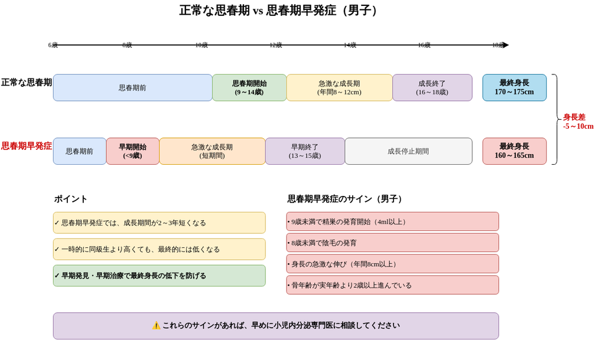

図6-1：正常な思春期vs早発思春期のタイムライン

**正常な進行順序**：

1. **精巣増大**（最初のサイン）
   - 精巣の容積が4ml以上に増大
   - これが「思春期開始」の医学的定義
2. **陰茎の発育**
   - 精巣増大から数ヶ月後
3. **陰毛発生**
   - 精巣増大から約1年後
4. **急激な身長の伸び**（成長スパート）
   - 年間10～12cm伸びる
   - 思春期開始から1～2年後にピーク
5. **声変わり**
   - 成長スパートの後期
6. **ひげ、わき毛**
   - 最後の段階

### 早発のサイン（母親がチェックすべきポイント）

#### サイン1：9歳未満での精巣増大

**確認方法**：

- 入浴時にさりげなく確認
- 小児科医に相談して確認してもらう

**注意**：

- これが最も重要なサイン
- 母親が確認しにくい場合は、医師に相談

- 入浴時に確認

#### サイン3：10歳未満での急激な身長増加

**具体的な基準**：

- 9歳4月：135cm
- 10歳4月：146cm（+11cm）
- → 要注意

#### サイン4：骨年齢が暦年齢より2歳以上進んでいる

**確認方法**：

- 小児科医で骨年齢のX線検査を受ける
- 手のひらのX線写真で判定

**例**：

- 暦年齢：10歳
- 骨年齢：12歳
- → 2歳進んでいる → 要注意

#### サイン5：9歳未満での声変わり

これは非常に明確なサインです。すぐに医師に相談してください。

### 「早発かも？」と思ったら

以下のチェックリストで確認してください：

**思春期早発チェックリスト**：

- 9歳未満で精巣が大きくなった
- 9歳未満で陰毛が生えた
- 9～10歳で年間10cm以上伸びた
- クラスで著しく背が高い（10歳の時点で）
- 声が急に低くなった（9歳未満）
- 体臭が強くなった（9歳未満）

**判定**：

- 1つでも当てはまる → 小児内分泌専門医を受診
- 2つ以上当てはまる → 早急に受診

## 6-3. 早発を防ぐ4つの生活習慣

思春期早発を完全に防ぐことはできませんが、リスクを大幅に減らすことはできます。以下の4つの生活習慣を実践してください。

### 生活習慣1：肥満を避ける（最大の予防策）

これが**最も重要**な予防策です。

**科学的根拠**：

- 肥満児は体脂肪からのレプチン分泌が増加
- レプチンが視床下部を刺激して思春期を早める
- 肥満児は平均1～2年早く思春期が始まる

**具体的な対策**： 第5章で詳しく説明した「肥満改善の4つの柱」を実践してください：

1. 清涼飲料水を完全にストップ
2. 間食を健康的なものに変更
3. ファストフードは月2回以下
4. 運動時間を増やす

**目標BMI**（再掲）：

### 生活習慣2：十分な睡眠（9～11時間）

**科学的根拠**：

- 睡眠不足は内分泌系を乱す
- 概日リズムの乱れが思春期早発のリスク因子

**推奨睡眠時間**：

- 10～13歳：9～11時間

**具体的な実践方法**： 第2章で詳しく説明した睡眠の質を高める方法を実践してください：

- 毎日同じ時間に寝る・起きる
- 就寝1時間前にデジタルデバイスを回収
- 寝室を暗く、静かに、涼しく

### 生活習慣3：スクリーンタイムを制限（1日2時間以内）

**科学的根拠**：

- ブルーライトがメラトニン分泌を抑制
- メラトニン不足が内分泌系の乱れにつながる
- 過度なスクリーンタイムが思春期早発のリスク因子

**推奨スクリーンタイム**：

- 1日2時間以内（ゲーム、スマホ、タブレット、テレビの合計）

**具体的なルール**：

- 平日：1時間以内
- 週末：2時間以内
- 就寝1時間前は完全に禁止

**実践方法**：

1. タイマーを使う
2. 時間になったら物理的に回収
3. 代替活動を提供（外遊び、読書、家族との会話）

### 生活習慣4：バランスの取れた食事

**科学的根拠**：

- 過剰な動物性脂肪摂取が性ホルモン産生を増加させる可能性
- 栄養バランスが内分泌系の正常な機能に重要

**具体的な対策**：

- ファストフード、ジャンクフードを避ける
- 野菜、果物、全粒穀物を増やす
- タンパク質は適量（1日40～50g）
- 過剰な肉食を避ける（週3～4回程度に）

## 6-4. 早発が疑われたら

### ステップ1：小児内分泌専門医を受診

**受診先**：

- 大学病院の小児科（内分泌専門）
- 地域の基幹病院の小児内分泌専門医

**初診で伝えること**：

- 思春期の兆候が見られた時期
- 身長の伸びの経緯
- 家族歴（両親の思春期開始時期）

### ステップ2：精密検査

**検査内容**：

#### 身体診察

- 精巣のサイズ測定
- 二次性徴の評価（Tanner分類）
- 身長・体重測定

#### 血液検査

- テストステロン（男性ホルモン）
- LH（黄体形成ホルモン）
- FSH（卵胞刺激ホルモン）
- IGF-1

#### 骨年齢のX線検査

- 左手のX線撮影
- 骨年齢と暦年齢の比較

#### GnRH負荷試験（確定診断）

- GnRH（性腺刺激ホルモン放出ホルモン）を注射
- 血中LH、FSHの反応を測定
- 真性早発思春期かどうかを診断

### ステップ3：診断

**真性早発思春期（中枢性）**：

- 視床下部-下垂体-性腺系が早期に活性化
- GnRH負荷試験で高反応
- 治療の対象

**偽性早発思春期（末梢性）**：

- 副腎腫瘍などが原因
- 原因疾患の治療が必要

### ステップ4：治療の検討

#### 治療適応

以下の条件を満たす場合、治療を検討：

- 真性早発思春期と診断された
- 最終予測身長が著しく低い
- 心理社会的問題がある

#### 治療方法：GnRHアゴニスト（思春期抑制治療）

**薬剤**：

- リュープロレリン（注射）
- ブセレリン（注射）

**投与方法**：

- 月1回の注射
- または、3ヶ月に1回の長期作用型注射

**治療期間**：

- 数年間（骨年齢が11～12歳に達するまで）

**効果**：

- 思春期の進行を一時的に止める
- 成長期間を延長
- 最終身長が平均**5～10cm改善**

**副作用**：

- 注射部位の痛み
- まれに、更年期様症状（ほてり、頭痛）
- 多くは軽度

#### 費用

**保険適用**：

- 真性早発思春期と診断されれば保険適用
- 小児慢性特定疾病医療費助成制度の対象
- 自己負担は月数千円程度

### ステップ5：定期的なフォローアップ

治療開始後：

- 月1回の通院
- 3～6ヶ月ごとの血液検査
- 6ヶ月ごとの骨年齢検査
- 身長測定

## 6-5. 保険適用の可能性

思春期早発と診断された場合、治療は**保険適用**となります。これは、第9章で説明する「自由診療のGH治療」とは全く異なり、医学的に必要な治療として認められています。

### 保険適用の条件

**診断基準**：

- 男子：9歳未満で精巣増大（精巣容積4ml以上）
- GnRH負荷試験で真性早発思春期と診断

**治療の必要性**：

- 最終予測身長が著しく低い
- または、心理社会的問題がある

### 費用

**通常の保険診療（3割負担）**：

- 月1回の注射：約3,000～5,000円（3割負担）
- 検査費用：約1,000～2,000円（3割負担）

**小児慢性特定疾病医療費助成制度**：

- 真性早発思春期は対象疾患
- 自己負担上限額：所得に応じて0～数千円/月
- 多くの家庭では月数千円程度の負担

**自由診療（ISS）との違い**：

- 自由診療：月10万～20万円以上、全額自己負担
- 早発思春期治療：月数千円、保険適用

## 6-6. 実際のケース：早発を早期発見、治療で改善

### Bさん（10歳男子の母）の体験談

**息子の状況（受診前）**：

- 年齢：9歳11ヶ月
- 身長：145cm（同級生より高い）
- 急激な身長の伸び：前年+11cm
- 精巣増大あり
- 陰毛発生あり

**母親の気づき**： 「息子は9歳の時点でクラスで一番背が高く、『大きくなったね』と褒められていました。でも、ふと『これって普通？』と疑問に思いました。

入浴時に体を見ると、精巣が大きくなっていて、陰毛も少し生えていることに気づきました。『まだ9歳なのに早すぎるのでは？』と思い、小児科に相談しました。」

### 受診と診断

**小児内分泌専門医を受診**：

- 身体診察：精巣容積6ml（正常は思春期前は3ml以下）
- 骨年齢：11歳6ヶ月（暦年齢より1歳7ヶ月進んでいる）
- GnRH負荷試験：高反応
- **診断**：真性早発思春期

**予測最終身長（治療しない場合）**：

- 骨年齢と身長から計算
- 予測最終身長：約165cm

### 治療

**治療方針**：

- GnRHアゴニスト（リュープロレリン）月1回注射
- 治療期間：約3年間（骨年齢が12歳に達するまで）

**費用**：

- 小児慢性特定疾病医療費助成制度を利用
- 自己負担：月約3,000円

### 経過

**治療開始後**：

- 1年目：身長148cm（+3cm）
- 2年目：身長151cm（+3cm）
- 3年目：身長154cm（+3cm、治療終了）
- 4年目（治療終了後、思春期再開）：161cm（+7cm）
- 5年目：168cm（+7cm）
- 6年目：172cm（+4cm）
- 7年目：174cm（+2cm）
- **最終身長：174cm**

**改善幅**：

- 予測最終身長：165cm
- 実際の最終身長：174cm
- **+9cm改善**

### 母親の感想

「最初は『まさかうちの子が』と思いましたが、早期に気づいて受診して本当に良かったです。治療しなければ最終身長は165cmだったと医師に言われました。

治療中は月1回の注射と通院が少し大変でしたが、息子も『背を高くするため』と理解して頑張ってくれました。最終的に174cmまで伸びて、医師には『よく頑張りましたね』と言われました。

他のお母さんたちにも伝えたいのは、『子どもが早く大きくなることは必ずしも良いことではない』ということです。思春期が早すぎると感じたら、すぐに専門医に相談してほしいです。」

## 6-7. よくある質問

### Q1: 思春期が早いかどうか、どうやって判断すればいいですか？

**A:** 以下のサインに注目してください：

- 9歳未満で精巣が大きくなる
- 9歳未満で陰毛が生える
- 9～10歳で年間10cm以上伸びる
- クラスで著しく背が高い

1つでも当てはまれば、小児内分泌専門医を受診してください。

### Q2: 精巣のサイズをどうやって確認すればいいですか？

**A:**

- 入浴時にさりげなく確認
- 医学的には「オーキドメーター」という器具で測定
- 母親が確認しにくい場合は、小児科医に相談

### Q3: 「背が高い」のと「思春期早発」の違いは？

**A:**

- **単に背が高い**：身長は高いが、思春期の兆候（精巣増大、陰毛など）はない
- **思春期早発**：身長が高い + 思春期の兆候がある + 骨年齢が進んでいる

身長が高いだけなら問題ありません。思春期の兆候があるかどうかが重要です。

### Q4: 治療すれば必ず身長が伸びますか？

**A:** 早期発見、早期治療であれば、最終身長を平均5～10cm改善できる可能性があります。ただし、すでに骨端線が閉じかけている場合は効果が限定的です。

### Q5: 治療の副作用は？

**A:** 一般的には軽度です：

- 注射部位の痛み
- まれに、更年期様症状（ほてり、頭痛）
- ほとんどの子どもは問題なく治療を継続できます

### Q6: 治療費は高いですか？

**A:** 保険適用 + 小児慢性特定疾病医療費助成制度を利用すれば、月数千円程度です。自由診療のGH治療（月10万～20万円）とは全く異なります。

## この章のまとめ

### 覚えておくべき5つのポイント

1. **「早い成長」は要注意**
   - 9～10歳でクラスで一番高い → 思春期早発の可能性
   - 早く始まると、最終身長は低くなる
   - 1年早いと約5cm、2年早いと約10cm低くなる
2. **男子の早発の基準**
   - 9歳未満で精巣増大
   - 9歳未満で陰毛発生
   - 10歳未満で急激な身長増加（年間10cm以上）
3. **予防は可能**
   - 肥満を避ける（最重要）
   - 十分な睡眠（9～11時間）
   - スクリーンタイムを制限（1日2時間以内）
   - バランスの取れた食事
4. **早期発見、早期治療が鍵**
   - 疑ったらすぐに小児内分泌専門医を受診
   - GnRH負荷試験で診断
   - 思春期抑制治療で最終身長を5～10cm改善可能
5. **保険適用で経済的負担は軽い**
   - 真性早発思春期は保険適用
   - 小児慢性特定疾病医療費助成制度の対象
   - 月数千円程度の負担

### 次の章へ

肥満と思春期早発は、目に見える身長の敵でした。しかし、目に見えない敵もあります。次の第7章では、「ストレス」が身長に与える影響を見ていきます。

愛情遮断症候群という衝撃的な事例から、日常的なストレスまで――母親が知っておくべき「心と身長の関係」を詳しく解説します。

# 第7章：ストレス - 見えない身長の敵

「うちの子、ちゃんと寝て、ちゃんと食べて、運動もしているのに、なぜか身長が伸びない…」

もしかしたら、その原因は「ストレス」かもしれません。

ストレスと身長。一見、関係ないように思えるかもしれません。でも、医学的には明確な関連性が証明されています。

極度のストレスは、成長ホルモンの分泌を止め、子どもの成長を完全に停止させることさえあります。そして、そのストレスの最大の原因が、時に「家庭環境」であることも――。

この章では、少し重いテーマですが、母親として知っておくべき「ストレスと身長の関係」を、科学的根拠に基づいて詳しくお伝えします。

## 7-1. ストレスが身長を奪うメカニズム

### 愛情遮断症候群：極度のストレスで成長が止まる

**愛情遮断症候群（Psychosocial Short Stature）**は、親からの愛情不足や極度の心理社会的ストレスにより著しい成長障害をきたす状態です。驚くべきことに、この子どもたちを愛情ある環境に移すと、成長ホルモン分泌が正常化し、劇的に成長が回復します。つまり、**ストレスそのものが成長を止めていた**のです。

これは極端な例ですが、日常的なストレスでも成長に悪影響を及ぼします。

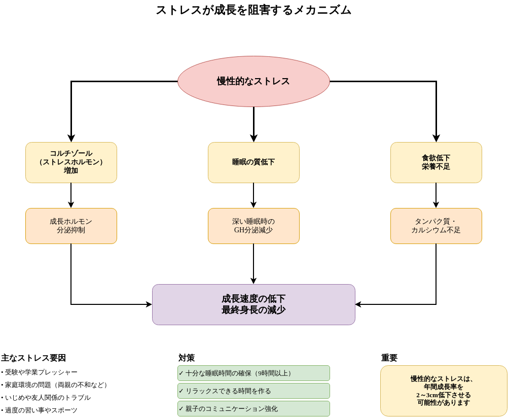

図7-1：ストレスが成長を阻害するメカニズム

#### メカニズム1：視床下部-下垂体系への影響

**科学的メカニズム**：

1. 慢性的なストレス
2. → 視床下部-下垂体-副腎系（HPA軸）の過活動
3. → コルチゾール（ストレスホルモン）の過剰分泌
4. → コルチゾールが成長ホルモン分泌を抑制
5. → 成長障害

**わかりやすく言うと**：

- ストレスを感じる → 体が「今は成長している場合じゃない、生き延びることが優先」と判断
- → 成長ホルモンの分泌を減らす
- → 身長が伸びない

#### メカニズム2：睡眠障害

**メカニズム**：

- ストレス → 睡眠の質低下、不眠
- → 深睡眠の減少
- → 成長ホルモン分泌減少（GHの70～80%は深睡眠時に分泌）
- → 成長障害

#### メカニズム3：食欲不振

**メカニズム**：

- ストレス → 食欲低下
- → 栄養不足（タンパク質、カルシウムなど）
- → 成長に必要な材料が不足
- → 成長障害

#### メカニズム4：エピジェネティックな影響

**最新の研究**：

- 強いストレス → 遺伝子発現の変化（DNAメチル化など）
- → 脳の発達や身体機能に長期的な影響
- → 成長にも影響する可能性

## 7-2. 10～12歳男子の具体的なストレス源

お子さん（10～12歳男子）が経験する主なストレス源を見ていきましょう。

### ストレス源1：学業のプレッシャー

**具体例**：

- テスト、成績へのプレッシャー
- 中学受験の準備
- 塾の宿題の多さ
- 親の過度な期待
- 「〇〇中学に入らなきゃダメ」というプレッシャー

**子どもの心理**：

- 「期待に応えられない自分はダメだ」
- 「勉強ができない自分は価値がない」
- → 自己肯定感の低下
- → ストレス

**サイン**：

- 勉強の話をすると表情が曇る
- テストの日に腹痛や頭痛を訴える
- 成績が下がると極端に落ち込む

### ストレス源2：友人関係・いじめ

**具体例**：

- いじめ（言葉の暴力、仲間はずれ、暴力）
- 友達とのトラブル
- 孤立、居場所がない
- SNSでのトラブル（高学年になると）

**子どもの心理**：

- 「学校に行きたくない」
- 「誰も自分のことをわかってくれない」
- 「友達がいない自分は変だ」
- → 深刻なストレス

**サイン**：

- 学校に行きたがらない
- 友達の話をしなくなる
- 持ち物がなくなる、壊れる
- 表情が暗い、元気がない

### ストレス源3：習い事・塾の過密スケジュール

**具体例**：

- 塾3つ + 習い事2つ
- 平日は毎日塾か習い事
- 週末も習い事やテスト
- 自由時間がない

**子どもの心理**：

- 「疲れた」
- 「休みたい」
- でも「親が期待してるから言えない」
- → 慢性的な疲労とストレス

**サイン**：

- いつも疲れている
- 習い事に行く前に体調不良を訴える
- 「休みたい」と言う
- 無気力

### ストレス源4：家庭内の不和（親の喧嘩）

**具体例**：

- 両親の喧嘩を見る・聞く
- 離婚の話を聞く
- 家庭内の冷たい雰囲気
- 経済的な問題（親が「お金がない」と言う）

**子どもの心理**：

- 「両親が離婚するのでは」と不安
- 「自分のせいかも」と罪悪感
- 「家にいたくない」
- → 深刻な心理的ダメージ

**サイン**：

- 家での会話が減る
- 部屋に閉じこもる
- 親の顔色を異常に気にする
- 親の喧嘩の後、体調不良を訴える

### ストレス源5：身長のことでのいじめ・コンプレックス

**具体例**：

- 「チビ」「低い」と言われる
- クラスで前から2番目
- スポーツで不利
- 「自分は小さい」というコンプレックス

**悪循環**：

- 身長が低い → ストレス → 成長ホルモン分泌低下 → さらに身長が伸びない
- この悪循環を断ち切ることが重要

## 7-3. 母親ができる3つのストレス対策

では、母親として何ができるのでしょうか。以下の3つの対策を実践してください。

### 対策1：無条件の愛情を言葉と態度で示し、話を聞く

これが**最も重要**です。子どもにとって最も重要なのは、「**自分は愛されている**」という安心感です。この安心感が、すべてのストレスへの防御壁となります。

#### 具体的な実践方法

**毎日のスキンシップと言葉がけ**：

- 朝「おはよう」のハグ、夜「おやすみ」のハグ
- 「愛してるよ」「大好きだよ」と直接伝える
- 結果ではなく努力を褒める（「一生懸命勉強したね」）
- 存在そのものを肯定する（「あなたがいてくれるだけで嬉しい」）

**1日15分の「特別な時間」**：

- スマホを置き、目を見て話を聞く
- 最後まで遮らず、共感を示す（「そうだったんだね」「つらかったね」）
- 子どもは「解決策」より「聞いてもらうこと」を求めている場合が多い

**避けるべき対応**：

- ❌ 「100点取ったら褒めてあげる」（条件付きの愛情）
- ❌ スマホを見ながら聞く、話を遮る

### 対策2：比較せず、過度な期待をかけない

親の過度な期待は、子どもにとって大きなストレスです。

**避けるべき言葉**：

- ❌ 「お兄ちゃんはできたのに」（きょうだいとの比較）
- ❌ 「〇〇君はもっと高い点数だよ」（他人との比較）
- ❌ 「このままじゃダメな大人になるよ」（脅し）

**推奨する言葉**：

- ✅ 「前より良くなったね」（過去の本人と比較）
- ✅ 「一生懸命やったね」（努力を認める）
- ✅ 「成績に関係なく、あなたを愛してるよ」（無条件の愛情）

### 対策3：スケジュールを詰め込みすぎない

過密スケジュールは、慢性的な疲労とストレスを生みます。

**優先順位**：

1. **睡眠**（9～11時間）：最優先
2. **学校**：必須
3. **自由時間**：重要
4. **習い事・塾**：優先度を検討

**見直しのポイント**：

- 習い事・塾を減らす（本当に必要なものだけ残す）
- 週に1～2日は完全オフ日を作る
- 就寝時刻を守れるスケジュールにする
- 自由時間（ぼーっとする時間）を確保

**具体例**：塾3つ→1つに絞る、習い事3つ→1～2つに減らす

**重要**：「他の子はもっと頑張ってる」と不安になるかもしれませんが、**睡眠とストレスフリーな時間の方が、長期的には重要**です

## 7-4. いじめが疑われる場合

いじめは、子どもにとって最も深刻なストレス源の一つです。早期発見、早期介入が重要です。

### サインの見つけ方

**身体的サイン**：

- 学校に行きたがらない（朝、腹痛や頭痛を訴える）
- 食欲不振
- 睡眠障害（眠れない、悪夢）
- 体重減少
- 原因不明のあざや傷

**精神的・行動的サイン**：

- 表情が暗い、元気がない
- 友達の話をしなくなる
- 成績が急激に下下
- イライラ、攻撃性の増加
- 引きこもり、無気力
- 持ち物がなくなる、壊れる
- 自己肯定感の低下（「自分はダメだ」と言う）

### 親の対応（ステップバイステップ）

#### ステップ1：まず子供の話を聞く

**基本姿勢**：

- 責めない、叱らない
- 「あなたは悪くない」と伝える
- 最後まで話を聞く
- 共感を示す

**避けるべき対応**：

- ❌ 「やり返しなさい」
- ❌ 「あなたにも原因があるんじゃない？」
- ❌ 「気にしないで」
- ❌ 「大げさに騒がない」

#### ステップ2:学校に相談

**相談先**：

1. **まず担任教師**
   - 事実を冷静に伝える
   - 感情的にならない
   - 具体的な対策を求める
2. **改善されない場合**：
   - スクールカウンセラー
   - 学年主任
   - 教頭、校長

**相談時のポイント**：

- いつ、どこで、誰に、何をされたかを具体的に
- 子どもの様子の変化を伝える
- 学校にどう対応してほしいかを明確に

#### ステップ3：専門家に相談

**相談先**：

- 小児科医（身体的症状がある場合）
- 児童精神科医（精神的ダメージが大きい場合）
- 教育相談センター
- いじめ相談ホットライン

#### ステップ4：子供の安全を最優先

**重要な原則**：

- 無理に学校に行かせない
- 一時的に休ませることも選択肢
- 転校も選択肢の一つ
- 子どもの命と心の健康が最優先

### 「身長のことでいじめられている」場合の対処

**特有の問題**：

- 「チビ」「低い」などのからかい
- スポーツで不利、劣等感
- 身長は簡単に変えられない → 子どもの無力感

**対処法**：

**1. 自己肯定感を育てる**：

- 「身長は個性の一つ」と伝える
- 身長以外の強みを見つけて伸ばす
- 低身長でも活躍している人の例を示す

**2. 医学的評価**：

- 小児内分泌専門医を受診
- 保険適用の治療の可能性を確認
- 自由診療の検討（経済的に可能なら）

**3. カウンセリング**：

- 心理的サポートを受ける
- 学校のスクールカウンセラー
- 必要なら児童精神科医

**4. 学校への働きかけ**：

- いじめとして対処してもらう
- 身長での差別は許されないことを教育してもらう

## 7-5. ストレスサインの早期発見チェックリスト

以下のチェックリストで、定期的にお子さんの様子を確認してください。

### 主なストレスサイン

- 頭痛、腹痛を頻繁に訴える（特に朝）
- 食欲不振または過食、睡眠障害
- イライラ、怒りやすい、引きこもり
- 成績の急激な低下
- 表情が暗い、笑わない
- 学校に行きたがらない

**3個以上**：対策1～3を実践し、状況を注意深く観察 **5個以上**：専門家（小児科医、スクールカウンセラー）に相談

### 緊急受診が必要なサイン

- 「死にたい」「消えたい」と言う
- 自傷行為
- 極度の引きこもり（1週間以上学校を休む）
- → **直ちに児童精神科医を受診**

## 7-6. 実際のケース：ストレス改善で身長が伸びた

### Cさん（12歳男子の母）の体験談

**息子の状況（改善前）**：身長142cm、1年間で2cmしか伸びず（通常5～6cm）。栄養・睡眠は十分だが、検査では身体的に問題なし。

**医師の指摘**：「お子さんの表情が暗いですね。ストレスはありませんか？」

**ストレスの発見**：中学受験の準備で塾3つ、平日は毎日塾、週末も塾とテスト。息子は「疲れた」「休みたい」と訴えていたが、母親が「受験のため」と無視していた。

**改善策**： 1. 塾を3つ→1つに減らした 2. 週2日は完全オフ日を確保 3. プレッシャーを減らし、無条件に愛情を示した 4. 寝る前に15分、話を聞く時間を作った

**母親の感想**：「『息子のため』と思ってやっていたことが、息子を追い詰めていました。塾を減らしてリラックスできる時間を作ったら、みるみる身長が伸びました。身長も大切ですが、息子の笑顔の方がもっと大切です。」

## この章のまとめ

### 覚えておくべき5つのポイント

1. **ストレスは成長ホルモン分泌を抑制する**
   - コルチゾール（ストレスホルモン）が成長ホルモンを抑制
   - 極度のストレスは成長を完全に止めることもある
2. **10～12歳男子の主なストレス源**
   - 学業のプレッシャー、中学受験
   - 友人関係、いじめ
   - 習い事・塾の過密スケジュール
3. **母親ができる3つの対策**
   - 無条件の愛情を示し、話を聞く（最重要）
   - 比較せず、過度な期待をかけない
   - スケジュールを詰め込みすぎない
4. **いじめは早期発見、早期介入**
   - サインを見逃さず、子どもの話を聞く
   - 学校・専門家に相談し、子どもの安全を最優先
5. **ストレス改善で身長が伸びる**
   - 生活習慣が完璧でも、ストレスで身長が伸びないことがある
   - ストレスを減らすだけで成長が回復することも

### 最後に：母親へのメッセージ

この章は、少し重いテーマでした。もしかしたら、「自分の子育ては間違っていたのか」と不安になった方もいるかもしれません。

でも、大切なのは**これから**です。

**完璧な親なんていません。**

大切なのは：

- 子どもの変化に気づくこと
- 子どもの声に耳を傾けること
- 間違いに気づいたら、修正すること
- 「子どものため」と思ってやっていることが、本当に子どものためになっているか、時々立ち止まって考えること

あなたがこの本を手に取り、この章を読んでいること自体が、お子さんを深く愛している証拠です。

その愛情を、言葉と態度で、毎日お子さんに伝えてあげてください。

### 次の章へ

第1部から第3部まで、睡眠、栄養、運動、そして身長を奪う3つの敵（肥満、思春期早発、ストレス）について学んできました。

ここまでの内容を実践すれば、お子さんの遺伝的な身長ポテンシャルを最大限に引き出すことができます。

しかし、それでも「もっと伸ばしたい」「医学的な介入を検討したい」と思う方もいるでしょう。

次の第4部では、「医学的介入という選択肢」――成長ホルモン治療について、詳しく見ていきます。

保険診療と自由診療の違い、費用、効果、リスク、そして「やるべきか、やらざるべきか」の判断基準まで、すべてをお伝えします。

# 第8章：成長ホルモン治療の基礎知識

この章では、成長ホルモン治療という選択肢について、基礎から理解していきます。

あなたがこの章を読んでいるのは、おそらく第2部までの生活習慣改善を試みた後、あるいは、最初から医学的介入を検討されているからだと思います。

どちらの場合でも、ここから先は「覚悟」が必要な領域です。

## 8-1. 成長ホルモン治療とは

### 治療の本質

成長ホルモン（GH：Growth Hormone）治療とは、**人工的に成長ホルモンを注射で体内に補充する医療行為**です。

本来、成長ホルモンは脳の下垂体から分泌され、肝臓でIGF-1（インスリン様成長因子-1）に変換され、骨端線に作用して骨を伸ばします。

成長ホルモン治療は、この自然なプロセスを**外部から強化または補充する**ものです。

### 絶対条件

成長ホルモン治療が有効なのは、**骨端線が開いている間だけ**です。

骨端線が閉じてしまったら、どれだけ高額な治療を受けても、身長は1mmも伸びません。

男の子の骨端線は平均17～19歳で閉じます。つまり、**時間は限られています**。

## 8-2. 保険診療（参考情報）

成長ホルモン治療には、大きく分けて2つのルートがあります。

1. **保険診療**：国が認めた疾患に対する治療
2. **自由診療**：保険適用外だが、効果が期待できる場合の自費治療

まずは保険診療について説明しますが、はっきり言います：**ほとんどの子供は該当しません**。

### 保険適用の対象疾患

保険診療でGH治療が受けられるのは、以下のような場合です。

#### 成長ホルモン分泌不全性低身長症（GHD）

- 成長ホルモンの分泌が著しく不足している状態
- **診断基準**：GH分泌刺激試験（入院検査）で血中GH頂値が6 ng/ml未満
- 身長が-2SD以下

#### SGA性低身長症

- 在胎週数に対して小さく生まれた（出生時の身長・体重が基準以下）
- 2歳または3歳までに身長が-2SDに追いつかない

#### その他の疾患

- ターナー症候群
- プラダー・ウィリー症候群
- 慢性腎不全
- 軟骨異栄養症
- ヌーナン症候群

### 保険診療の費用

公的医療保険および「小児慢性特定疾病医療費助成制度」により、自己負担は**月数千円程度**に抑えられます。

### 保険診療の効果

年間6～12cm伸びることもあります（もちろん個人差があります）。

### なぜほとんどの子供は該当しないのか

最大のハードルは、**GH分泌刺激試験の基準**です。

GH分泌刺激試験とは、入院して薬剤（インスリン、アルギニン、L-DOPAなど）を投与し、成長ホルモンの分泌を刺激して、血中のGH濃度を測定する検査です。

**診断基準：GH頂値が6 ng/ml未満**

この基準を満たすのは、本当に成長ホルモンの分泌が不足している子供だけです。

## 8-3. 「ギリギリ満たさない」現実

ここに、多くの母親が直面する残酷な現実があります。

### ケース例

- 息子の身長：135cm（10歳、-2.0 SD）
- クラスで前から2番目
- 血液検査でIGF-1が低値
- 骨年齢の遅れあり
- 母親も父親も身長が低い（遺伝的要因）

この状態で小児内分泌専門医を受診し、入院してGH分泌刺激試験を受けます。

**結果：GH頂値 6.5 ng/ml**

基準は「6 ng/ml未満」。

わずか0.5の差で、**保険適用外**。

この子は医学的に「成長ホルモン分泌不全症」とは診断されません。

### 母親の心境

「6.5って、ほぼ6じゃないですか！なぜダメなんですか？」

医師は言います。

「基準は基準です。お子さんは正常範囲です。治療の必要はありません。」

でも、息子は今日もクラスで前から2番目。

遺伝的にこのままでは最終身長は160cm前後の予測。

「正常範囲」と言われても、母親の不安は消えません。

## 8-4. 自由診療が対象とする「特発性低身長症（ISS）」

保険適用の基準を満たさない、しかし明らかに低身長である子供たち。

この層を対象としているのが、**自由診療のGH治療**です。

### 特発性低身長症（ISS：Idiopathic Short Stature）とは

**定義**：

- 明らかな病気はないが、著しく身長が低い状態
- 成長ホルモンの分泌は正常（保険基準を満たさない）
- 染色体異常や骨の疾患などの器質的疾患も除外されている
- 原因が特定できない低身長

**米国の基準**：

- 身長が-2.25 SD以下

**日本の状況**：

- 明確な統一基準なし
- クリニックによって対象範囲が異なる
- -2SD以上でも治療可能とするクリニックもある

### 米国FDA承認の意味と限界

2003年、米国FDA（食品医薬品局）は、ISSに対するGH治療を承認しました。

これは成長ホルモン治療の歴史における**パラダイムシフト**でした。

従来：「ホルモン欠乏」という病気を治療する ↓ FDA承認：「身長の低さそのもの」を治療対象として認める

しかし、ここには重要な文脈があります。

**米国内でも意見は分かれている**：

- **FDA（規制当局）**：ISSを承認
- **米国小児内分泌学会（PES）**：全員へのルーチン使用には**反対**

米国の専門家集団は、「身長≤-2.25 SDのISS児全員に自動的に治療すべき」とは考えていません。

彼らが推奨するのは、「**共有意思決定（shared decision-making）**」です。

つまり、個々の子供の状況、家族の価値観、リスクとベネフィットを十分に議論した上で、慎重に判断すべき、という立場です。

### 日本小児内分泌学会の慎重な姿勢

日本小児内分泌学会（JSPE）は、ISSに関する診療ガイドラインを策定していません。

これは何を意味するか？

**積極的に推奨もせず、明確に否定もせず、「適正使用」を要請する**という、極めて慎重な姿勢です。

学会がガイドラインを作らないのは、以下のような懸念があるからだと考えられます：

1. 医学的必要性の判断が困難
2. 高額な費用対効果の問題
3. 「疾患」と「正常の多様性」の倫理的境界線が不明確

## 8-5. 保険診療 vs 自由診療：根本的な違い

|  | 保険診療 | 自由診療 |
| --- | --- | --- |
| **対象** | GHD、SGA、ターナー症候群など | ISS（特発性低身長症） |
| **GH分泌** | 著しく不足 | 正常範囲 |
| **医学的根拠** | ホルモン欠乏の「補充療法」 | 正常な内分泌系への「増強」 |
| **費用** | 月数千円（公費助成） | 月10～30万円（全額自己負担） |
| **日本の学会** | 推奨（ガイドラインあり） | 慎重（ガイドラインなし） |
| **治療の性質** | 疾患治療 | 選択的医療（QOL向上目的） |

### 根本的な問い

保険診療は、「不足しているホルモンを補う」という明確な医学的正当性があります。

一方、自由診療は、「正常な子供の成長をさらに促進する」という介入です。

これは治療すべき「疾患」なのか、それとも正常範囲の「多様性」なのか？

この問いに、医学界も明確な答えを出せていません。

## 8-6. 自由診療を検討する前に：絶対に確認すべきこと

もしあなたが自由診療を検討しているなら、**必ず次の手順を踏んでください**。

### ステップ1：小児内分泌専門医による精密検査

自由診療クリニックに行く**前に**、まず大学病院または地域基幹病院の小児内分泌専門医を受診してください。

**なぜか？**

自由診療クリニックは、商業的インセンティブがあります。保険適用の可能性を十分に確認せずに、自費治療を勧められる可能性があります。

専門医による精密検査を受けることで：

- 保険適用の可能性を徹底的に確認
- 他の治療可能な疾患（甲状腺機能低下症など）を除外
- 客観的な診断とアドバイスを得る

### ステップ2：GH分泌刺激試験

入院して、2種類以上のGH分泌刺激試験を実施します。

もし頂値が6 ng/ml未満であれば、保険適用の可能性があります。

「6.1 ng/mlだった」という場合でも、試験結果には日間変動があります。別の専門医でセカンドオピニオンを取得する価値があります。

### ステップ3：骨年齢の測定

左手のX線撮影で骨年齢を測定します。

骨端線が開存しているか、あとどれくらいの成長期間が残っているかを確認します。

### ステップ4：最終身長の予測

専門医は、以下のデータから最終身長を予測します：

- 両親の身長
- 現在の身長と成長曲線
- 骨年齢

この予測が、治療の要否を判断する重要な情報になります。

## 8-7. 自由診療GH治療の位置づけ

ここまで読んで、あなたは混乱しているかもしれません。

「米国で承認されているのに、日本の学会は推奨していない？」 「効果があるのに、ガイドラインがない？」 「保険適用外だけど、治療できる？」

整理しましょう。

### 自由診療GH治療は：

**確立された側面**：

- 米国FDAなど一部の国で承認
- 平均4～7年の治療で最終身長が平均3.5～7.5 cm増加するエビデンスあり
- ISS群における短期・長期の安全性プロファイルは比較的良好

**懸念される側面**：

- 日本の専門学会はガイドラインを策定していない（慎重な姿勢）
- 米国の専門家集団も全員へのルーチン使用には反対
- 年間100万～200万円以上、総額400万～1400万円以上の高額な費用
- 効果に大きな個人差
- 心理的問題の解決については決定的エビデンス不足

### つまり：

自由診療GH治療は、**「標準治療」ではなく「選択的医療」**です。

「疾患治療」というよりも、「QOL向上を目的とした医学的介入」です。

判断は、医学的必要性以上に、**家族の経済力と価値観に強く依存します**。

## 第8章のまとめ

1. **保険診療は厳格**
   - ほとんどの子供は該当しない
2. **「ギリギリ満たさない」子供が多い**
   - GH頂値6.5 ng/mlで保険適用外
3. **自由診療の対象はISS**
   - 特発性低身長症
4. **米国FDAは承認だが専門家は慎重**
   - 全員へのルーチン使用には反対
5. **日本の学会はガイドラインなし**
   - 「選択的医療」であり標準治療ではない

# 第9章：自由診療の現実 - 費用・効果・リスク

この章では、自由診療での成長ホルモン治療について、美化せず、隠さず、現実を伝えます。

## 9-1. 期待できる効果（科学的エビデンス）

まず、最も知りたいことから。

「うちの子は、何cm伸びるのか？」

### 平均的な改善効果

複数の専門家による合意（コンセンサス・ステートメント）によれば：

**最終成人身長の平均増加幅：3.5～7.5 cm**

**平均治療期間：4～7年**

**効果のばらつき：非常に大きい**

### 具体的な数値例

- 治療開始時身長：135cm（-2.0 SD）
- 予測最終身長（治療なし）：160cm
- 治療後の最終身長（平均）：163.5～167.5cm

### 効果の個人差

非常に重要なポイント：**全員に効くわけではありません**。

ある子は10cm伸びる。別の子は2cmしか伸びない。

この違いは、治療開始前には予測できません。

### 1年目の反応が重要

治療開始1年目の身長の伸びが、その後の効果を予測する重要な指標です。

**良好な反応の目安**：

- 身長SDS（標準からどれだけ離れているかの指標）が**0.3～0.5以上増加**

1年目に十分な反応が得られない場合、継続しても大きな効果は期待しにくいとされます。

## 9-2. 費用の現実（覚悟が必要）

ここからが、最も厳しい現実です。

[figure not shown]

### 初期費用

**初診・カウンセリング**：15,000～20,000円 **血液検査**：5,000～10,000円 **骨年齢X線検査**：2,000～5,000円（保険診療で他院撮影可能な場合あり） **注射ペン（初回のみ）**：5,000～11,000円

**初期費用合計**：約30,000～50,000円

### 月額費用（体重により変動）

成長ホルモンの必要量は体重に比例します。

つまり、**子供が成長して体重が増えれば、費用も増えます**。

#### 毎日注射タイプの場合

[output not shown]

※クリニックや製剤により若干異なります

### 年間費用

[output not shown]

### 総額費用（4～7年継続の場合）

ここが最も重要です。

エビデンスに基づく最終身長の改善（平均3.5～7.5 cm）を得るには、**平均4～7年の継続治療が必要**です。

しかも、その間に子供は成長し、体重が増加します。

#### シミュレーション例

**10歳開始、15歳まで5年間継続**

**5年間の総額：約1,100万円**

#### 総額の幅

**4～7年の総額：400万円～1400万円以上**

最終的な総額は、以下の要因で大きく変動します：

- 治療開始時の体重
- 治療期間
- 体重の増加ペース
- 選択する製剤（毎日 vs 週1回）

## 9-3. 「2年で終了」vs「4～7年継続」の重要な違い

ここに、**クリニックの提示とエビデンスの大きな乖離**があります。

### 一部クリニックの提示

「GH治療で最も身長が伸びるのが開始1～2年目」 「自費診療の期間は最大2年まで」 「2年で6cm以上の伸長を目標」

### エビデンスが示す現実

**最終成人身長を平均3.5～7.5 cm改善するために要した平均治療期間：4～7年**

### この差が意味すること

**2年間の治療**：

- 「ブースト」効果は得られる
- 成長速度が一時的に加速
- 2年間で5～7cm伸びるかもしれない
- しかし、治療中止後は元の成長速度に戻る可能性
- **最終身長は最大化されない**

**4～7年間の治療**：

- 継続的な成長促進
- 骨端線閉鎖までの期間を最大限活用
- **最終身長を最大化**
- ただし、総額は数倍に増える

### なぜクリニックは「2年まで」と提示するのか

これは推測ですが、考えられる理由：

1. **患者（保護者）の満足度を高める**：2年間で目に見える効果を実感
2. **経済的ハードルを下げる**：「2年で300～400万円」vs「7年で1000万円以上」
3. **商業的配慮**：長期継続の経済的負担を敬遠する家族が多い

しかし、保護者は理解すべきです：

**「2年間のブースト」と「4～7年かけて得る最終身長」は別物**

### あなたの選択

2つの選択肢があります：

**選択肢1：2年間で終了**

- 費用：約300～400万円
- 効果：一時的な成長加速、最終身長への上乗せは限定的
- メリット：費用を抑えられる、短期集中

**選択肢2：4～7年継続**

- 費用：約600万～1400万円以上
- 効果：最終身長を平均3.5～7.5 cm改善
- メリット：エビデンスに基づく最大効果
- デメリット：高額、長期の負担

**どちらを選ぶかは、家族の価値観と経済状況次第です。**

しかし、**事前にこの違いを理解しておくことが重要**です。

## 9-4. リスクと副作用

高額な費用を払えば、安全で確実に効果が得られるのか？

残念ながら、そうではありません。

リスクはゼロではありません。

### 一般的な副作用（比較的頻度が高い）

**注射部位の反応**

- 発疹、痛み、硬結
- 多くは軽度
- 注射部位を変えることで改善

**浮腫（むくみ）**

- 手足のむくみ
- 一過性のことが多い

**関節痛**

- 成長に伴う「成長痛」のような痛み
- 多くは軽度

**思春期前の一過性乳房肥大**

- 男の子でも起こることがある
- 多くは一過性

**頭痛**

- 軽度～中程度
- 持続する場合は要注意

### 稀だが重篤な副作用（発見が遅れると深刻）

ここからが、本当に注意すべき副作用です。

#### 良性頭蓋内圧亢進症（BIH）

**別名**：偽脳腫瘍

**症状**：

- 激しい頭痛（特に朝）
- 吐き気、嘔吐
- 視覚異常（かすみ、二重に見える）

**リスク**：

- 発見が遅れると視神経に障害を残す可能性

**対処**：

- 直ちに治療を中断
- 速やかに医師（眼科・脳神経外科）の診察を受ける

**頻度**：稀だが、ゼロではない

#### 大腿骨頭すべり症（SCFE）

**原因**：

- 急激な成長に伴い、股関節の骨（大腿骨頭）がずれる

**症状**：

- 股関節の痛み
- 膝の痛み（関連痛）
- 足を引きずる
- 歩行困難

**対処**：

- 直ちに医師（整形外科）の診察を受ける
- 発見が遅れると手術が必要になる場合もある

**頻度**：稀だが、成長期の肥満児や急激な成長をする子供で起こりやすい

#### 側弯症の進行

- 既存の側弯症を悪化させる可能性
- 定期的な身体診察とX線検査が必要

### 長期的な懸念

#### インスリン抵抗性と糖尿病リスク

**メカニズム**：

- 成長ホルモンは血糖値を上げる作用（インスリン拮抗作用）を持つ
- インスリン抵抗性を引き起こす可能性

**リスクが高まる条件**：

- 肥満
- 糖尿病の家族歴
- 座りがちな生活習慣

**対処**：

- 定期的な血液検査（血糖値、HbA1c）によるモニタリング
- 自覚症状は乏しいため、検査による監視が重要

#### がんリスク

**理論的懸念**：

- 成長ホルモンは細胞増殖を刺激する作用を持つ
- 理論上、がん発生リスクが懸念されてきた

**近年の研究結果**：

- **ISS群（特発性低身長症）においては、がんリスク増加の明確なエビデンスはない**
- ただし、これは「現時点でのデータ」であり、超長期（20年以上）の影響は研究途上

**重要な注意**：

- この結論は「低リスク群（ISS）」に限った話
- 基礎疾患がある場合はリスクが異なる

## 9-5. 定期的なモニタリングが必須

自由診療だからといって、「薬をもらって終わり」ではありません。

安全に治療を継続するためには、定期的なモニタリングが必須です。

### 月1回の通院

**身長・体重測定**

- 成長速度の計算
- SDスコアの経時変化

**注射の管理確認**

- 適切に注射できているか
- 忘れていないか

**副作用チェック**

- 軽度の副作用の確認
- 気になる症状の報告

### 3～6ヶ月ごとの血液検査

**IGF-1（ソマトメジン-C）**

- 成長ホルモンの効果指標
- 高すぎると副作用リスク

**血糖値、HbA1c**

- インスリン抵抗性のチェック
- 糖尿病リスクの早期発見

**甲状腺機能**

- 甲状腺ホルモンのバランス

**その他**

- 肝機能、腎機能など

### 3～6ヶ月ごとの骨年齢測定

**左手X線撮影**

- 骨年齢の進行度を確認
- 骨端線の開存状態
- 残された成長期間の推定

### 定期的な身体診察

**側弯症チェック**

- 背骨の曲がり
- 肩の高さの左右差

**股関節・膝の診察**

- 大腿骨頭すべり症の早期発見

**眼科検診（必要に応じて）**

- 良性頭蓋内圧亢進症の早期発見

### モニタリング費用

これらの検査も、自由診療では全額自己負担です。

**3～6ヶ月ごと**：

- 血液検査：5,500円
- 骨年齢X線：2,200円

**年間**：約15,000～30,000円（検査のみ）

月額の薬剤費に加えて、これらの費用も考慮する必要があります。

## 9-6. 週1回製剤 vs 毎日製剤

成長ホルモン製剤には、大きく分けて2種類あります。

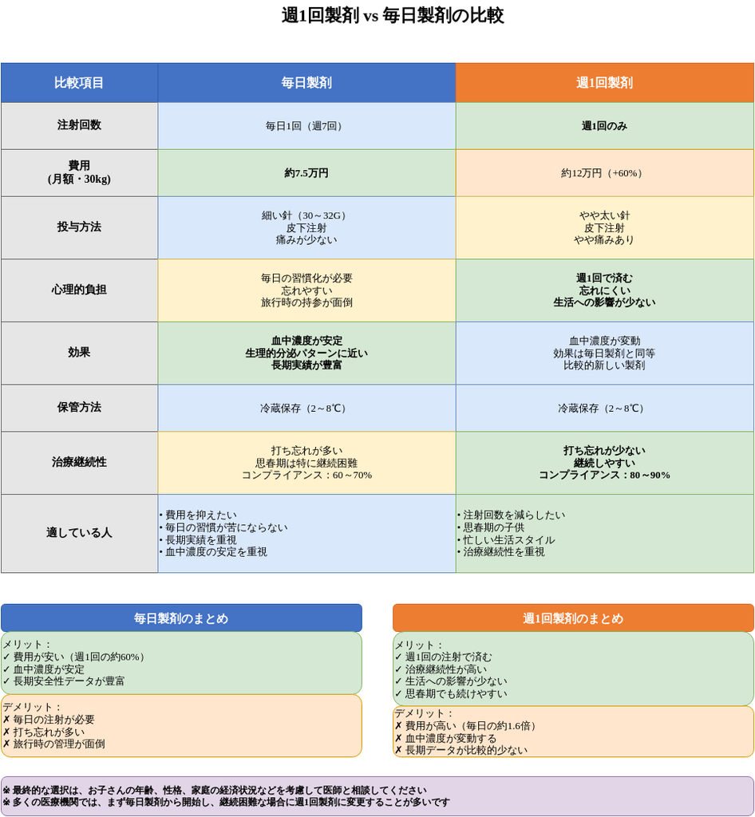

図9-2：週1回製剤vs毎日製剤の比較

### 毎日製剤（従来型）

**特徴**：

- 毎日1回、皮下注射
- 年間365回の注射
- 長年の豊富なエビデンス

**メリット**：

- 費用が相対的に安い
- 就寝前のルーチンとして定着しやすい
- 自己管理能力の育成

**デメリット**：

- 毎日の注射の負担
- 初期は子供の抵抗感
- 親の毎日の管理負担
- 旅行時の持ち運び

### 週1回製剤（長時間作用型）

近年登場した新しい選択肢です。

**製剤名**：

- エヌジェンラ®（ソマトロゴン）
- ソグルーヤ®（ソマプシタン）

**特徴**：

- 週1回、皮下注射
- 年間52回の注射
- 毎日製剤と同等の効果（非劣性が証明されている）

**メリット**：

- 注射回数が大幅に減少
- 子供と親の負担が軽減
- 旅行・外出時の利便性
- コンプライアンス向上（忘れにくい）

### 費用比較（体重別）

#### 体重20kgの場合

[output not shown]

#### 体重30kgの場合

[output not shown]

#### 体重40kgの場合

[output not shown]

### どちらを選ぶべきか

これは、**費用と負担軽減のトレードオフ**です。

**週1回製剤を選ぶべきケース**：

- 経済的に余裕がある
- 子供が毎日の注射に強い恐怖感を持っている
- 旅行や外出が多い家庭
- 毎日のルーチン管理が困難

**毎日製剤を選ぶべきケース**：

- 費用を最小限に抑えたい
- 長期エビデンスを重視
- 毎日のルーチン化が可能
- 子供の自己管理能力を育てたい

**現実的には**：

多くの家庭は費用面から毎日製剤を選択します。

週1回製剤は「経済的に余裕がある家庭」の選択肢です。

## 9-7. 効果が得られないケース

ここまで平均的な効果（3.5～7.5 cm）を述べてきましたが、現実には効果に大きな個人差があります。

### 反応不良のケース

治療開始1年目で、身長SDSが0.3未満の増加しかない場合、「反応不良」と判断されます。

この場合、継続しても大きな効果は期待しにくいとされます。

### 反応不良の要因（推測）

- 遺伝的要因
- 栄養状態
- 睡眠の質
- ストレス
- その他の内分泌異常

しかし、**事前に反応不良かどうかを予測する方法はありません**。

やってみなければ分からない、というのが現実です。

### 「1年間で100万円以上使ったのに、効果なし」の現実

これが起こり得るのが、自由診療の厳しい現実です。

その場合、治療を中止するか、継続するか、難しい判断を迫られます。

## 第9章のまとめ

**効果**： - 平均3.5～7.5 cm（4～7年継続） - 効果には大きな個人差 - 1年目の反応が重要

**「2年 vs 4～7年」の違い**： - 2年：ブースト効果のみ - 4～7年：最終身長の改善

**リスク**： - 一般的副作用：注射部位反応、浮腫、関節痛 - 稀だが重篤：BIH、SCFE - 長期的懸念：インスリン抵抗性

**製剤選択**： - 毎日 vs 週1回は費用と負担のトレードオフ

# 第10章：クリニックの選び方と治療の実際

ここまで読んで、「やってみよう」と思ったあなたへ。

この章では、どのクリニックを選ぶべきか、治療の実際はどうなのか、具体的に見ていきます。

## 10-1. 全国の主要クリニック比較

自由診療で成長ホルモン治療を提供しているクリニックは、全国に複数あります。主要なクリニックを地域別に紹介します。

### 関東地方

**東京神田整形外科クリニック（東京都千代田区）** - 「身長外来」の専門クリニックとして最も有名 - YouTube、Instagram、書籍などで積極的に情報発信 - -2SD以上でも治療可能 - 費用は要問い合わせ（総額数百万円規模の可能性）

**ヨーダー公子クリニック（神奈川県横浜市・川崎市）** - 費用の透明性が高い - 初診カウンセリング料：約16,500円、血液検査：5,500円 - GH製剤：1アンプル 71,500円（税込） - 月額目安（体重20kg）：約110,000円 - 3ヶ月ごとに定期受診

### 関西地方

**明豊外科リハビリテーション病院（兵庫県神戸市）** - GH療法に加え、複数のホルモン療法を組み合わせた総合的アプローチ - 毎日注射・週1回注射の両方に対応 - 体重20kg：約13万円/月、30kg：約19万円/月、40kg：約26万円/月 - 3年間継続で平均約+9cmの身長増加を報告 - 3歳～10歳までの開始が最も効果的

### 東北地方

**なとり皮膚科くまのどうクリニック（宮城県仙台市・名取市）** - 費用の透明性が極めて高い（体重別シミュレーション公開） - 毎日タイプ：体重20kg 約108,000円/月、30kg 約185,000円/月 - 週1回タイプ：体重20kg 約297,000円/月、30kg 約440,000円/月 - 一度に3ヶ月分まで処方可能（遠方患者に便利）

### その他

**SBC整形外科クリニック**（全国展開） - 初回トライアル価格：1本 39,800円（税込） - 月額目安（体重21kgまで）：約119,600円

**Crystal 医科歯科 Clinic International** - 週1回製剤（ソグルーヤ）：165,000円/回 - 英語対応可能

## 10-2. クリニック選びの7つのチェックポイント

どのクリニックを選ぶべきか？

以下の7つのポイントで比較してください。

### 1. 通院のしやすさ

**月1回程度の通院が必要**です。

- 自宅からの距離
- 交通手段
- 通院時間
- 遠方の場合、受診間隔を調整できるか（3ヶ月ごとなど）

**遠方からの通院**：

- なとりくまのどうクリニック：3ヶ月分まとめて処方可能
- その他のクリニックも、安定していれば長期処方に対応する場合あり

### 2. 費用の透明性

**事前に費用を明確に提示しているか**

- 体重別の月額費用
- 総額の試算
- 検査費用
- 初期費用（ペン代など）

**透明性が高いクリニック**：

- なとり皮膚科くまのどうクリニック
- ヨーダー公子クリニック

**要問い合わせのクリニック**：

- 東京神田整形外科クリニック

### 3. 医師の説明の丁寧さ

**初診時に以下を説明してくれるか**：

- 期待できる効果（現実的な数値）
- リスクと副作用
- 治療期間
- 総額費用
- 保険適用の可能性（他院紹介も含めて）

**避けるべきサイン**：

- 「絶対伸びます」など過度に楽観的
- リスクの説明が不十分
- 費用の説明が曖昧
- 保険適用の可能性を十分に検討せずに自費を勧める

### 4. 治療方針（2年 vs 長期）

**クリニックの治療期間設定**：

- 「最大2年まで」：ブースト効果重視
- 「骨端線閉鎖まで」：最終身長最大化重視

**どちらが良いかは家庭の判断**ですが、事前に確認してください。

### 5. 週1回製剤の取り扱い

**週1回製剤を選択できるか**：

- 取り扱いあり：明豊外科リハビリテーション病院、なとりくまのどうクリニック、Crystal
- 取り扱いなし（または情報なし）：ヨーダー公子クリニック、その他多数

### 6. 口コミ・評判

**情報源**：

- Google口コミ
- SNS（Twitter/X、Instagram）
- Yahoo!知恵袋などの掲示板
- 実際に治療を受けた家族の声（ただし、個人情報保護の観点から少ない）

**注意点**：

- 自由診療は「満足度」が主観的
- 高額な費用を払っているため、ポジティブバイアスがかかりやすい
- ネガティブな口コミが少ない理由は、高額投資への認知的不協和（「こんなに払ったのだから、効果があったはず」）

### 7. セカンドオピニオンへの対応

**他院の意見を聞くことに対して寛容か**

- セカンドオピニオンを推奨するクリニック：信頼性が高い
- 「うちでしかできない」と強調するクリニック：要注意

## 10-3. 初診から治療開始までの流れ

### ステップ1：予約と初診

**持参するもの**：母子手帳、学校の身体測定データ（過去数年分）、お薬手帳、保険証

**初診内容**： - 問診（両親の身長、既往歴、生活習慣） - 身長・体重測定、成長曲線の確認 - 治療の概要、効果、リスク、費用の説明 - 費用：約15,000～20,000円

### ステップ2：精密検査

**骨年齢評価（左手X線）**：骨端線の開存確認、残された成長期間の推定 **血液検査**：IGF-1、甲状腺機能、その他成長関連ホルモン値 **費用**：約5,000～10,000円

### ステップ3：再診（1～2週間後）

- 検査結果の説明（骨年齢、血液検査データ）
- 最終身長予測の提示（両親の身長、骨年齢、成長曲線から算出）
- 治療方針の相談（予測身長と目標身長の比較、費用の詳細）
- 治療開始の決定

### ステップ4：注射指導と治療開始

**手技指導**：注射ペンの使い方、注射部位、消毒方法、針の廃棄方法 **練習**：親が実際に注射を練習 **自宅で開始**：毎日製剤は就寝前、週1回製剤は決まった曜日

### ステップ5：定期フォローアップ

- **1ヶ月後**：身長の伸び確認、注射実施状況、副作用チェック
- **3ヶ月ごと**：身長・体重測定、成長速度の計算
- **3～6ヶ月ごと**：骨年齢測定、血液検査（IGF-1、血糖値、甲状腺機能）

## 10-4. 在宅自己注射の実際

「うちの子、注射できるかしら？」多くの母親が抱く不安です。

### 注射デバイスと針

**ペン型注入器**：太めのボールペンのような形状。薬剤カートリッジを装着し、ダイヤルで投与量を設定、ボタンを押すと自動で注射。

**針の細さ**：直径約0.23～0.25mm（髪の毛の約3倍、採血の針より遥かに細い）

**痛み**：「チクッとする」程度。「蚊に刺された程度」と表現する子供も多い。痛いというより、「恐怖心」の方が大きい。

### 注射部位と手順

**推奨部位**：腹部、大腿部、臀部、上腕部（毎日同じ場所を避け、ローテーション）

**手順**：手洗い→消毒→針装着→投与量設定→皮膚をつまむ→針を刺す→注入→針を抜く→軽く押さえる→針廃棄

**所要時間**：慣れれば1～2分

### 慣れと成長

- **初期（1～3ヶ月）**：親が注射、子供は見守る
- **中期（3～6ヶ月）**：子供が一部を手伝う（消毒、準備など）
- **後期（6ヶ月～1年）**：高学年なら自分で打てるようになる子も

最初は誰でも怖いですが、毎日続けると「歯磨き」と同じレベルのルーチンになります。

### 旅行・外泊時

**毎日製剤**：保冷バッグで持参、宿泊先の冷蔵庫で保管 **週1回製剤**：注射日を調整できるため負担が少ない

## 10-5. 治療中のモニタリングの重要性

在宅自己注射だからといって、「放置」ではありません。

安全に治療を継続するためには、定期的なモニタリングが必須です。

### なぜモニタリングが重要か

**理由1：効果の確認**

- 身長の伸びは期待通りか
- 1年目の反応が良好か（SDS +0.3以上）
- 継続する価値があるか

**理由2：副作用の早期発見**

- 良性頭蓋内圧亢進症（BIH）
- 大腿骨頭すべり症（SCFE）
- インスリン抵抗性
- 甲状腺機能異常

**理由3：投与量の調整**

- IGF-1が高すぎる場合は減量
- 低すぎる場合は増量
- 体重増加に伴う投与量の見直し

### モニタリングのスケジュール

**月1回の通院**：

- 身長・体重測定
- 成長速度の計算
- 注射の実施状況確認
- 副作用チェック

**3～6ヶ月ごと**：

- 血液検査（IGF-1、血糖値、HbA1c、甲状腺機能）
- 骨年齢測定（手のX線）
- 身体診察（側弯症、股関節など）

**1年ごと**：

- 治療効果の総合評価
- 継続の要否判断
- 費用対効果の再検討

### 自宅でのセルフチェック

**毎日**：

- 注射実施のチェック
- 注射部位の観察（発疹、腫れ、硬結）

**週1回**：

- 身長測定（同じ時間帯、同じ条件で）
- 体重測定

**気になる症状があればすぐに報告**：

- 激しい頭痛（特に朝）
- 視覚異常
- 股関節・膝の痛み
- 歩行困難
- 手足のこわばり

### 記録の重要性

**記録すべきこと**：

- 注射実施日時
- 身長・体重（週1回）
- 気になる症状
- 生活習慣（睡眠時間、食事、運動）

**記録の活用**：

- 医師との診察時に提示
- 効果の可視化
- モチベーション維持

## 10-6. 効果判定：1年目が重要

治療を開始したら、1年目の反応が極めて重要です。

### 良好な反応の基準

**身長SDSが0.3～0.5以上増加**

例：

- 開始時：-2.0 SD
- 1年後：-1.5 SD以上
- → 良好な反応

### 反応不良の場合

**身長SDSが0.3未満の増加**

例：

- 開始時：-2.0 SD
- 1年後：-1.9 SD
- → 反応不良

### 反応不良の場合の対処

**選択肢1：治療を中止**

- これ以上継続しても効果が限定的
- 費用対効果が悪い
- 中止を検討

**選択肢2：投与量の調整**

- IGF-1の値を確認
- 投与量を増やす
- 栄養・睡眠などの生活習慣を見直す

**選択肢3：併用療法を検討**

- 思春期抑制療法
- 栄養療法
- ただし、費用はさらに増加

### 1年間で100万円以上使って効果なしの覚悟

これが現実です。

やってみなければ分からない。

でも、1年目の反応を見て、冷静に判断することが重要です。

「ここまで使ったのだから」という心理（サンクコスト効果）に囚われず、客観的に判断してください。

## 第10章のまとめ

**全国の主要クリニック**： - 関東：東京神田整形外科、ヨーダー公子クリニック - 関西：明豊外科リハビリテーション病院 - 東北：なとり皮膚科くまのどうクリニック

**クリニック選びの7つのチェックポイント**： 1. 通院のしやすさ 2. 費用の透明性 3. 医師の説明の丁寧さ 4. 治療方針（2年 vs 長期） 5. 週1回製剤の取り扱い 6. 口コミ・評判 7. セカンドオピニオンへの対応

**初診から治療開始までの流れ**： 1. 電話・Web予約 2. 初診（カウンセリング） 3. 精密検査 4. 再診（結果説明） 5. 注射指導 6. 治療開始 7. 定期フォローアップ

**在宅自己注射の実際**： - ペン型注入器で簡単 - 針は極細（髪の毛の3倍程度） - 痛みは「チクッとする」程度 - 慣れれば1～2分で完了

**モニタリング**： - 月1回の通院 - 3～6ヶ月ごとの血液検査・骨年齢測定 - 効果判定（1年目が重要）

# 第11章：決断のためのフレームワーク

ここまで読んだあなたは、膨大な情報を受け取りました。

効果、費用、リスク、クリニック、注射の実際…

でも、最も難しいのは、**「やる」か「やらない」かの決断**です。

この章では、後悔しない決断をするためのフレームワークを提供します。

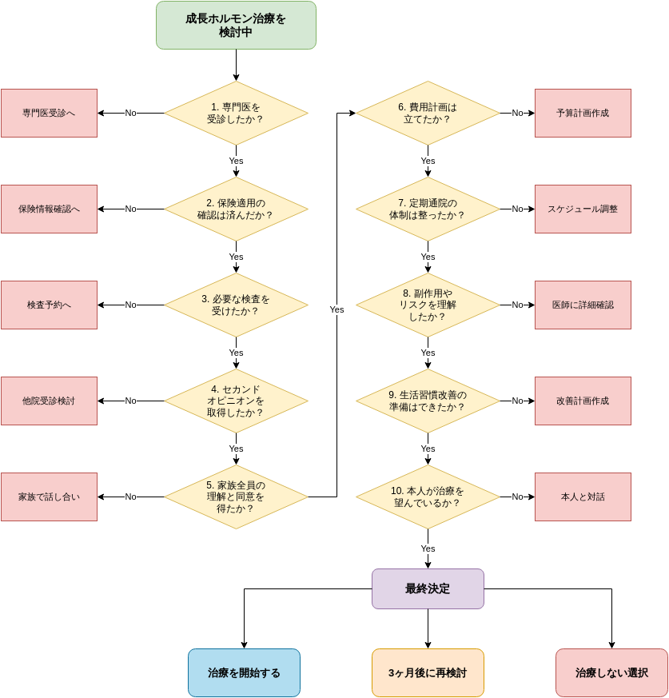

図11-1：治療開始の意思決定フローチャート

## 11-1. 「やる」前に確認すべき7つのこと

もしあなたが「自由診療GH治療をやってみよう」と考えているなら、以下の7項目を**全て**確認してください。

1つでも「No」があれば、立ち止まって考え直してください。

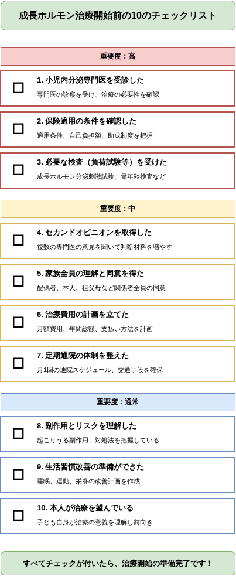

図11-2：治療開始前の10項目チェックリスト

### 1. 保険適用の可能性を徹底的に確認したか

**確認すること**： - 小児内分泌専門医による精密検査（GH分泌刺激試験含む）を受けたか - GH分泌刺激試験の頂値が6 ng/ml未満なら保険適用の可能性 - SGA性低身長症など他の保険適用疾患の可能性も確認 - セカンドオピニオンを取得したか

**なぜ重要か**：保険適用なら月数千円 vs 自由診療なら月10～30万円。この差は人生を左右します。

### 2. 現実的な効果を理解したか

**確認すること**： - 最終身長の改善は平均3.5～7.5 cm（効果に大きな個人差あり） - 治療期間は平均4～7年 - 「10cm以上伸びる」などの過度な期待を持っていないか

**なぜ重要か**：過度な期待は失望につながります。現実的な期待値を持つことが重要です。

### 3. 総額費用と家計への影響を試算したか

**確認すること**： - 総額400万～1400万円の費用試算（体重増加・治療期間を考慮） - 家族の教育費、住宅ローン、老後資金への影響 - きょうだいへの影響も考慮 - 夫婦で十分に話し合ったか

**なぜ重要か**：途中で経済的に継続困難になると、治療効果が最大化されません。

### 4. リスク（副作用）を理解し受容したか

**確認すること**： - 一般的副作用（注射部位反応、浮腫、関節痛） - 稀だが重篤な副作用（BIH、SCFE） - 長期的影響（インスリン抵抗性） - 定期モニタリングの必要性

**なぜ重要か**：「高いお金を払えば安全」ではありません。リスクを理解し受容できるかが重要です。

### 5. 子供本人が受け入れられるか

**確認すること**： - 子供に治療について年齢に応じて説明したか - 毎日（または週1回）の注射を受け入れられるか - 子供が「やりたくない」と言った場合の対応を考えたか

**なぜ重要か**：注射を受けるのは子供本人。無理強いは心理的トラウマになる可能性があります。

### 6. 生活習慣の最適化を先にやったか

**確認すること**： - 睡眠・栄養・運動の最適化を最低3ヶ月継続したか - それでも十分な効果が得られなかったか

**なぜ重要か**：生活習慣の最適化は無料～低コスト。「まず生活習慣、それでもダメならGH治療」が順序です。

### 7. 「やらない」選択肢も検討したか

**確認すること**： - 「治療しない」という選択肢も真剣に検討したか - 身長以外の強みを伸ばす方法を考えたか - 心理的カウンセリングという選択肢も検討したか

**なぜ重要か**：GH治療は「必須」ではありません。「やらない」も立派な選択です。

## 11-2. 夫婦で意見が分かれた場合

よくあるパターンです。

**妻（母親）**：「やってあげたい。後悔したくない。」 **夫（父親）**：「高すぎる。本当に必要なのか。」

### なぜ意見が分かれるのか

**母親の視点**：日々子供の悩みを聞いており、「何もしなかった後悔」を恐れる **父親の視点**：家計の現実から「費用対効果」を冷静に計算する

**どちらも正しい**

### 対立を乗り越える2つのステップ

#### ステップ1：専門医の意見を夫婦で一緒に聞く

夫婦で一緒に小児内分泌専門医を受診し、以下を確認： - 保険適用の可能性 - 期待できる効果（現実的な数値） - リスクと費用 - 他の選択肢

**第三者（専門医）の客観的な意見**を聞くことで、感情的な対立を和らげます。

子供本人（10～12歳）の意思も確認し、「やりたい」「やりたくない」「分からない」という反応を尊重します。

#### ステップ2：期限を決めて決断する

「1ヶ月後までに決める」など期限を設定。その間に専門医の意見、セカンドオピニオン、家計見直し、子供の意思確認を行い、**共同で決断**します。

### 最終的に合意できない場合の選択肢

1. **保留**：1年間生活習慣改善に注力し、再評価
2. **第三者の意見**：祖父母、ファイナンシャルプランナー、カウンセラーに相談
3. **トライアル**：1年間だけ試し、反応を見て継続判断（ただし1年で130～360万円の費用発生）

## 11-3. 「やる」と決めた場合のロードマップ

「やる」と決断したあなたへ。ここからが本当のスタートです。

### ステップ1：資金計画と準備

**資金計画**： - 子供の体重・治療期間を考慮し総額を試算（400万～1400万円） - 資金源を確保（貯蓄、収入増、祖父母援助など） - 家計への影響を再確認（教育費、住宅ローン、老後資金、緊急予備費）

**クリニック選定**： - 最低2～3ヶ所で初診し比較（通院のしやすさ、費用の透明性、医師の説明、治療方針、週1回製剤の取り扱い） - 家族で話し合って最終決定

### ステップ2：生活との両立

**通院と注射管理**： - 月1回の通院スケジュール調整（平日or週末、付き添い担当） - 毎日の注射管理者を決定（就寝前ルーチンに組み込む、週1回製剤なら週末実施） - 記録管理方法の確立（アプリまたはノート）

**家族への配慮**： - きょうだいへの丁寧な説明と平等な愛情配分 - 祖父母からの援助を期待する場合は、効果・費用・リスクを具体的に説明

### ステップ3：治療開始と継続

**開始準備**： - 子供の不安に寄り添い丁寧に説明 - 必要物品の準備（注射ペン、保冷バッグ、記録ノート、針廃棄容器など）

**継続のための工夫**： - 月1回の身長測定を楽しみに、成長曲線で伸びを可視化 - 家族全体でサポートし、完璧主義にならず柔軟に対応 - 1年目の反応を見て継続を再検討

## 11-4. 「やらない」と決めた場合

「やらない」という決断も、立派な選択です。

### 「やらない」理由はさまざま

**経済的理由**：

- 年間100万～200万円以上は家計的に無理
- 他の家族のためにお金を使いたい

**リスクへの懸念**：

- 副作用が心配
- 長期的な影響が不安

**子供の意思**：

- 子供が「注射は嫌だ」と言った
- 無理強いしたくない

**価値観**：

- 「身長がすべてではない」
- 「自然な成長を尊重したい」

**効果への疑問**：

- 「平均3.5～7.5 cm」に数百万円は高すぎる
- 効果に個人差がありすぎる

**どの理由も正当です。**

### 「やらない」と決めた後にすべきこと

#### 1. 生活習慣の最適化に全力投球

GH治療はしないが、第2部の「睡眠・栄養・運動」の最適化には全力で取り組む。

**睡眠**：

- 9～11時間確保
- 質の高い睡眠

**栄養**：

- タンパク質40～50g/日
- カルシウム、ビタミンD、亜鉛、鉄

**運動**：

- 縄跳び、バスケ、バレーなど

**これらは無料～低コストで、確実に効果がある**

#### 2. 心理的サポート（カウンセリング）

子供が「身長が低い」ことで心理的に悩んでいる場合、カウンセリングを検討する。

**カウンセリングの効果**：

- 自己肯定感の向上
- 身長以外の強みに気づく
- コンプレックスとの向き合い方を学ぶ

**GH治療 vs カウンセリング**：

- GH治療：年間100万～200万円以上、効果は身体的
- カウンセリング：月1～2万円程度、効果は心理的

「身長の低さ」が心理的な問題なら、カウンセリングの方が直接的な解決策かもしれません。

#### 3. 身長以外の強みを伸ばす

身長が低くても、他の強みを伸ばすことで自信をつける。

**例**：

- 勉強
- スポーツ（体操、サッカー、野球など）
- 音楽
- 芸術
- コミュニケーション能力
- リーダーシップ

「身長が低い」ことは一つの特徴に過ぎません。

他の強みを伸ばすことで、子供は自信を持てます。

#### 4. 環境調整

**学校**：

- いじめがある場合は学校と連携
- 先生に相談
- 必要に応じてカウンセラー、スクールソーシャルワーカーの活用

**スポーツ**：

- 身長が不利にならないスポーツを選ぶ
- 体操、サッカー、野球、卓球、テニスなど

**友人関係**：

- 身長で判断しない友人を大切にする
- 趣味や興味で繋がる

#### 5. 後悔しないための記録を残す

「やらない」と決めたプロセスを記録に残す。

**記録すべきこと**：

- なぜ「やらない」と決めたか
- どのような情報を集めたか
- 専門医の意見
- 夫婦の話し合い
- 子供の意思

**なぜ記録が重要か**：

- 将来「やっぱりやればよかった」と後悔したときに、「当時は最善の判断をした」と確認できる
- 子供が将来「なんでやってくれなかったの？」と聞いたときに、「こういう理由で、あなたのために考えた結果だよ」と説明できる

## 11-5. 私たち家族の決断シート

ここでは、あなたの家族だけの「決断シート」を作ります。このシートを夫婦で、できれば子供も交えて、一緒に埋めてください。

### 私たち家族の決断シート

**作成日**：20○○年○月○日

**家族構成**：父○○歳、母○○歳、子供（本人）○○歳・身長○○cm・体重○○kg、きょうだい○○歳（いる場合）

#### 1. 基本情報

**家族の価値観**（最も大切にしていること3つ）： 1. ______________________________ 2. ______________________________ 3. ______________________________

**身長の重要度**（1～10）：○ / 10

**子供の現状**： - 身長○○cm（○歳○ヶ月）、成長曲線-○○ SD - 予測最終身長（治療なし）：約○○cm - 子供本人の悩み：______________________________ - 子供本人の治療への意思：やりたい / やりたくない / 分からない

#### 2. 経済状況と専門医の意見

**経済状況**： - 年収（世帯）：約○○○万円、貯蓄：約○○○万円 - GH治療予算：月額○○万円まで、総額（○年間）○○○万円まで - 家計への影響：影響なし / やや厳しい / かなり厳しい / 不可能

**専門医の意見**： - 病院名：______________________________ - GH分泌刺激試験：頂値○○ ng/ml - 保険適用：可能 / 不可能 - セカンドオピニオン：取得した / 取得していない

#### 3. リスク・ベネフィット評価

**期待効果**：最終身長改善平均3.5～7.5 cm、治療期間平均4～7年、個人差あり **費用**：月額約○○万円、総額約○○○○万円 **リスク**：一般的副作用（注射部位反応、浮腫、関節痛）、稀だが重篤（BIH、SCFE）、長期懸念（インスリン抵抗性） **理解・受容**：はい / いいえ

**生活習慣最適化**： - 睡眠・栄養・運動を実践している / していない - 実践期間○ヶ月、結果：十分な効果が得られた / 得られなかった

#### 4. 総合判断と決定

**夫の意見**：GH治療を する / しない 理由：______________________________

**妻の意見**：GH治療を する / しない 理由：______________________________

**子供本人の意思**：やりたい / やりたくない / 分からない

**夫婦の合意**：合意している / 合意していない

**最終決定**：GH治療を **する / しない** **決定日**：20○○年○月○日 **決定理由**：______________________________

#### 5. 実行計画または代替プラン

**「する」場合**： - クリニック：______________________________ - 資金源：貯蓄 / 収入増 / 援助 / その他 - 治療開始予定日：20○○年○月○日 - 製剤：毎日製剤 / 週1回製剤 - 役割分担：通院付き添い（夫/妻/交代）、注射管理（夫/妻/本人）

**「しない」場合**： - 生活習慣の最適化を継続 - カウンセリング：する / しない - 身長以外の強みを伸ばす：______________________________ - 再評価時期：○年後（20○○年○月）

#### 6. 将来へのメッセージ

**私たちがこの決断をした理由**： ______________________________ ______________________________

**子供へのメッセージ**： ______________________________ ______________________________

このシートを大切に保管してください。将来、「あのとき、どう考えたのか」を振り返るときに、あなたたちの支えになります。

## 第11章のまとめ

**「やる」前に確認すべき7つのこと**： 1. 保険適用の可能性を徹底確認（専門医の精密検査、セカンドオピニオン） 2. 現実的な効果を理解（平均3.5～7.5cm、4～7年、個人差あり） 3. 総額費用と家計への影響を試算（400万～1400万円） 4. リスク（副作用）を理解し受容 5. 子供本人が受け入れられるか 6. 生活習慣の最適化を先に実施 7. 「やらない」選択肢も検討

**夫婦で意見が分かれた場合**：専門医の意見を夫婦で一緒に聞き、子供本人の意思を確認し、期限を決めて共同で決断

**「やる」と決めた場合**：資金計画、クリニック選定、生活との両立、治療開始準備

**「やらない」と決めた場合**：生活習慣の最適化に全力、心理的サポート、身長以外の強みを伸ばす、環境調整、後悔しないための記録

# 第12章：3ヶ月実践プログラム

「変えなきゃ」と思っても、何から始めればいいのか分からない。そんな声をよく聞きます。

この章では、3ヶ月で生活習慣を変え、成長ホルモンを最大化するための実践プログラムをお伝えします。焦らなくて大丈夫。まずは、お子さんの今の生活を「見える化」することから始めましょう。

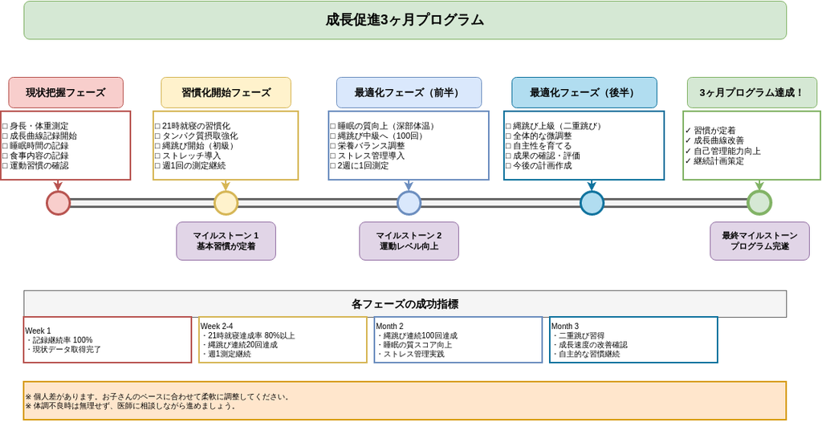

図12-1：3ヶ月実践プログラムのタイムライン

## 12-1. Week 1：現状把握と小さな変化

### Day 1～3：現状把握から始める

**まずは測定。それが変化への第一歩です。**

#### Day 1の測定と記録

**1. 身長・体重の測定**（朝起きてすぐ、トイレの後に測る）

```
【基礎データ】
測定日：2025年11月16日
身長：142.5 cm / 体重：36.0 kg / 年齢：11歳3ヶ月
```

**2. 成長曲線にプロット**

母子手帳や日本小児内分泌学会のサイトの成長曲線に身長をプロットし、-2SD～+2SDの範囲内か、カーブと平行に伸びているかを確認します。

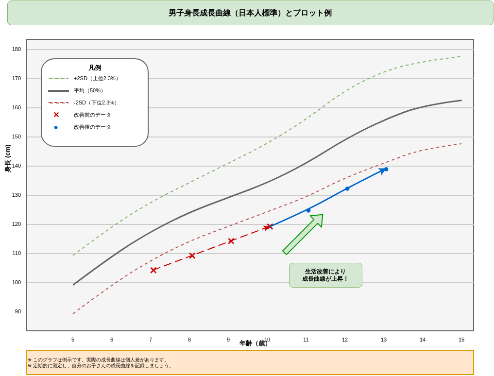

図12-2：成長曲線プロット例

**3. 生活習慣の記録**（Day 1～3の3日間）

- 就寝・起床時刻と睡眠時間
- 朝・昼・夕の食事内容（特にタンパク質・カルシウム）
- 運動内容と時間

#### Day 3の夜：振り返りと課題の特定

3日間の平均睡眠時間を計算し、推奨時間（10～12歳：9～10時間）と比較。睡眠・栄養・運動で一番変えたいことを1つ決めましょう。

### Day 4～7：3つの小さな変化

**最初の1週間でやることは、たった3つだけ**。

#### 変化1：就寝時刻を30分早める

**具体策**： - 夕食・お風呂を30分早める - 就寝1時間前にスマホ・ゲームを回収 - 寝る前の15分は親子の時間

**子供への説明**：「スマホの光は『身長を伸ばすホルモン』を減らすから、夜は○時までにしない？朝、早く起きてゲームしてもいいよ」

#### 変化2：朝食にタンパク質を1品追加

**5分以内で準備できるもの**：卵料理、納豆（パックを開けるだけ）、ヨーグルト、チーズ、ハム・ソーセージ

#### 変化3：縄跳びを5分だけ始める

**縄跳びの利点**：費用が安い（縄1本）、場所を選ばない、短時間でOK、骨への刺激が大きい

**5分プログラム**：連続10回→20回→50回と段階的に

**週に3～4回できれば上出来**。できなかった日があっても大丈夫。

### 1週間の振り返り（Day 7の夜）

- 平均睡眠時間と達成日数（7日中 日）
- タンパク質追加の達成日数（7日中 日）
- 縄跳び実施の達成日数（7日中 日）

**できたこと・できなかったことをリストアップし、自分を褒めてあげてください**。完璧じゃなくても、「始めた」ことが素晴らしいのです。

## 12-2. Week 2～4：1ヶ月目の習慣化

### 睡眠習慣の確立

**目標**：毎日同じ時刻に寝る・起きる（週末も含む）、デジタルデトックス、寝室環境の最適化

#### 就寝・起床時刻の設定と段階的移行

**起床時刻から逆算**：登校時刻8時 → 7時起床 → 必要睡眠9時間 → 22時就寝

**段階的移行**（現在23時就寝の場合）：Week 1（22時30分）→ Week 2（22時15分）→ Week 3（22時）→ Week 4（21時45分）

#### デジタルデトックスと寝室環境

**充電ステーション**：リビングに設置し、就寝1時間前に家族全員のデバイスを集める（親も一緒に）

**寝室環境チェック**： - 光：遮光カーテン、電子機器のLEDを隠す、豆電球も消す（真っ暗が理想） - 温度・湿度：室温18～22℃、湿度40～60% - 週末も平日と±1時間以内の起床時刻を維持（寝溜めは逆効果）

### 栄養習慣の確立

**目標**：献立の事前作成、週末の作り置き、タンパク質・カルシウムのチェック

#### 献立パターンと作り置き

**1週間の献立例**：魚と肉を交互に（月・木：魚、火・金：肉、水：鍋物、土：家族の好物、日：作り置き消費）

**朝食のパターン化**： - 和食：ご飯 + 卵 + 納豆 + 味噌汁 + 牛乳 - 洋食：パン + 卵料理 + ヨーグルト + 果物

**初心者向け作り置き3品**（日曜2時間で）：ひじきの煮物（15分）、ゆで卵10個（15分）、鶏の唐揚げ冷凍用（30分）

#### タンパク質・カルシウムの簡易チェック

**1日の目標**（10～12歳男子）：タンパク質40～50g、カルシウム700～1000mg

**毎食チェック**：朝（卵or納豆orヨーグルト）、昼（肉or魚or大豆製品）、夕（肉or魚）、カルシウム（牛乳・ヨーグルト・チーズ・小魚）

**全部にチェックが入れば必要量を満たします**。サプリは不要。その費用を食材に使う方が効果的。

### 運動習慣の確立

**目標**：縄跳び10分、記録でモチベーション維持、週末の家族アクティビティ、楽しさ最優先

#### 段階的増量と縄跳びプログラム

**増量計画**：Week 1（5分）→ Week 2（7分）→ Week 3（8分）→ Week 4（10分）

**10分プログラム例**： - 初級：前跳び3分 → 休憩1分 → 前跳び3分 → 休憩1分 → 前跳び2分 - 中級：前跳び4分 → 休憩1分 → 後ろ跳び2分 → 休憩1分 → かけ足跳び2分 - 上級：前跳び2分 → 二重跳び3分 → 休憩1分 → かけ足跳び3分 → クール1分

#### 週末の家族アクティビティと楽しさの維持

**アクティビティ例**：公園で鬼ごっこ、ハイキング、サイクリング、キャッチボール、プール、ボルダリング

**楽しさを保つコツ**：無理強いしない（週3～4日で十分）、努力を褒める、親も一緒に、バリエーションをつける

### 1ヶ月の成果測定（Day 30）

**身長・体重の再測定**（Day 1と同条件）：0.5～1cm伸びていれば順調

**習慣の定着度チェック**（目標：80%以上=24日以上で合格）： - 睡眠：目標時刻達成日数／30日 - 栄養：タンパク質3食・カルシウム摂取日数／30日 - 運動：縄跳び実施日数／30日

## 12-3. Week 5～12：2～3ヶ月目の最適化

### うまくいっていることの強化

#### 成功パターンを見つける

1ヶ月間の記録を見返して、「うまくいった日」の共通点を探します。

**例**： - 夕食が18時30分までに終わっていた日は就寝時刻を守れた - ゆで卵を作っておいた日は朝食にタンパク質を摂れた - 帰宅後すぐにやった日は縄跳びができた

#### 成功パターンを「仕組み化」する

**例1：週末に3日分の夕食を作り置き** - 日曜日の午後2時間を「作り置きタイム」に確保 - 冷凍できるおかずを3品作る

**例2：毎週日曜日に10個ゆで卵を作る** - 冷蔵庫の見やすい場所に保存 - なくなりそうになったら水曜日に追加で5個

**例3：縄跳びを玄関に置いておく** - 帰宅後すぐに目に入る - 「おやつは縄跳びの後」とルール化

### うまくいっていないことの調整

#### 障害を特定する

**例1：塾で帰宅が遅い** - 塾のある日は夕食を軽めにし、帰宅後すぐ就寝 - 翌朝しっかり朝食を食べる - または、塾の回数を減らす、オンライン塾に切り替える

**例2：朝、時間がない** - ゆで卵を常備（殻をむくだけ） - 納豆を常備（パックを開けるだけ） - 朝15分早く起きる

**例3：子供が縄跳びを嫌がる** - 友達と一緒にやる - メニューに変化をつける - 縄跳び以外の運動も取り入れる - 親も一緒にやる

#### 完璧主義を捨てる

**80%できれば合格**。できない日があってもいいのです。大事なのは、翌日また始めること。

### 家族を巻き込む

#### 夫の協力を得る

**話し方のコツ**：

「ねえ、○○くんの身長のこと、ちょっと相談したいんだけど。本を読んでいろいろ調べたら、睡眠と栄養と運動が本当に大事だって分かったの。遺伝も大事だけど、生活習慣で2～5cmは変わるみたい。私一人だと続けるの難しくて。あなたに手伝ってもらえることってある？」

**夫に頼めること**： - デバイスの回収（就寝1時間前） - 週末の朝食作り - 週末の運動（キャッチボール、サイクリングなど） - 月1回の身長測定を一緒にやる

#### きょうだいへの配慮

**「お兄ちゃんばっかり」と思われないために**： - 「家族みんなで健康になろう」というフレーム - 縄跳びは兄弟で一緒にやる - 週末のアクティビティは全員で - 身長以外の価値も認める

#### 祖父母の理解と協力

**説明の仕方**：

「お母さん、いつもありがとうございます。最近、子供の成長について勉強したんですけど、睡眠と栄養が本当に大事だって分かったんです。特に、夜遅くまでスマホを見ると、成長ホルモンが減っちゃうみたいで。だから、夜は早く寝かせるようにしてるんです。○○の将来のためなんです。理解していただけると嬉しいです」

### 3ヶ月の総括（Day 90）

#### 身長・体重の測定

```
【3ヶ月後（Day 90）】
測定日：2026年2月16日
身長：　cm
体重：　kg

【3ヶ月前（Day 1）】
身長：142.5 cm
体重：36.0 kg

【3ヶ月間の変化】
身長：+　cm
体重：+　kg
```

**期待値**： - 10～12歳男子：3ヶ月で約1.2～1.5cm - **1.5～2cm伸びていれば順調**

#### 習慣の達成率

**睡眠**： - 平均睡眠時間： 時間 分 - 目標時刻に寝られた日：90日中 日（ %）

**栄養**： - タンパク質を3食摂れた日：90日中 日（ %） - カルシウムを摂れた日：90日中 日（ %）

**運動**： - 運動ができた日：90日中 日（ %）

**目標**：睡眠・栄養80%以上、運動60%以上で合格

## 12-4. 3ヶ月後の振り返りと今後

### 3ヶ月間で一番変わったこと

**子供について**： - 身長・体重の変化 - 体調・表情 - 生活リズム - 本人の自覚

**家族について**： - 夫の協力度 - きょうだいの様子 - 家族全体の健康意識

**あなた（母親）について**： - 気持ちの変化 - 「やれた」という自信 - 続けられそうか

### 今後の継続プラン

**3ヶ月続けば、もう習慣**。行動心理学では、90日（3ヶ月）で習慣が「当たり前」になると言われています。

#### 絶対に続ける3つ（コア習慣）

1. **睡眠**：毎日同じ時刻に寝る・起きる
2. **朝食のタンパク質**：卵・納豆・ヨーグルトのどれか
3. **週3回以上の運動**：縄跳びorその他

**これだけは死守する。**

#### 柔軟に調整すること

- 週末の睡眠時刻（±1時間はOK）
- たまにはスナック菓子もOK
- 運動できない日があってもOK

**80%できていれば十分。**

#### 4～6ヶ月目の目標

**身長**： - 3ヶ月でさらに+1.5～2cm - 6ヶ月で合計+3～4cm

**生活習慣**： - 今の習慣を無理なく継続 - さらに改善できる部分があれば微調整

**家族**： - 夫の協力をさらに得る - 家族全体で健康になる

## 12-5. よくある質問

### Q1. 全部できませんでした。私はダメ母ですか？

**A. いいえ、全くダメじゃありません。**

10のうち3つできたら合格。1つでもできたら素晴らしいです。「できなかったこと」を数えるのではなく、「できたこと」を数えてください。

### Q2. 子供が嫌がって寝てくれません

**A. 最初は当たり前です。**

段階的に進めましょう（15分ずつでもいい）。Week 1：22時30分 → Week 2：22時15分 → Week 3：22時

### Q3. 仕事で帰宅が遅く、夕食が遅くなります

**A. 工夫次第で乗り越えられます。**

- 週末に数日分の夕食を作って冷凍
- 帰宅が遅い日は軽めにして、翌朝しっかり食べる
- 夫や祖父母、ファミリーサポートを頼る

### Q4. 朝、時間がなくて朝食を作れません

**A. 「作る」ではなく「並べる」でOK。**

納豆（パックを開けるだけ）、ヨーグルト（器に盛るだけ）、ゆで卵（前夜に茹でておく）、チーズ（切るだけ）。これなら3分でできます。

### Q5. 縄跳びができない子です

**A. 縄跳びにこだわる必要はありません。**

代替運動：かけっこ、鬼ごっこ、トランポリン、階段の上り下り、バスケのシュート練習。「ジャンプ」する動作があればOKです。

### Q6. 3ヶ月やったけど、身長が1cmしか伸びませんでした

**A. 1cmでも伸びていれば問題ありません。**

成長には波があります。今は「準備期間」で、次に大きく伸びる可能性があります。1年単位で見ていきましょう。心配なら小児内分泌専門医に相談してください。

### Q7. 夫が全く協力してくれません

**A. よくあることです。無理に巻き込まなくてOK。**

あなた一人でできる範囲で続けてください。結果が出れば、夫も認めてくれます。祖父母や友人のサポートを得るのも良い方法です。

### Q8. 私が疲れてきました。続ける自信がありません

**A. お疲れさまです。頑張りすぎていませんか？**

- 週に1日は「何もしない日」を作る
- 完璧を目指さない（80%で合格）
- 夫や家族に頼る
- 自分の時間を確保

あなたが倒れたら元も子もありません。無理なく続けられる形に調整しましょう。

### Q9. 他の子と比べて、まだ低いです。不安です

**A. 比べるのは「他の子」ではなく「過去の息子」です。**

3ヶ月前と比べて： - 身長は伸びた？ → YES - 生活習慣は良くなった？ → YES - 体調は良くなった？ → YES

これが大事です。他の子と比べて焦ると、子供にプレッシャーをかけ、逆効果になります。

## 12-6. あなたへのメッセージ

### この3ヶ月、本当にお疲れさまでした

**あなたは、この3ヶ月で**： - 毎日記録をつけた - 睡眠習慣を変えた - 栄養バランスを整えた - 運動を習慣化した - 家族を巻き込んだ

**これは、簡単なことではありません。**

### あなたは、すでに「行動した母親」

多くの母親は、「心配だな」と思うだけで終わります。

**でも、あなたは違う。** - 本を読んで学んだ - 実際に行動を起こした - 3ヶ月間、続けた

**これは、素晴らしいことです。**

### 結果が出るのは、これから

身長は、1ヶ月や3ヶ月で劇的に変わるものではありません。

**でも、確実に種を蒔きました。**

良質な睡眠、バランスの取れた栄養、適度な運動。これらは、今は小さな種でも、1年後、2年後に大きな実を結びます。

### 完璧じゃなくていい。続けることが大事。

- 80%できれば合格
- できない日があってもいい
- 柔軟に調整していけばいい

**大事なのは、やめないこと。**

### これからも、あなたのペースで

このガイドは、いつもあなたのそばにいます。

迷った時、疲れた時、読み返してください。

**あなたは一人じゃありません。**

**一緒に、息子の未来を変えていきましょう。**

## コピーして使える記録シート

### 1週間の生活習慣記録シート（統合版）

| 日付 | 就寝 | 起床 | 睡眠時間 | 朝タンパク質 | 昼タンパク質 | 夕タンパク質 | カルシウム | 運動 | 運動時間 |
| --- | --- | --- | --- | --- | --- | --- | --- | --- | --- |
| / | : | : | h m | ○・× | ○・× | ○・× | ○・× | ○・× | 分 |
| / | : | : | h m | ○・× | ○・× | ○・× | ○・× | ○・× | 分 |
| / | : | : | h m | ○・× | ○・× | ○・× | ○・× | ○・× | 分 |
| / | : | : | h m | ○・× | ○・× | ○・× | ○・× | ○・× | 分 |
| / | : | : | h m | ○・× | ○・× | ○・× | ○・× | ○・× | 分 |
| / | : | : | h m | ○・× | ○・× | ○・× | ○・× | ○・× | 分 |
| / | : | : | h m | ○・× | ○・× | ○・× | ○・× | ○・× | 分 |

**1週間の振り返り**： - 平均睡眠時間： h m / 目標達成日数： /7日 - タンパク質3食達成日数： /7日 / カルシウム達成日数： /7日 - 運動実施日数： /7日 / 合計運動時間： 分

### 3ヶ月間の成果測定シート

| 測定日 | 身長 | 体重 | Day 1との差 |
| --- | --- | --- | --- |
| Day 1 ( / ) | cm | kg | - |
| Day 30 ( / ) | cm | kg | + cm / + kg |
| Day 90 ( / ) | cm | kg | + cm / + kg |

**3ヶ月の習慣達成率**（目標：80%以上）： - 睡眠目標達成： /90日（ %） - タンパク質3食： /90日（ %） - 運動実施： /90日（ %）

**総合評価**：○（よくできた）・△（まあまあ）・×（改善が必要）

**次の3ヶ月の目標**： 1. 2. 3.

**参考**：睡眠・栄養・運動の詳細は第2章～第4章を参照してください。

# 第15章：母親の20の疑問に答える（Q&A）

本編を読んでくださった母親の皆さんから、よく寄せられる質問にお答えします。

**一部の質問は、本編の該当章への参照形式で回答しています。**

## よくある質問への回答（参照ガイド）

以下の質問は本編で詳しく解説済みです。該当章をご参照ください：

| 質問 | 参照章 |
| --- | --- |
| Q2. 牛乳を飲めば身長は伸びますか？ | **第3章**（栄養・カルシウムの役割） |
| Q3. サプリメントは本当に効果ないのですか？ | **第3章**（サプリメントの真実） |
| Q4. 筋トレは身長の伸びを止めますか？ | **第4章**（運動の効果と注意点） |
| Q5. 塾で帰宅が遅く睡眠時間が確保できません | **第2章**（塾との調整・パターン別解決法） |
| Q6. 部活動で疲れて早く寝られません | **第4章**（部活動との付き合い方） |
| Q7. 好き嫌いが多くて栄養が偏っています | **第3章**（トラブル解決・好き嫌い対策） |
| Q8. 肥満気味です。ダイエットさせるべき？ | **第5章**（肥満改善の4つの柱） |
| Q9. 自由診療は本当に効果がありますか？ | **第9章**（期待できる効果・科学的エビデンス） |
| Q10. 週1回と毎日、どちらを選ぶべき？ | **第9章**（週1回製剤 vs 毎日製剤） |
| Q16. 何歳まで伸びますか？ | **第1章**（骨端線が閉じる時期） |
| Q17. 骨年齢検査はどこで受けられますか？ | **第1章**（骨年齢検査の説明） |

## Q1. 遺伝で決まるなら何をしても無駄では？

### 質問の背景

「両親とも背が低いから、子どもも無理」と諦めている母親は多いです。

確かに身長の60～80%は遺伝で決まります。でも、**それは諦める理由ではありません。**

### 答え：20～40%は環境で変わる

**予測身長の幅：±9cm**

例：予測身長170cmの場合 - 最低：161cm - 最高：179cm - **差：18cm**

この18cmの幅のどこに落ち着くかは、**環境次第**です。

**環境の最適化で+2～5cmは可能**： - 睡眠を改善 - 栄養を整える - 運動を習慣化 - 肥満を防ぐ - ストレスを管理

### 実例：太郎くんのケース

- 予測身長：163cm
- 両親とも低身長（父165cm、母150cm）
- 小5時点：135cm（クラスで前から2番目）

母親が本書の方法を実践： - 就寝時刻を21時に - 朝食にタンパク質強化 - 毎日縄跳び10分

**最終身長：168cm（予測より+5cm）**

### 結論

遺伝は「可能性の範囲」を示すだけです。その範囲の上限を目指すか、下限で諦めるかは、**あなた次第**です。

## Q11. 医療費控除は使えますか？

### 短答：自由診療は原則対象外

**結論**：自由診療の成長ホルモン治療は、原則として医療費控除の対象外です。

### 理由

医療費控除の対象となるのは「治療目的の医療費」であり：

- **保険適用の治療** → ✓ 対象
- **自由診療の美容目的・予防目的** → ✗ 対象外

自由診療のGH治療は、医学的には： - 「病気の治療」ではない - 「身長を伸ばす予防的措置」

と解釈されるため、対象外とされるケースがほとんどです。

### 例外の可能性

以下の場合、認められる可能性があります（税務署の判断による）：

1. **低身長症の診断書がある場合**
   - GH分泌不全の診断
   - SGA性低身長の診断
   - ただし保険適用されていない場合
2. **医師が「治療」と明記した診断書**
   - 「予防」ではなく「治療」
   - 医学的必要性を明記

### 実務上のアドバイス

**申告してみる価値はある**： - 診断書を添付して申告 - 税務署が認めなければ、その分が否認されるだけ - ダメでも損はない（罰則なし）

**必要書類**： 1. 医師の診断書（治療目的と明記） 2. 領収書 3. 医療費控除の明細書

**期待値**： - 認められる確率：10～30%程度（推定） - 認められれば、年間数十万円の節税効果

### 注意

税務署によって判断が異なる可能性があります。確実な情報は、最寄りの税務署にご確認ください。

## Q12. 途中でやめられますか？

### 短答：いつでもやめられます

成長ホルモン治療は、**いつでも中止可能**です。

### 中止しても問題ない理由

1. **依存性はゼロ**
   - ホルモン補充療法とは異なる
   - 中止しても体内の自然な分泌に影響なし
2. **副作用の多くは可逆的**
   - 中止すれば副作用も消失
3. **法的・契約的制約なし**
   - いつでも患者側から中止できる

### 中止を検討すべきケース

**1. 効果が見られない** - 1年継続しても身長の伸び率が改善しない - 費用対効果が見合わない

**2. 副作用が重い** - 頭痛、関節痛が続く - 子供が苦痛を訴える

**3. 経済的に継続困難** - 予想以上の出費 - 家計の圧迫

**4. 子供の精神的負担が大きい** - 毎日の注射が苦痛 - 学業・生活に支障

### 中止のタイミング

**医師と相談の上で決定**： 1. 効果測定（3ヶ月ごと） 2. 副作用のモニタリング 3. 子供の意思確認

**急に中止してもOK**： - 徐々に減量する必要なし - すぐに止めても問題なし

### 中止後の対応

**生活習慣の継続が重要**： - 睡眠、栄養、運動は継続 - 治療をやめても、これらの効果は残る

## Q13. 受験期も続けるべきですか？

### 悩ましい質問

中学受験、高校受験の時期と、成長ホルモン治療が重なった場合、どうすべきか？

### 答え：優先順位による

**考え方1：受験を最優先する場合**

- 治療を一時中断
- 睡眠時間を確保
- 受験後に再開

**メリット**： - 受験に集中できる - 睡眠時間が増える（GHは自然分泌も増加）

**デメリット**： - 治療効果が中断 - 骨端線が閉じるリスク

**考え方2：治療を継続する場合**

- 受験勉強と両立
- 生活リズムを最適化

**メリット**： - 治療効果が継続 - 成長の機会を逃さない

**デメリット**： - 受験勉強の時間が制約される可能性

### 推奨：個別判断

**以下のチェックポイントで判断**：

| 項目 | 治療継続を推奨 | 治療中断を検討 |
| --- | --- | --- |
| 受験までの残り期間 | 1年以上 | 半年未満 |
| 現在の身長 | 目標未達 | ほぼ目標達成 |
| 骨端線の状態 | まだ開いている | 閉じかけている |
| 子供の意思 | 続けたい | やめたい |
| 受験の重要度 | 中程度 | 非常に高い |

### 実例：健太くんのケース

- 中学受験を控えた小6
- GH治療1年目
- 母親の判断：**受験期間中（3ヶ月）は治療を中断**

**結果**： - 受験：志望校合格 - 治療：合格後に再開、順調に継続 - 母親：「中断して良かった。子供の負担が減った」

### 結論

**絶対的な正解はありません。**

家族で話し合い、子供の意思を尊重し、医師と相談の上で決めてください。

## Q14. 反抗期で言うことを聞きません

### よくある悩み

「中学生になって反抗期。睡眠や食事のアドバイスを全く聞いてくれない」

### 答え：アプローチを変える

**NGなアプローチ**： - ×「早く寝なさい！」（命令） - ×「これ食べなさい！」（強制） - ×「あなたのためよ」（押し付け）

**OKなアプローチ**： - ○ 選択肢を与える - ○ データを見せる - ○ 本人に決めさせる

### 具体的な方法

**ステップ1：データを見せる**

感情ではなく、**事実**を提示： - 「君の予測身長は165cm」 - 「でも、睡眠を改善すれば170cmになれるかもしれない」 - 「選ぶのは君だよ」

**ステップ2：選択肢を与える**

命令ではなく、**選択**： - 「1週間だけ試してみる？それとも今のままでいい？」 - 「縄跳びと筋トレ、どっちがいい？」

**ステップ3：結果を一緒に確認**

親が管理するのではなく、**本人が確認**： - 1週間後：「疲れは減った？」 - 1ヶ月後：「身長測ってみる？」

**ステップ4：失敗を許容**

完璧を求めない： - できない日があってもOK - 長期的に見る

### 実例：太郎くん（中2）

母親が本人に直接本書を渡し： 「読んでみて。自分で決めていいから」

**結果**： - 最初は無視 - 3日後に読み始める - 「1週間だけ試す」と自分から宣言 - 1ヶ月後：自分から継続を決定

母親：「命令をやめて、本人に任せたら、逆にやってくれた」

### 結論

反抗期は「親の言うこと」に反発するだけ。**本人が決めた**なら、続けられます。

## Q15. 友達より低くていじめられています

### 深刻な問題

身長が原因のいじめは、子供の心に深い傷を残します。

### まず最優先：いじめへの対処

**1. 学校への相談** - 担任教師 - スクールカウンセラー - 必要なら教育委員会

**2. 具体的な記録を取る** - いつ、誰に、何を言われたか - 日時、内容を記録

**3. 子供の心のケア** - 話を聞く - 否定しない - 味方であることを伝える

### 身長改善の取り組み

いじめ対処と並行して、できることを：

**短期的（3～6ヶ月）**： - 睡眠・栄養・運動の最適化 - 姿勢の改善（+2～3cm見た目が変わる） - 髪型を工夫（高く見せる）

**中長期的（1～3年）**： - 成長ホルモン治療の検討 - ただし、即効性はないことを理解

### 重要：身長だけが価値ではない

**子供に伝えるべきこと**：

1. **「あなたの価値は身長じゃない」**
   - 優しさ、賢さ、面白さ、真面目さ
   - そういう「人としての価値」が大切
2. **「背が低くても素晴らしい人はたくさんいる」**
   - メッシ（170cm）- サッカーの天才
   - トム・クルーズ（170cm）- ハリウッドスター
   - ナポレオン（168cm）- 歴史に名を残した
3. **「お母さんは、あなたのことが大好き」**
   - 無条件の愛情
   - 味方であること

### いじめる側の問題

**いじめは、いじめる側の問題**： - 身長が低いことは悪いことではない - いじめる側が間違っている

### 実例：健太くん

小5で142cm。クラスで最も低く、「チビ」と呼ばれていじめられた。

母親の対応： 1. 学校に相談 → 担任が指導 2. 健太くんに「あなたは素晴らしい」と毎日伝える 3. 生活習慣改善 + GH治療

**結果**： - いじめは学校の介入で解決 - 2年後、154cm（+12cm） - サッカーで活躍、自信を持つ

母親：「身長も大事だけど、心のケアが最優先だった」

### 結論

いじめは身長の問題ではなく、**いじめる側の問題**です。

まず、いじめを止めることが最優先。その上で、できる限りの身長改善に取り組んでください。

## Q18. セカンドオピニオンは必要ですか？

### 短答：強く推奨します

特に自由診療を検討する場合、**セカンドオピニオンは必須**と考えてください。

### 理由

**1. 自由診療クリニックには商業的インセンティブがある** - 治療を勧めた方が売上増加 - 客観性に疑問が残る場合も

**2. 保険適用の可能性を見逃さない** - GH分泌が微妙なライン（6～7 ng/ml）の場合 - 別の医師なら保険適用と判断する可能性

**3. 治療方針は医師によって異なる** - 2年派 vs 長期継続派 - 週1回製剤 vs 毎日製剤

### どこで受けるべきか

**1. 大学病院の小児内分泌専門医** - 最優先 - 商業的インセンティブなし - 客観的な意見

**2. 別の自由診療クリニック** - 複数比較 - 費用、方針を確認

**3. かかりつけ小児科医** - 紹介状を書いてもらう

### セカンドオピニオンの進め方

**ステップ1：紹介状を依頼** - 最初のクリニックに「セカンドオピニオンを受けたい」と伝える - 検査データを提供してもらう

**ステップ2：別の医師に相談** - 検査データを持参 - 同じ説明を聞いて比較

**ステップ3：比較検討** - 診断は一致しているか - 治療方針の違いは何か - 費用の差は

### 実例：花子さん（母親）

最初のクリニックA： - 「お子さんは低身長です。治療を推奨します」 - 費用：月20万円

セカンドオピニオン（大学病院）： - 「GH分泌は正常範囲内。治療の医学的必要性は低い」 - 「生活習慣改善を推奨」

**結果**： - 治療はせず、生活習慣改善に注力 - 1年で+6cm伸びた - 花子さん：「セカンドオピニオンで救われた」

### 結論

**高額な自由診療を始める前に、必ずセカンドオピニオンを。**

複数の専門医の意見を聞くことで、後悔しない決断ができます。

## Q19. 夫が反対しています

### よくある状況

**母親**：「息子の身長を伸ばしたい。治療を検討したい」 **父親**：「そんな高額な治療、必要ない。無駄だ」

### なぜ夫は反対するのか

**理由1：費用への懸念** - 年間130～360万円は高額 - 家計への影響を心配

**理由2：治療の必要性への疑問** - 「病気じゃないのに治療？」 - 「そこまでする必要ある？」

**理由3：情報不足** - 身長が将来に与える影響を知らない - 生活習慣改善の重要性を理解していない

### 説得の方法

**NG例**： - ×「とにかくやらせて！」（感情的） - ×「あなたは分かってない！」（攻撃的） - ×「私が決めたから」（独断的）

**OK例**： - ○ データを見せる - ○ 一緒に医師の話を聞く - ○ 家計への影響を試算

### 具体的なステップ

**ステップ1：本書を一緒に読む** - 特に第1章、第9章、第11章 - 科学的根拠を理解してもらう

**ステップ2：医師の説明を一緒に聞く** - 初診に夫も同行 - 医師から直接説明を受ける

**ステップ3：家計シミュレーション** - 総費用を試算 - 支払い方法を検討 - 他の出費とのバランス

**ステップ4：まずは生活習慣改善から** - 費用ゼロで始められる - 効果を見てから治療を検討

### 実例：佐藤家

**妻**：「息子の身長が心配。治療したい」 **夫**：「そんな金ない。無駄だ」

**妻の対応**： 1. 本書の第1章を夫に読んでもらう 2. 一緒に医師の説明を聞く 3. 「まずは生活習慣改善だけやってみよう」と提案

**結果**： - 生活習慣改善を3ヶ月実施 - 息子の身長の伸びが改善（年間4cm → 6cm） - 夫：「まずはこれで様子を見よう。治療は慎重に考える」

### もし合意できない場合

**選択肢1：生活習慣改善のみ実施** - 費用ゼロ - 夫の反対なし - 効果は+2～3cm期待できる

**選択肢2：治療を見送る** - 夫婦関係を優先 - 「やらない」も立派な選択

**選択肢3：祖父母の援助を検討** - 夫の負担を減らす - ただし、祖父母との関係性に注意

### 結論

**夫婦で話し合い、合意することが最重要。**

治療をしても、夫婦関係が悪化しては本末転倒です。

まずは費用ゼロの生活習慣改善から始め、効果を見てから治療を再検討するのも賢い選択です。

## Q20. 結局、何が一番重要ですか？

### この質問への答え

**1. 睡眠（最優先）**

理由： - 費用ゼロ - 成長ホルモンの70～80%は睡眠中に分泌 - 今夜から変えられる

**最低目標**： - 小学生高学年：9時間 - 中学生：8時間

**2. 肥満の予防・改善**

理由： - 肥満は思春期を早め、最終身長を5～10cm奪う - 清涼飲料水をやめるだけで効果大

**最低目標**： - BMIを適正範囲内に保つ - 清涼飲料水ゼロ

**3. 栄養（タンパク質）**

理由： - 骨を作る材料 - 不足すると成長が妨げられる

**最低目標**： - タンパク質40～50g/日

**4. 運動（縄跳び）**

理由： - 骨への刺激 - 深睡眠の促進 - 費用が安い（縄1本）

**最低目標**： - 縄跳び1日10分、週3回

**5. ストレス管理**

理由： - 慢性的なストレスは成長ホルモン分泌を阻害 - 無条件の愛情が最重要

**最低目標**： - 子供の話を毎日聞く - 「あなたは愛されている」と伝える

### 医学的介入（成長ホルモン治療）は？

**位置づけ：上記5つをすべてやった上での選択肢**

- 高額（年間130～360万円）
- リスクあり
- 効果に個人差

### 優先順位

```
睡眠 = 肥満防止 > 栄養 > 運動 > ストレス管理 >>> 医学的介入
```

### 最も重要なのは「継続」

**どんなに良い方法でも、続けなければ意味がありません。**

- 完璧を目指さない
- できることから始める
- 小さな変化を積み重ねる

### 最後に：母親の愛情が最も重要

科学も、医学も、お金も大切です。

でも、最も重要なのは、**母親の無条件の愛情**です。

「あなたは、そのままで素晴らしい」 「お母さんは、あなたのことが大好き」

その言葉が、子供の心を育て、自信を育て、人生を豊かにします。

## この章のまとめ

**この章で答えた質問**：

1. Q1. 遺伝で決まるなら何をしても無駄では？ → **No、環境で+2～5cm可能**
2. Q11. 医療費控除は使えますか？ → **原則対象外、例外あり**
3. Q12. 途中でやめられますか？ → **いつでもやめられる**
4. Q13. 受験期も続けるべきですか？ → **個別判断、中断も選択肢**
5. Q14. 反抗期で言うことを聞きません → **本人に選ばせる**
6. Q15. 友達より低くていじめられています → **いじめ対処が最優先**
7. Q18. セカンドオピニオンは必要ですか？ → **強く推奨**
8. Q19. 夫が反対しています → **データを見せ、一緒に決める**
9. Q20. 結局、何が一番重要ですか？ → **睡眠と肥満防止**

**他の質問は本編の該当章をご参照ください。**

# 第16章：3人の母親の実践レポート

この章では、実際にお子さんの成長サポートに取り組んだ3人の母親の実践レポートをご紹介します。

それぞれの家庭には、それぞれの事情、価値観、決断がありました。

**3つのケース：**

1. 生活習慣改善で1年で8cm伸びた太郎くん（11歳）
2. 自由診療を選択した翔太くん（11歳）
3. 週1回製剤で負担軽減した隼人くん（10歳）

あなたの家庭にも当てはまるケースがあるかもしれません。

## ケース1：生活習慣改善で1年で8cm伸びた太郎くん（11歳）

**太郎くん（小学5年生、11歳）の状況：** - 身長：135cm（-1.5 SD、クラスで前から2番目） - 両親の身長：父165cm、母152cm

### 実践内容：3つの柱を徹底

**1. 睡眠時間を9時間確保** - 変更前：23時就寝、睡眠7.5時間 - 変更後：21時30分就寝、睡眠9時間 - 工夫：スマホ・ゲームを20時30分に物理的に回収、朝勉強に切り替え

**2. 栄養改善（タンパク質重視）** - 朝食：卵2個、納豆、牛乳（タンパク質20g） - 夕食：鶏肉150g or 魚1切れ、豆腐の味噌汁（タンパク質30g以上） - 間食：スナック菓子 → ヨーグルト、チーズに変更

**3. 運動（縄跳び毎日10分）** - 毎朝、学校前に縄跳び10分 - 週末は家族でサイクリング、ハイキング

### 結果：1年で8cm伸びて平均身長に

**開始時（11歳）：**135cm（-1.5 SD） **1年後（12歳）：**143cm（-0.5 SD）、伸び8cm **標準との比較：**標準5～6cm → **+2～3cm多く伸びた**

**母親の言葉：** 「遺伝だから諦めていましたが、生活習慣を変えるだけでこんなに違うんだと驚きました。特に睡眠は本当に重要。最初は子供が反発しますが、1週間で習慣化します。お金もかからず、今日から始められます。」

## ケース2：自由診療を選択した翔太くん（11歳）

**翔太くん（小学5年生、11歳）の状況：** - 身長：130cm（-2.3 SD） - 両親の身長：父162cm、母150cm - クラスで一番背が低く、いじめの対象に

### 診断と決断

**検査結果：** - GH分泌刺激試験の頂値：6.5 ng/ml（保険基準6.0未満のため適用外） - 骨年齢：9歳（暦年齢11歳 → 2歳遅れ） - 診断：保険適用外だが、自由診療は可能

**費用：** - 月額14～16万円、年間170～190万円 - 4年間総額：約760万円以上

**決断のプロセス：** 1. 家計試算：ボーナス（年100万円）+ 母のパート増収（年70万円）= 何とか捻出可能 2. 子供本人の意思確認：「やりたい。背を伸ばしたい」 3. 段階的決断：「まずは1年だけ試してみよう」

### 治療開始と経過

**治療内容：**毎日自己注射（就寝前）

**1年目の結果：** - 開始時（11歳）：130cm（-2.3 SD） - 1年後（12歳）：139cm（-1.5 SD）、伸び9cm - 標準5～6cm → **+3～4cm多く伸びた**（良好な反応）

**1年6ヶ月後：**144cm（-1.2 SD）、開始から14cm伸びた

**家計への影響：** ボーナス全額、母のパート収入大部分を充当。家族旅行や外食を控え節約生活。

**母親の言葉：** 「経済的にはかなり厳しいですが、翔太が『背が伸びてきた』と嬉しそうに言ってくれるのを見ると、やって良かったと思います。いじめもなくなりました。自由診療は本当に高額。年間100万～200万円、4年で400万～800万円以上。まずは保険適用の可能性を徹底確認し、セカンドオピニオンも必須。1年目の反応を見て継続判断するのが現実的です。」

## ケース3：週1回製剤で負担軽減した隼人くん（10歳)

**隼人くん（小学4年生、10歳）の状況：** - 身長：125cm（-2.5 SD） - 両親の身長：父160cm、母148cm - 極度の注射嫌い（予防接種でも大泣き）

### 週1回製剤を選択

**診断：**GH頂値6.8 ng/ml（保険適用外）、骨年齢2歳遅れ

**費用比較：** - 毎日製剤：月13万円、年間160万円 - 週1回製剤：月35万円、年間420万円（+260万円） - 4年間の費用差：+1040万円

**決断の理由：** 1. 子供の精神的負担を最小化（毎日の注射は継続不可能と判断） 2. 経済的に支払い可能（共働き世帯年収1200万円、一人っ子） 3. 継続可能性を優先

### 治療開始と経過

**治療内容：**週1回自己注射（日曜日の夜） **工夫：**注射後にご褒美、母が付き添い

**1年目の結果：** - 開始時（10歳）：125cm（-2.5 SD） - 1年後（11歳）：133cm（-2.0 SD）、伸び8cm - 標準5～6cm → **+2～3cm多く伸びた**

**1年6ヶ月後：**137cm（-1.8 SD）、開始から12cm伸びた

**年間費用：** - 1年目：約420万円 - 2年目：約480万円 - 4年間総額：約1800万円以上

**家計への影響：**妻の年収400万円を全額充当、貯蓄取り崩し

## 第16章を終えて：3つの家庭、3つの決断

この章では、3つの異なる家庭の実践レポートをご紹介しました。

**ケース1：生活習慣改善** - 費用ゼロで+2～3cm多く伸びた - 睡眠9時間、タンパク質重視、縄跳び10分の徹底

**ケース2：自由診療を選択** - 年間170万～190万円の費用、4年で約760万円 - 良好な反応で継続、いじめ解消

**ケース3：週1回製剤** - 年間420万～480万円の費用、4年で約1800万円 - 子供の精神的負担を軽減、継続可能性を優先

**共通するメッセージ：**

1. **正解は一つではない** - 各家庭の事情、価値観、経済状況により決断は異なる
2. **できることを全てやる** - 治療を選んでも、選ばなくても、生活習慣改善は必須
3. **子供の意思を尊重** - 本人の意思確認が重要
4. **後悔しない選択** - 「できることは全部やった」と言える状態にする
5. **家族全体で支える** - 一人で抱え込まず、家族で協力

身長は人生の一要素に過ぎません。お子さんの価値は身長では決まりません。最も大切なのは、お子さんの笑顔と、母親であるあなたの愛情です。

# おわりに：母親の皆さんへ

この本を最後まで読んでくださった、すべての母親の皆さんへ。

心から感謝を申し上げます。

## あなたは、素晴らしい母親です

この本を手に取り、ここまで読んでくださったということは、あなたがお子さんのことを心から愛し、最善を尽くしたいと思っているということです。

「息子の身長が心配」 「何かしてあげられることはないか」 「後悔したくない」

そんな思いで、この本を読んでくださったのだと思います。

**その気持ちが、既に最も重要なことです。**

あなたは、お子さんのために情報を集め、学び、行動しようとしている。それだけで、素晴らしい母親です。

## 身長は人生の一要素に過ぎない

この本では、身長を伸ばすための科学的な方法をたくさんお伝えしました。

睡眠、栄養、運動、肥満防止、思春期早発の回避、そして医学的介入の選択肢。

しかし、最後にお伝えしたいことがあります。

**身長は、お子さんの人生の一要素に過ぎません。**

確かに、身長は：

- 第一印象に影響する
- スポーツで有利になることがある
- 自信につながることがある

しかし、身長が全てではありません。

**お子さんの価値を決めるのは：**

- 優しさ、思いやり
- 努力する姿勢
- 誠実さ
- 友達を大切にする心
- 困難に立ち向かう勇気
- 夢に向かって進む情熱

こうした「人としての価値」です。

## 背が低くても素晴らしい人はたくさんいる

世界には、背が低くても素晴らしい業績を残した人がたくさんいます。

**スポーツ：**

- サッカーのメッシ（170cm）- 史上最高のサッカー選手の一人
- マラドーナ（165cm）- サッカーの神様
- 体操の内村航平（162cm）- オリンピック金メダリスト

**ビジネス：**

- ジェフ・ベゾス（Amazon創業者、171cm）
- ジャック・マー（アリババ創業者、165cm）
- マーク・ザッカーバーグ（Facebook創業者、171cm）

**エンターテイメント：**

- トム・クルーズ（170cm）- ハリウッドスター
- ブルース・リー（172cm）- 武道家、俳優
- ダニエル・ラドクリフ（165cm）- ハリー・ポッター役

**歴史上の人物：**

- ナポレオン・ボナパルト（168cm）- フランスの皇帝
- チャップリン（165cm）- 喜劇王

彼らは、身長が低いことをハンディキャップとせず、それぞれの分野で偉業を成し遂げました。

**お子さんにも、無限の可能性があります。**

## お子さんの価値は身長で決まらない

もう一度、お伝えします。

**お子さんの価値は、身長では決まりません。**

もしお子さんが「背が低い」ことで悩んでいるなら、母親であるあなたが、こう伝えてあげてください。

「あなたの価値は、身長じゃない」 「あなたには、もっと大切な素晴らしいところがある」 「お母さんは、あなたのことが大好き」

そして、身長以外の強みを見つけ、伸ばしてあげてください。

- 勉強が得意なら、その才能を伸ばす
- スポーツが好きなら、全力で応援する
- 絵を描くのが好きなら、道具を買ってあげる
- 優しい性格なら、その優しさを褒める

**お子さんの強みを見つけ、伸ばすこと。**

それが、母親の最も大切な役割の一つです。

## できることをやり切ったという自信

この本では、科学的根拠に基づいた身長を伸ばす方法をお伝えしました。

**今日から実践できること：**

### 1. 睡眠（最優先）

- 小学生高学年：9～10時間
- 中学生：8～9時間
- 就寝1時間前のデジタルデトックス

### 2. 栄養（材料を供給）

- タンパク質：1日40～60g
- カルシウム：1日700～1000mg
- ビタミンD、亜鉛、鉄
- サプリではなく、食事から

### 3. 運動（骨への刺激）

- 毎日60分以上
- 縄跳び10～15分（最もコスパが良い）
- 楽しく継続

### 4. 肥満防止（最大の敵を排除）

- 清涼飲料水を完全にカット
- 間食をスナック菓子から果物・ナッツへ
- 適正体重の維持

### 5. ストレス管理（心の健康）

- 無条件の愛情
- 傾聴
- 過度なプレッシャーを避ける

**これらを実践すれば：**

- 遺伝的ポテンシャルを最大限に引き出せる
- 何もしない場合と比べて+2～5cm程度の差が出る可能性
- 「できることは全部やった」という自信が持てる

**医学的介入（成長ホルモン治療）は：**

- 上記の全てをやった上で
- それでも足りない場合の選択肢
- 高額で、リスクもあり、効果に個人差
- 慎重に判断

**重要なのは：**

治療を受けるか、受けないか、ではなく、

**「できることを全部やった」と、胸を張って言えるかどうか。**

それが、後悔しないための鍵です。